# Generalised management strategy evaluation

Brad Duthie

17 August, 2017

[figure not shown]

[figure not shown]

> **This notebook tracks progress on the development of [GMSE software](https://bradduthie.github.io/gmse/) R package, for game-theoretic management strategy evaluation, and related issues surrounding the development and application of game theory for addressing questions of biodiversity and food security.**

# Contents:

Project updates

- **2017**
  - **AUG** 17, 16, 15, 7
  - **JUL** 7, 3
  - **JUN** 27, 26, 25, 23, 20, 16, 15, 14, 13, 9, 8, 7, 6, 5, 4
  - **MAY** 31, 30, 29, 26, 25, 24, 23, 22, 18, 17, 16, 15, 12, 11, 10, 9, 8, 5, 4, 3, 2, 1
  - **APR** 28, 26, 25, 24, 20, 19, 18, 17, 13, 12, 11, 10, 7, 6, 5
  - **MAR** 23, 22, 21, 17, 16, 15, 14, 13, 10, 9, 8, 7, 6, 3
  - **FEB** 24, 23, 22, 17, 16, 13, 8, 7, 6, 3, 2, 1
  - **JAN** 31, 30, 29, 27, 26, 25, 24, 23, 22, 20, 19, 18, 17, 16, 15, 13, 11, 10
- **2016**
  - **DEC** 22

Towards a Game-theoretic Management Strategy Evaluation (G-MSE)

General model development

General software development

Game-theory modelling (game.c; green box above)

Game-theory and modelling

Notes regarding Nilsen’s MSE

Some side-notes that might be of use

Potentially relevant conferences and workshops

References consulted and annotated (Mendeley)

References cited

# Project updates:

> Update: 17 AUG 2017

While playing with the [proto-type GUI](https://bradduthie.shinyapps.io/gmse_gui/), I discovered a minor bug in the plotting function, which I fixed so that the plot doesn’t make an error. I have also updated the list of contributors in the description file, and the list of recommended packages (shiny packages for the new `gmse_gui` function).

I have now also added a new release version 0.2.2.8 to GitHub. This version requires three additional libraries:

1. shiny
2. shinydashboard
3. shinyjs

The above three libraries will be imported as dependencies (or should be) in the new version of GMSE.

> Update: 16 AUG 2017

A [proto-type GUI](https://bradduthie.shinyapps.io/gmse_gui/) for the GMSE package is now up on shiny. I’m going to make this look nicer with a CSS style-sheet, but for now this gets the job done.

> Update: 15 AUG 2017

I am currently trying to get a handle on creating a GMSE GUI in shiny by looking at the [elementR package](https://github.com/charlottesirot/elementR). The authors of this package, to get their very impressive shiny application running, need to nest multiple sub-functions inside the long (10000+ line) `runElementR` function. GMSE won’t need to have this much code for the user interface – I have figured out roughly how to make the input look good and functional in a browser, but a tricky part will be to link that input with the `gmse()` function paramters, then run things.

> Update: 7 AUG 2017

In writing a draft manuscript, the term ‘stakeholder’ is being applied to mean both managers and users. This differs from the model itself and therefore in the use of GMSE. To resolve this, I think that it would be worthwhile to change the documentation to match the manuscript. But I don’t want to change the input `stakeholder` for any existing users of GMSE that might be inconvenienced. Instead, I think just defining `stakeholder` to be the number of managers and users could be fine by changing `stakeholder <- stakeholder + 1` in the `gmse()` function. This might need revisiting in later versions (if we wanted to have multiple managers and stakeholders), but such a change would be likely part of a much bigger release in which major (and potentially inconvenient) changes would be unavoidable.

> Update: 7 JUL 2017

Following the release of GMSE `v0.2.2.7` [on CRAN](https://cran.r-project.org/package=GMSE), with extended [documentation](https://cran.r-project.org/web/packages/GMSE/GMSE.pdf), as introduced on the [ConFooBio blog](https://sti-cs.org/) and [my blog](https://bradduthie.github.io/blog/generalised-management-strategy-evaluation/), I shift my attention to the vignette. The [vignette in development](https://github.com/bradduthie/gmse/blob/dev/vignettes/gmse_vignette.Rmd) will eventually be packaged into a futre version of GMSE, then submitted as a separate methods paper.

> Update: 3 JUL 2017

GMSE `v0.2.2.5` is [now up on CRAN](https://cran.r-project.org/web/packages/GMSE/) (13:32 GMT), and my hope is that `v0.2.2.7` will replace it soon following some clarification of the documentation. I am avoiding a public announcement of the package on CRAN until I receive confirmation that the new version is accepted.

**New logo**

[figure not shown]

> Update: 27 JUN 2017

**`v0.2.2.0`: Bug fixes, new feature**

While beginning to write up the [vignette](https://github.com/bradduthie/gmse/blob/master/vignettes/gmse_vignette.Rmd), I worked out a bug that applied to simulations in which stakeholder number was greater than 4 (tl;dr, these stakeholders were not acting according to their interests). This was fixed with commit 6ae58ec374f48464a0706fcf585dd5f1534e4511, and in fixing this I made the distinction between hunting type scenarios (where stakeholders have an interested in directly using resources) and farmer type scenarios (where stakeholders care about their land, and resources only indirectly because the resources *affect* the land).

I also added a new feature allowing the software user to adjust the proportion of the landscape that is `public_land` (commit f88545569a4c3e39906291759f376403b8e665f3). This can be interpreted as land that is unmanaged and therefore available for resources to use without fear of scaring or culling when `land_ownership = TRUE`. Also, now when `land_ownership = FALSE`, all land is considered public and this is now reflected accurately with the plots.

I have also opted to change the default `res_min_age`, the age at which resources can be seen, to zero instead of one. This results in plots that are above the defined carrying capacity sometimes because carrying capacity is applied to adults, not juveniles when `res_death_K` is set. The result is a total carrying capacity of (`res_death_K` + (1 * `lambda`)), which accounts for birth of juveniles in a population at carrying capacity.

> Update: 26 JUN 2017

The `fixed_recapt` is now running as intended as of commit ad9d9e10ead215a703f9accdfbd149d35b350567.

**New issues – proposed enhancements for the future GMSE**

Before I lose track of all the proposed ideas for improving upon the GMSE package, I want to get all of them up as issues on GitHub. For completeness, I have also included the unresolved [Issue 9](https://github.com/bradduthie/gmse/issues/9). I will add to the below to form an organised list of future ideas to work on, all laid out as [enhancement issues](https://github.com/bradduthie/gmse/issues?q=is%3Aopen+is%3Aissue+label%3Aenhancement) on GitHub. Anyone should be able to add to this list, or comment on the issues (e.g., if they would be especially useful ones to resolve).

**[Issue 9](https://github.com/bradduthie/gmse/issues/9): Observation Error**

It would be useful to incorporate observation error into the simulations more directly. This could be affected by one or more variables attached to each agent, which would potentially cause the mis-identification (e.g., incorrect return of `seeme`) or mis-labelling (incorrect traits read into the observation array) of resources. This could be done in either of two ways:

1. Cause the errors to happen in ‘real time’ – that is, while the observations are happening in the simulation. This would probably be slightly inefficient, but have the benefit of being able to assign errors specifically to agents more directly.
2. Wait until the `resource_array` is marked in the `observation` function, then introduce errors to the array itself, including errors to whether or not resources are recorded and what their trait values are. These errors would then be read into the `obs_array`, which is returned by the function.

**[Issue 30](https://github.com/bradduthie/gmse/issues/30): Manager assumptions about user actions**

It would be useful to allow for simulations to dynamically adjust the caution that the manager has when changing actions. At the moment, managers always assume that some specified number of `actions` will be performed by users, and this number does not change over the course of the simulation. But managers might be able to use the history of user actions to learn to be more or less cautious when setting new policy.

**[Issue 31](https://github.com/bradduthie/gmse/issues/31): Modify manager’s predicted effects**

Currently, the predicted effects of a manager’s actions are set to values that, heuristically, appear to work in the genetic algorithm. This is adjusted with the `manager_sense` parameter, which has a default of 0.1, such that the manager assumes that if they set costs to increase culling by 100 percent, it will actually only increase by 10 percent (as not all users are going to necessarily cull if given the opportunity). Like real-world management, this is heuristic and results in uncertainty, but future versions of GMSE could dynamically modify this value during the course of the simulation based on real knowledge of how policy changes have affected user actions in previous time steps.

**[Issue 32](https://github.com/bradduthie/gmse/issues/32): Long-term histories affect genetic algorithm**

Currently, only the history of interactions from the previous time step directly affects the genetic algorithm for stakeholders and managers. For managers especially, this could be made a bit more nuanced. The entire history of total actions and resource dynamics is recorded, and this could easily be made available (e.g., in `PARAS_REC`) for managers to make decisions. Incorporating these data into the genetic algorithm, and therefore into agent decision making, could be tricky, but one simple example of this could be having managers use the per-time step mean number of stakeholder actions in the last 2-3 time steps to predict future user actions with a bit more inertia. Managers could also use stakeholder action history from earlier time steps, but weighting each by how long ago they occurred.

**[Issue 33](https://github.com/bradduthie/gmse/issues/33): Non fixed mark-recapture sampling number**

Currently, to simulate mark-recapture observation and analysis, values for `fixed_mark` and `fixed_recapt` need to be specified in GMSE, and the manager would have exactly these numbers of marks and recaptures in each generation, respectively. It would also be useful to, instead of specifying exact numbers, to have the manager search a general area, then mark all resources in that area. Next, the manager could search again and recapture, so the exact number is not always set and the observation process probably mimics more closely what happens in the field. This type of sampling is actually already available (`observe_type = 0`), so I would just need to add some code to have managers interpret some observations as marks and others as recaptures.

**[Issue 34](https://github.com/bradduthie/gmse/issues/34): Resource interactions**

Currently, more than one resource type is permitted, but this is not offered/visible to users of the software. A next major version of GMSE could have multiple resource types with resources actually interacting with one another (could borrow future development code from EcoEdu). Simple interactions could include competition and predator-prey functions in the resource model. The code is also already ready for managers and users to consider multiple resources in making policy decisions and actions, respectively.

**[Issue 35](https://github.com/bradduthie/gmse/issues/35): Stakeholder lobbying**

Currently, GMSE assumes that stakeholders have a negative relationship with resources – they either want to hunt them or scare them from their land. Future versions of GMSE should include an option for a stakeholder type (e.g., activist) that lobbies the manager to adjust the manager’s utilities, effectively increasing or decreasing the `target`. The data structure to do this already exists, it’s just a matter of figuring out how best to enact it and why. For example, would adding this have any actual effect that differs from just assuming that the manager is being lobbied by conservationists continuously, and that their `target` is a reflection of that.

> Update: 25 JUN 2017

I need to double check that `fixed_recapt` is doing what I said it did on 23 JUN. My concern is that it is not being implemented properly in the observation model – there needs to be a difference between the first and second `times_obs`, or `times_obs` might need to be redefined for the first and second rounds of observation. It looks like the observation model is just doing `times_obs` observations with the same number of samples in each one.

> Update: 23 JUN 2017

**A better mark-recapture observation model estimator**

Setting the parameters for the mark-recapture observation model (`observe_type = 1`) was confusing, so much so that I had to remember how to do it. In `v0.2.1.3`, I have fixed this so that the sampling is clearer. Rather than having a `fixed_observe` argument in `gmse()`, I’ve included a `fixed_mark` and `fixed_recapt`; arguments that only apply when `observe_type = 1`. Under these conditions, `times_observe` is ignored and `fixed_mark` defines how many resources will be marked in each time step; `fixed_recapt` defines how many recaptures will be made. If the value of `fixed_mark` or `fixed_recapt` is greater than the actual size of the resource popuation, then all resources in the population will be sampled.

**Get a better confidence interval for the density estimator**

The density estimator is giving too few Type 1 errors because of `times_observe > 1`. This doesn’t affect anything but the visualisation, since managers don’t make decisions based on confidence intervals. Still, fixing the CIs would be a good idea. The CIs should also be correct when `times_observe = 1`. Really, the `times_observe > 1` is simulating a weird case in which the central limit theorem would apply to the `times_observe` estimates, and hence the mean estimate among time times observed should be normally distributed around the mean.

**Double-check for memory leaks with Valgrind**

Running Valgrind on the R package GMSE revealed no memory leaks.

```
==15438==
==15438== HEAP SUMMARY:
==15438==     in use at exit: 67,722,174 bytes in 20,290 blocks
==15438==   total heap usage: 6,398,005 allocs, 6,377,715 frees, 1,211,596,543 bytes allocated
==15438==
==15438== LEAK SUMMARY:
==15438==    definitely lost: 0 bytes in 0 blocks
==15438==    indirectly lost: 0 bytes in 0 blocks
==15438==      possibly lost: 0 bytes in 0 blocks
==15438==    still reachable: 67,722,174 bytes in 20,290 blocks
==15438==         suppressed: 0 bytes in 0 blocks
==15438== Reachable blocks (those to which a pointer was found) are not shown.
==15438== To see them, rerun with: --leak-check=full --show-leak-kinds=all
==15438==
==15438== For counts of detected and suppressed errors, rerun with: -v
==15438== ERROR SUMMARY: 0 errors from 0 contexts (suppressed: 0 from 0)
```

**I have changed some default parameters** so that when I write up the default example, it provides a description that will be useful to new users.

> Update: 20 JUN 2017

I am in the process of organising the [vignette](https://github.com/bradduthie/gmse/blob/master/vignettes/gmse_vignette.Rmd). As I’ve done in a [previous manuscript](https://github.com/bradduthie/Inbreeding_Care), I’ll start with notes and an outline and update now on the Rmarkdown file. The vignette will therefore evolve and be tracked through git, just like the code.

Also, while compensation payements are not yet included as a feature of GMSE, I think that an option to include them should be relatively easy to implement through the `COST` and `ACTION` arrays manager layers where column 1 equals `-1` (landscape). The `killem` and `helpem` columns remove and increase crops, respectively, but the additional available columns could be used to track compensation owed (to stakeholders) and paid (by managers) – both at a cost, of course.

> Update: 16 JUN 2017

**Unit tests are written**

Unit tests for all sub-functions of the model are written, with the exception of functions used for plotting, which I don’t think are necessary to unit test because errors to the plot will be very obvious in development. Everything now passes CRAN checks except the licensing, which we’ll need to agree on at some point. As of Monday, I will be able to start on the vignette (manuscript).

> Update: 15 JUN 2017

**Unit testing for long-term code maintenance**

To ensure that the `gmse` package functions as intended in the long term, I am writing an extensive battery of unit tests that will need to be passed to ensure that any new features do not introduce bugs or break existing functions. To do this, I will use the [`testthat`](https://cran.r-project.org/web/packages/testthat/index.html) package in R and follow the advice in [Hadley Wickham’s chapter on unit testing](http://r-pkgs.had.co.nz/tests.html) R code. I’ve done this already for the gamesGA package, which is now [on CRAN](https://cran.r-project.org/web/packages/gamesGA/), though the `gmse` package will require much more tests simply because there are many more functions to test.

The unit testing already helped by identifying a potential bug later on down the line when initialising cost arrays for simulations with more than two resources (see commit 65088054481266e67f06513dc368c515e4a9fed0. Unit tests for all initialisation functions except landscape functions are now complete. Next, I will need to do landscape functions and perhaps some (but probably not all) functions associated with plotting, then the four main GMSE model functions.

> Update: 14 JUN 2017

The density-based observation estimates were giving incorrect values. Looking into this, the reason for the error was because I was useing confidence intervals for proportions (e.g., the proportion of cells with resources on them) rather than counts (which will be, we assume, have a Poisson error structure). I have replaced the previous estimate of confidence intervals around local density with a Poisson estimate

$$\hat{\lambda} \pm 1.96 \times \sqrt \frac{\hat{\lambda}}{vision^2}$$

In the above $\hat{\lambda}$ is the estimated local density and $vision$ refers to the total number of cells that managers can see.

With this new correction, and also fairly major bug fixes having to do with fixing an error in landscape actions causing an infinite loop (commit 310fb76b7e3b3499ab74e2f94c61c3276f3c4118 and fixing user actions to tend crops or kill crops appropriately (commit 424fc2eb4f6274763f5ead0fc48ad5dd7f68c422), I am now pushing to master and releasing `v0.2.1.1`, which effectively patches some major issues and improves plotting (including a new legend for costs and actions).

> Update: 13 JUN 2017

**Bug fix to the user function**

An erroneous condition in a `while` loop was causing an infinite loop when manager budgets were very high and user actions were not restricted to landscape that they owned. This has been fixed on the development branch but not yet pushed to the master branch.

> Update: 9 JUN 2017

**Some initial notes: GMSE (beta) package `v0.2.1.0`**

A beta version of GMSE is now available, and is ready to be experimented with and tested as an R package. To download and begin using GMSE, it is necessary to first download the `devtools` library.

```
install.packages("devtools")
library(devtools)
```

Use `install_github` to install using `devtools`.

```
install_github("bradduthie/gmse")
```

From here, it is possible to run GMSE simulations using the `gmse()` function. For help using this function, all documentation can be accessed by simply calling the help files.

```
help(gmse)
```

The documentation contains a basic description of the `gmse()` function (the only one that is needed to run simulations – subfunctions for resource, observation, manager, and user models are all accessible as independent R functions, but are not very useful at the moment without the initialisation in the main function – nevertheless, the documentation for these can be accessed with `help(resource)`, `help(observation)`, `help(manager)`, and `help(user)`). It also contains arguments for most of the variables that might be usefully changed to simulate different types of management scenarios; additional options are not shown for the moment either because more coding is needed to make them useful or because I don’t expect they will be needed. The explanations of the arguments are detailed, along with documentation explaining the (extensive) amount of data that is returned after running a simulation. To get started though, the default simulation can be run simply.

```
sim <- gmse();
```

Parameter values can then be adjust by varying the options in the `gmse()` function.

**R vignette, and the beginning of a methods paper**

I will soon begin work on an [R vignette](http://r-pkgs.had.co.nz/vignettes.html), which is essentially a long form documentation that can also be a manuscript to submit to a journal.

**Add some formal testing functions for future development**

I will also need to add some formal [R tests](http://r-pkgs.had.co.nz/tests.html), which are basically ways of automating the kind of testing that is done continually while writing the code. The idea with formal unit tests is to have a process that checks to see if the code breaks when a new feature (and therefore new coded) is added. Since the results of the simulation are stochastic, I think the best way to test is to set a seed and use default parameter values, then check to make sure that the results match the `expect_equal_to_reference()` function in `devtools`. It might be useful to do this for each of the `resource()`, `observation()`, `manager()`, `user()`, and `gmse()` models – perhaps testing the *i*th time step for each of the sub-functions, but then the `gmse()` function also as a whole (perhaps using just 10 time steps would be sufficient for this instead of a default of 100).

> Update: 8 JUN 2017

**Introduce [Issue #29](https://github.com/bradduthie/gmse/issues/29): No edge effect causes crash**

When `edge_effect = 0`, and therefore nothing happens when resources and agents move off of the edge of the landscape, R crashes. This is almost certainly due to some sort of memory leak. This is a low priority issue at the moment because I cannot think of a reason why anyone explicitly want the model to just ignore resources moving off of the landscape if someone wants something other than a torus (`edge_effect = 1`), such as a reflective edge or emigration upon leaving the landscape, this should be explicitly coded into the `edge_effect` function in `utilities.c`. Until someone asks for it, I’ll stick with a torus.

**New (draft) documentation for the `gmse()` function**

**DESCRIPTION**: GMSE simulation

*The gmse function is the the primary function to call to run a simulation. It calls other functions that run resource, observation, management, and user models in each time step. Hence while individual models can be used on their own, gmse() is really all that is needed to run a simulation.*

- **time_max** This value sets the maximum number of time steps for a simulation. There are no constraints for length of time that a simulation can run. The default is 100 time steps.
- **land_dim_1** This value sets the number of cells on the x dimension of the landscape (i.e., the number of columns in the landscape array; this can also be thought of as the x-axis when the landscape image is plotted). There is no maximum, but the minimum dimension of a landscape is 2 cells. The default is 100 cells.
- **land_dim_2** This value sets the number of cells on the x dimension of the landscape (i.e., the number of columns in the landscape array; this can also be thought of as the x-axis when the landscape image is plotted). There is no maximum, but the minimum dimension of a landscape is 2 cells. The default is 100 cells.
- **res_movement** This value determines how far resources move during a time step. Exact movement is probabilistic and partly affected by `res_move_type` settings. Under default settings, during each time step, resources move from zero to res_movement cells away from their starting cell in any direction. Hence res_movement is the maximum distance away from a resources starting cell that it can move in a time step; other types of resource movement, however, interpret res_movement differently to get the raw distance moved (see res_move_type). The default value is 4.
- **remove_pr** This value is the density-independent and user-independent probability of a resource being removed (e.g., dying) during a time step in the resource model. Under default settings, this value is set to zero, with resource removal being determined entirely by carrying capcity on resource survival, and by user actions.
- **lambda** This value is the baseline population growth rate of resources. Each resource in the simulation produces Poisson(lambda) offspring in one time step within the resource model. The value of lambda might be increased or decreased by user actions, and juvenile survival can potentially be decreased by a carrying capacity placed on birth. The default value is 0.3, meaning that the average resource produces one offspring every three time steps.
- **agent_view** This value determines how far agents (managers and stakeholders) can see on the landscape. At the moment, this affects only the sampling ability of managers in the observation model for density-based and transect-based estimates of resource abundance. In these types of estimates, when managers have a higher agent_view, they are capable of observing a larger area of landscape and therefore of getting a larger (in the case of density-based estimation) or more efficient (in the case of transect-based estimation) sample of resources from which to estimate total resource abundance. The default value of agent_view is 20, so agents can see 20 cells away from their current cell in any direction.
- **agent_move** This value determines how far agents can move. At the moment, this does not affect much in the simulation because agent movement does not affect agent actions (interactions with resources can be limited to stakeholder’s owned land, but do not currently depend on where an agent is on the landscape – effectively assuming that agents are mobile enough to do what they want to do to resources). The one exception is for density-based estimation, which can be biased by low values of agent_move by causing the manager to sample the same (or nearby) landscape cells to estimate total resource abundance; if resources are spatially autocorrelated, then managers might over or under-estimate total abundance. Therefore, as a default, this value is set to 50 so that managers can move to any cell on a (torus) landscape in a time step, removing any bias for density sampling.
- **res_birth_K** This value is the carrying capacity on new resources added per time step (e.g., birth). If more offspring are born in a time step than res_birth_K, then offspring are randomly removed from the population until offspring born equals res_birth_K. By default, carrying capacity is effectively applied to death instead of birth, so the default value of res_birth_K is set to 10000 (and hence not enacted because the number of births is never this high).
- **res_death_K** This value is the carrying capacity on resources in the population. Carrying capacity is realised by an increase in mortality probability as resource abundance approaches res_death_K. In each time step, realised mortality probability equals the number of resources over carrying capacity divided by the number of resources (i.e., [resource count - carrying capacity] / resource count). Hence, as the resource abundance increases above carrying capcity, mortality probability also increases in proportion, generating some stochasticity in resource survival. Note that carrying capacity is independent of user actions; if a user culls a resource this culling is applied after mortality probability due to carrying capacity has already been calculated. The default value for res_death_K is 400.
- **edge_effect** This determines what happens at the edge of the landscape. Currently there is only one option (value 1), which causes the landscape to wrap around as a torus (effectively removing the edge); resources that leave off of one side of the landscape will reappear on the other side of the landscape.
- **res_move_type** This determines the type of movement that resources do. There are four different movement options: (0) No movement – resources are sessile, (1) Uniform movement in any direction up to `res_movement` cells away during a time step. Movement direction is random and the cell distance moved is randomly selected from zero to `res_movement`. (2) Poisson selected movement in the x and y dimensions where distance in each direction is determined by Poisson(res_movement) and direction (e.g., left versus right) is randomly selected for each dimension. This type of movement tends to look a bit odd with low `res_movement` values because it results in very little diagonal movement. It also is not especially biologically realistic, so should probably not be used without a good reason. (3) Uniform movement in any direction up to `res_movement` cells away during a a time step `res_movement` times. In other words, the `res_movement` variable of each resource is acting to determine the times that a resource moves in a time step and the maximum distance it travels each time it moves. This type of movement has been simulated in ecological models, particularly plant-pollinator systems. The default movement type is (1).
- **res_birth_type** The type of resource addition (birth) that occurs. Currently, the only value allowed is 2, which causes all resources to produce Poisson(lambda) offspring each time step, where `lambda` is the population growth rate also set as an argument in gmse simulations.
- **res_death_type** The type of resource removal (death) that occurs. A value of (1) causes death to be entirely density-independent and with a probability of `removal_pr` for each resource (which may be further affected by agent actions or interactions with landscape cells). A value of (2) causes death to be density-dependent (though potentially independently affected by agents and landscape), with mortality probability calculated based on the carrying capacity `res_death_K` set in as an argument in gmse simulations. The default `res_death_type` is (2), as values of (1) must be used carefully because it can result in exponential growth that leads to massive population sizes that slow down simulations.
- **observe_type** The type of observation sampling of resources being done by managers in the observation model. There are currently four options for sampling. (0) Density-based sampling, in which managers sample all resources within some subset of the landscape; the size of this subset is all of the resources within a distance of `agent_view` from the cell of the manager. Managers sample `times_observe` subsets, where `times_observe` is a parameter value set in the gmse simulation. Managers then extrapolate the density of resources in the subset to estimate the total number of resources on a landscape. (1) Mark-recapture estimate of the popuation, in which managers randomly sample `times_observe` resources in the population without any spatial bias (if there are fewer than `times_observe` resources, managers sample all resources) `times_observe` times with replacement. The first `fixed_observe` times are interpreted as marks, while the remaining times are interpreted as recaptures (note that `fixed_observe` must be less than `times_observe`). Hence if a resource is observed at any time in `fixed_observe` independent observations, then it is considered marked; if it is observed again at any time in `times_observe - fixed_observe` independent observations, then it is considered recaptured. A Chapman estimate is used in the manager model to estimate population size from these observation data. (2) Transect-based sampling (linear), in which a manager samples an entire row of the landscape and counts the resources on the row, then moves onto the next row of the landscape until the entire landscape has been covered. The number of cells in each row (i.e., the height) equals `agent_view`, so fewer transects are needed if agents can see farther. If `res_move_obs == TRUE`, then resources can move on the landscape between each transect sampling, potentially causing observation error if some resources are double counted or not counted at all due to movement. If `res_move_obs == FALSE`, then this type of observation should produce no error, and resource estimation will be exact. (3) Transect-based sampling (block), in which a manager samples a block of the landscape and counts the resources in the block, then moves on to the next (equally sized) block until the entire landscape has been covered. Blocks are square, with the length of each side equaling `agent_view`, so fewer blocks are needed if agents can see farther. If `res_move_obs == TRUE`, then resources can move on the landscape between each block sampling, potentially causing observation error if some resources are double counted or not counted at all due to movement. If `res_move_obs == FALSE`, then this type of observation should produce no error, and resource estimation will be exact. The default observation type is 0 for density-based sampling.
- **fixed_observe** This parameter affects mark-recapture observation (i.e., applies only when observe_type == 1). Its value defines how many observations within the observation model for a single time step are interpreted as marks instead of recaptures; hence, this value must be less than `times_observe`.
- **times_observe** This parameter defines how many times a manager will make observations within the observation model; it applies only to density-based sampling (`observe_type = 0`) and mark-recapture sampling (`observe_type = 1`). In the former case, the value determines how many times the manager goes out to sample resources from a subset of the landscape. In the latter case, the value determines how many times the manager goes out to attempt to find new resources to mark or recapture (hence its value must be greater than `fixed_observe`).
- **obs_move_type** This determines the type of movement that agents do. The four different movement types of agents are identical to those of resources: : (0) No movement – agents are sessile, (1) Uniform movement in any direction up to `agent_move` cells away during a time step. Movement direction is random and the cell distance moved is randomly selected from zero to `agent_move`. (2) Poisson selected movement in the x and y dimensions where distance in each direction is determined by Poisson(agent_move) and direction (e.g., left versus right) is randomly selected for each dimension. This type of movement tends to look a bit odd with low `agent_move` values because it results in very little diagonal movement. It also is not especially realistic, so should probably not be used without a good reason. (3) Uniform movement in any direction up to `agent_move` cells away during a a time step `agent_move` times. In other words, the `agent_move` variable of each agent is acting to determine the times that an agent moves in a time step and the maximum distance it travels each time it moves. This type of movement has been simulated in ecological models, particularly plant-pollinator systems. The default movement type is (1).
- **res_min_age** This value defines the minimum age at which resources are recorded and acted upon by agents; below this age, resources are ignored. The default value of this parameter is 1, which means that offspring just produced during a time step (age = 0) are not observed or acted upon by agents. Note that if this value is set to zero such that newly added resources are counted, then the population might appear to go over carrying capacity regularly because carrying capacity is not realised until the next resource model if it applies to the death of resource (this is not a problem for the simulation itself, it just needs to be noted).
- **res_move_obs** This is a TRUE or FALSE value that defines whether or not resources are to move between `times_observe` times being observed. The default value is TRUE, but if the option is set to FALSE then it shuts down all resource movement during sampling (making `observe_type = 2` and `observe_type = 3` error free).
- **Euclidean_dist** This is a TRUE or FALSE value that defines whether distance in the simulation should be judged as number of cells away or the actual Euclidean distance between points (e.g., if the landscape were interpreted as a map). The default is set to FALSE, and until GMSE is capable of reading in real-world maps, I don’t think there is any good reason to set it to TRUE.
- **plotting** This is a TRUE or FALSE value that determines whether or not the simulation results will be plotted. The default is TRUE. If plotted, then a function is called to show the dynamics of resources and agent actinos over time. The plotted function plots the dynamics of GMSE resource, observation, managemer, and user models in six separate sub-panels. (1) Upper left panel: Shows the locations of resources on the landscape (black dots); landscape terrain is also shown in brown, but at the moment, this is only cosmetic and does not reflect anything occurring in the model. (2) Upper right panel: Shows ownership of land by agents; land is divided proportional based on parameters set in gmse() and colours correspond with other subplots. If agent utilities and actions are restricted to land (`land_ownership` in the gmse() function), then this gives some idea of where actions are being performed and where resources are affecting the landscape. (3) Middle left panel: Shows the actual population abundance (black solid line) and the population abundance estimated by the manager (blue solid line) over time. The dotted red line shows the resource carrying capacity (death-based) and the dotted blue line shows the target for resource abundance as set in the gmse() function; the orange line shows the total percent yield of the landscape (i.e., 100 percent means that resources have not decreased yield at all, 0 percent means that resources have completely destroyed all yield). (4) Middle right panel: Shows the raw landscape yield for each stakeholder (can be ignored if `land_ownership` is FALSE) over time; colours correspond to land ownership shown in the upper right panel. (5) Lower left panel: The cost of stakeholders performing actions over time, as set by the manager. (6) Lower right panel: The total number of actions performed by all stakeholders over time.
- **hunt** This is a TRUE or FALSE value that determines whether the simulation will be halted each time step after `start_hunting` time steps to ask the user how many resources they want to hunt (some management information is given to help make this choice). This feature will be expanded upon in later versions. Right now, the human is playing the role of agent number 2, the first stake-holder in the simulation. By default, this value is set to FALSE.
- **start_hunting** The time step in which the human (*not* the simulated agent) is allowed to start hunting if `hunt = TRUE`. The default value is 95.
- **res_consume** The fraction of remaining biomass (e.g. crop production) that a resource consumes while occupying a landscape cell. The default value is 0.5, so if one resource occupies the cell, then landscape production is halved, if two resources occupy the cell, then landscape production drops to 0.25; if three, then production drops to 0.125, etc.
- **ga_popsize** The size of populations of agents in the genetic algorithm (not resources in the simulation). The actions of each agent in the simulation are duplicated `ga_popsize` times, and this population of individual agent actions undergoes a process of natural selection to find an adaptive strategy. Selection is naturally stronger in larger populations, but a default population size of 100 is more than sufficient to find adaptive strategies.
- **ga_mingen** The minimum number of generations in the genetic algorithms of the simulation (*not* the number of time steps in the simulation itself). The actions of each agent in the simulation are duplicated `ga_popsize` times, and this population of individual agent actions undergoes a process of natural selection at least `ga_mingen` times to find an adaptive strategy. If convergence criteria `converge_crit` is set to a default value of 100, then the genetic algorithm will almost always continue for exactly `ga_mingen` generations. The default value is 20, which is usually plenty for finding adaptive agent strategies – the objective is not to find optimal strategies, but strategies that are strongly in line with agent interests.
- **ga_seedrep** At the start of each genetic algorithm, `ga_popsize` replicate agents are produced; `ga_seedrep` of these replicates are *exact* replicates, while the rest have random actions to introduce variation into the population. Because adaptive agent strategies are not likely to change wildly from one generation to the next, it is highly recommended to use some value of `ga_seedrep` greater than zero; the default value is 20, which does a good job of finding adaptive strategies.
- **ga_sampleK** In the genetic algorithm, fitnesses are assgined to different agent strategies and compete in a tournament to be selected into the next generation. The tournament samples `ga_sampleK` strategies at random and with replacement from the population of `ga_popsize` to be included in the torunament. The default value is 20.
- **ga_chooseK** In the genetic algorithm, fitnesses are assgined to different agent strategies and compete in a tournament to be selected into the next generation. The tournament samples `ga_sampleK` strategies at random and with replacement from the population of `ga_popsize` to be included in the torunament, and from these randomly selected strategies, the top `ga_chooseK` strategies are selected. The default value is 2, so the top 10 percent of the random sample in a tournament makes it into the next generation (note that multiple tournaments are run until `ga_popsize` strategies are selected for the next generation).
- **ga_mutation** In the genetic algorithm, this is the mutation rate of any action within an agent’s strategy. When a mutation occurs, the action is either increased or decreased by a value of 1. If the action drops below zero, then the value after mutation is multiplied by -1.
- **ga_crossover** In the genetic algorithm, this is the crossover rate of any action within an agent’s strategy with a randomly selected different strategy in the population of size `ga_popsize`.
- **move_agents** This is a TRUE or FALSE value that defines whether or not agents should move at the end of each time step. The default value is TRUE.
- **max_ages** This is the maximum age of resources. If resources reach this age, then they are removed in the resource model with a probability of 1. The default `max_ages` is 5.
- **minimum_cost** This is the mimimum cost of any action in the manager and user models. Higher values allow managers to have greater precision when setting policy. For example, managers believe (typically correctly) that they will double culling number by setting the cost of culling at 1 instead of 2. If actions always cost at least some minium value, then some increment just above that value is always available to more precisely affect user actions. Hence it is generally better to simply give everyone a bigger budget and set a minimum cost, giving more precision to managers to fine tune policy. The default value of minimum_cost is therefore set to 10.
- **user_budget** This is the total budget of each stakeholder for performing actions. The cost of performing an action is determined by the `miminimum_cost` of actions, and the policy set by the manager. The default `user_budget` is 1000. manager_budget This is the total budget for the manager when setting policy. Higher budgets make it easier to restrict the actions of stakeholders; lower budgets make it more difficult for managers to limit the actions of stakeholders by setting policy. The default `manager_budget` is 1000.
- **manage_target** This is the target resource abundance that the manager attempts to keep the population at; the default value is 200.
- **RESOURCE_ini** This is the initial abundance of resources at the start of the simulation; the default is 200.
- **scaring** This is a TRUE or FALSE value determining whether or not scaring is an option for managers and stakeholders. If so, then stakeholders that scare cause resources to be moved from their current landscape cell to a random cell on the landscape (note, it is possible that the resource could be scared back onto the stakeholder’s own land again). The default value of this is FALSE.
- **culling** This is a TRUE or FALSE value determining whether or not culling is an option for managers and stakeholders. If so, then stakeholders that cull cause the resource to be removed from the simulation permanently (i.e., killing the resource). The default value of this is TRUE.
- **castration** This is a TRUE or FALSE value determining whether or not castration is an option for managers and stakeholders. If so, then stakeholders that castrate do not remove the resource from the simulation, but prohibit the resource from reproducing by setting its `lambda` value to zero. The default value of this is FALSE.
- **feeding** This is a TRUE or FALSE value determining whether or not feeding is an option for managers and stakeholders. If so, then stakeholders that feed increase a resource’s growth rate (lambda) for one time step by 100 percent. The default value of this is FALSE.
- **help_offspring** This is a TRUE or FALSE value determining whether or not feeding is an option for managers and stakeholders. If so, then stakeholders that help_offspring increase a resource’s offspring production for one time step by one (i.e., one more offspring is produced). The default value of this is FALSE.
- **tend_crops** This is a TRUE or FALSE value determining whether or not tending crops on the landscape is allowed for stakehodlers. If so, then stakeholders can increase one cells yield by 50 percent for each action to `tend_crops`. Actions on the landscape cannot be regulated by managers, so the cost of this action is always `minimum_cost`. The default value of this is FALSE.
- **kill_crops** This is a TRUE or FALSE value determining whether or not killing crops on the landscape is allowed for stakehodlers. If so, then stakeholders can remove the crop yield on a cell completely for each action to `tend_crops`. Actions on the landscape cannot be regulated by managers, so the cost of this action is always `minimum_cost`.
- **stakeholders** This is the number of stakeholders in a simulation; there is always one manager, and any natural number of stakeholders.
- **manage_caution** This value moderates the caution a manager has when changing policy by assuming that at least `manage_caution` of each possible action will always be performed by stakeholders. I manager will therefore not ignore policy for one action because no stakeholder is engaging in it; the default value of `manage_caution` is 1.
- **land_ownership** This value defines whether stakeholders own land and their actions are restricted to land that they own. If FALSE, then stakeholders can act on any landscape cell; if TRUE, then agents can only act on their own cells. The default of this value is TRUE.
- **manage_freq** This is the frequency with which policy is set by managers; a value of 1 means that policy is set in the manager model every time step; a value of 2 means that poilcy is set in the manager model every other time step, etc. The default value is 1.
- **converge_crit** This is the convergence criteria for terminating a genetic algorithm. After continuing for the minimum number of generations, `ga_mingen`, the genetic algorithm will terminate if the convergence criteria is met. Usually making this criteria low doesn’t do much to improve adaptive strategies, so the default value is 100, which in practice cases the genetic algorithm to simply terminate after `ga_mingen` generations.

**Returns:** A large list is returned that includes detailed simulation histories for the resource, observation, management, and user models. This list includes eight elements, most of which are themselves complex lists of arrays: (1) A list of length `time_max` in which each element is an array of resources as they exist at the end of each time step. Resource arrays include all resources and their attributes (e.g., locations, growth rates, offspring, how they are affected by stakeholders, etc.). (2) A list of length `time_max` in which each element is an array of resource observations from the observation model. Observation arrays are similar to resource arrays, except that they can have a smaller number of rows if not all resources are observed, and they have additional columns that show the history of each resource being observed over the course of `times_observe` observations in the observation model. (3) A 2D array showing parameter values at each time step (unique rows); most of these values are static but some (e.g., resource number) change over time steps. (4) A list of length `time_max` in which each element is an array of the landscape that identifies proportion of crop production per cell. This allows for looking at where crop production is increased or decreased over time steps as a consequence of resource and stakeholder actions. (5) The total time the simulation took to run (not counting plotting time). (6) A 2D array of agents and their traits. (7) A list of length `time_max` in which each element is a 3D array of the costs of performing each action for managers and stakeholders (each agent gets its own array layer with an identical number of rows and columns); the change in costs of particular actions can therefore be be examined over time. (8) A list of length `time_max` in which each element is a 3D array of the actions performed by managers and stakeholders (each agent gets its own array layer with an identical number of rows and columns); the change in actions of agents can therefore be examined over time. Because the above lists cannot possibly be interpreted by eye all at once in the simulation output, it is highly recommended that the contents of a simulation be stored and interprted individually if need be; alternativley, simulations can more easily be interpreted through plots when `plotting = TRUE`.

> Update: 7 JUN 2017

**GMSE is now a package**

I have now made GMSE package, including documentation for all of the R code except the main `gmse()` function, which I will complete soon. The package should be available to use as early as tomorrow evening. There are still some additional tweaks that I will continue to make, particularly to the plotting, and I want to add some tests to the model as well. Uploading to CRAN will be done after some beta testing – I’ll mainly follow [Hadley Wickam’s book](http://r-pkgs.had.co.nz/) for advice here.

> Update: 6 JUN 2017

**Progess on new features**

A new six by two plot for for `case 2` and `case 3` observation functions has been added. Additionally, G-MSE now records a new array `PARAS_REC`, which holds parameters each generation, including observation estimates and confidence intervals. The `PARAS_REC` will allow me to simplify the plotting functions because the relevant data will be calculated in C on the fly and neatly held in `PARAS_REC`. Additionally, I will add in the total actions for all stake-holders as seven elements in `paras` (five actions on resource `type1` and two landscape actions), and also the cost of each action. This will not only make all of the plotting code much simpler, it will also allow the potential for the *history* of actions and costs to affect manager and stake-holder actions in future software development.

It’s always tempting to push the model a bit further with new features or more efficient algorithms and code, but **I think that now is the time to turn G-MSE into a package** and send it off to colleagues to experiment with, which I will do tomorrow. Nevertheless, I want to hit a few points that will be very useful for future G-MSE features:

- Adjust the caution that the manager has when changing actions (e.g., should a manager always assume that 10 of each action will be performed – or maybe just one of each, or zero).
- Dynamically modify the assumed effect of manager actions using regression (e.g., what’s the *real* change based on historical knowledge within the simulation?).
- Incorporate stake-holder and manager long-term histories into genetic algorithm fitness functions – the data can be easily made available in `PARAS_REC`, but *using* these data will be tricky.

Each of the above will take a bit of planning in addition to coding. I’m not sure if they would also require the addition of new data arrays, but I think they are worth considering.

> Update: 5 JUN 2017

**Resolve [Issue #27](https://github.com/bradduthie/gmse/issues/27)**

The start column (and, because observation column number equals `times` observed, the end column) was specified incorrectly in the density and mark-recapture estimates in R. This meant that three columns were sampled with values all equaling zero, and three columns were not sampled with values equaling one and zero, to estimate population size. Hence, this produced an underestimate of population size in plots. The issue has now been resolved.

**Additional user options**

Additional user options now include the following (defaults shown):

```
 stakeholders   = 4,     # Number of stake-holders
 manage_caution = 1,     # Caution rate of the manager
 land_ownership = FALSE, # Do stake-holders act on their land?
 manage_freq    = 1      # Frequency that management enacted
```

Within the week the following features will be added:

- Full six by two plots for `case 2` and `case 3` observation functions
- A new array paras_REC to more easily keep track of everything
- 95% confidence intervals calculated in `manager.c` instead of in R (and saved in `paras`)

The above points should not take more than a day to complete, at most, and **upon completing them I will then make G-MSE into a package that can be downloaded using [devtools](https://cran.r-project.org/web/packages/devtools/index.html) from GitHub.** More long-term, I want to do the following, but this might not happen until after a draft of the methods paper is written.

- Write an algorithm to automatically adjust the caution that the manager has when changing actions (i.e., should they assume that some actions will or will not occur if they change costs through management – this might be done based on previous uncertainty or user actions).
- Write an algorithm to dynamically modify the assumed effect of manager actions using regression. In other words, give the manager some way of figuring out how many additional culls halving the cost of culling will translate into based on past experience – perhaps some culling is missed reguarly because some resources are distributed differently in space.

> Update: 4 JUN 2017

**Introduce [Issue #27](https://github.com/bradduthie/gmse/issues/27): Observation estimate understimates real population size**

The case 0 observation type is consistently underestimating the true population size. This could be caused by a calculation that assumes that the size of the sampled area is larger than it actually is, or that the size of the landscape is smaller than it actually is; either way, the observation.c file needs to be double-checked and potentially debugged.

**Playing around with parameter values**

I have made some of the simulation inputs easier to work with on the user end and played around with different variable combinations on a relatively low-power laptop ([Lenovo X201 Thinkpad](https://support.lenovo.com/gb/en/solutions/pd010141)). The simulation is a bit slower than desirable, but not so slow as to cause major issues (takes about a minute ore so to simulate a fairly big population of ca 200 with 12 stake-holders).

**Introduce [Issue #28](https://github.com/bradduthie/gmse/issues/28): More stake-holders have fewer actions**

For some reason, having more stakeholders appears to lead to less culling of resources even when all of them are attempting to do it. If there are more stakeholders to act, then actions should happen more often because each has the same budget.

Note that this appears to even occur when users are not restricted to their landscape; it might be something to do with double killing? There just aren’t enough resources dying in the model to match with the actions.

**Resoved [Issue #28](https://github.com/bradduthie/gmse/issues/28):**

Resolved – just input the stakeholder number incorrectly. See commit 6b63439b384cab90680f6a36a79f2c94eba46c45

> Update: 31 MAY 2017

**Code is finally stable**

I have now deliberately tried to crash G-MSE in multiple ways – the goal being to throw parameter combinations or options at the model in such a way as to cause the model to not work accurately. At first, I was successful at this when I forced managers to only allow for one management option (culling, scaring, etc.). After much debugging and testing, I have fixed this so that I am confident that the code runs as advertised, for the moment. Features that have now been included to G-MSE as a consequence of this process include the following.

**Finally shift to Friday’s goals**

I have started to change some parameter inputs to make it easier to play with parameters, but I’m going to do more of this now that I’m much more confident in the G-MSE software. Once this is done, I will make the whole thing an Rpackage that can be downloaded using github developer tools, and I’ll add documentation before sending instructions around. Additionally, I will then start to write up some sample case studies (e.g., hunters on a public landscape or farmers trying to maximise yield) to show what G-MSE can do. Writing these out into an Rmarkdown file, I’ll have the start of a methods paper introducing the software.

> Update: 30 MAY 2017

**Minor debugging**

There are still a few minor bugs to work out, some of which I was able to take care of (see commit history if need be). I’m now trying to give the option to restric the number of possible actions, but restricting them seems to still produce some errors – namely, the genetic algorithm for managers doesn’t seem to be responding appropriately.

> Update: 29 MAY 2017

**Landscape actions added to the `user.c` file**

I have added the function `act_on_landscape` in `user.c` so that users can perform actions on the landscape. The only two actions that the users can do, at the moment are `killem` and `feedem` which effectively kill the crop yield and increase it, respectively. All other action columns do nothing. I’ve also added a new element to `paras` that modifies how much a user can increase crop yield (previously, I was allowing users to double crop production on a cell only). Testing confirmst that when users value crop yield and can greatly increase it by `feedem`, they will find this option and do so to increase crop yield.

**Resolution of [Issue #21](https://github.com/bradduthie/gmse/issues/22): `paras` now used everywhere**

I have now cleaned the code so that `paras` is effectively used across all G-MSE functions. This effectively resolves [Issue #21](https://github.com/bradduthie/gmse/issues/22) and makes the code more readable. Likewise, I have also cleaned up the functions in a few places and introduced `get_rand_int` for easier sampling.

**Next steps: Making it easier for users**

The next steps as outlined on Friday are to do the following:

- Make it easier to change parameter input options so that others can try this out.
- Put the whole G-MSE bundle in an Rpackage.
- Document all of the code that has yet to be documented properly.

I don’t think that this will be too time-consuming because there is likely to be very little trouble-shooting and debugging for the above. Once all of this is done though, I will want to add the browser interface for G-MSE. This will be challinging, but the recently developed elementR package can provide some inspiration for working with shiny in a package that requires a lot of options to be set.

> Update: 26 MAY 2017

**Rewritten `do_actions` successful**

I am largely satisfied with a rewrite of the `do_actions` function, which affects the way that users perform actions on resources by changing the rules to make actions simultaneous instead of sequential by user. Instead of having one user perform actions on resources, then another user perform actions, etc., the new `do_actions` program instead just grabs the `ACTIONS` array after the genetic algorithm is called for all users and *randomly performs actions until no more actions exist*. In other words, the order in which the actions of all users are performed is effectively randomised so that, for example, one user does not have an advantage of acting last and therefore moving all of their resources to a neighbour’s territory after their neighbour has performed all of their actions in a time step. This implementation is probably slightly less efficient, but probably not too much.

Landscape actions are not implemented at the moment, and will need to be rewritten, though this should be considerably easier as their are fewer actions to perform and the actions occur directly on the landscape. The existing `landscape_actions` (still not deleted from `user.c`) might be easy to edit even. Once this is done, the whole model should be in place without any major issues; I’m not sure if [Issue #26](https://github.com/bradduthie/gmse/issues/26) is actually a bug, or just a consequence to be expected from a low-seeded genetic algorithm, but the algorithm works either way, and not having a seed is probably always a bad idea.

There are a few things that are definitely left to do.

- Write the `landscape_actions` function in the `user.c` file.
- Clean up the code to help resolve [Issue #21](https://github.com/bradduthie/gmse/issues/21) with `paras`. Some added elements might even help with the plotting later and the management function (predicting growth rates) – maybe make a `paras_rec` that is a two dimensional array with `time_max` rows.
- Make it easier to change parameter input options so that others can try this out.
- Put the whole G-MSE bundle in an Rpackage.
- Document all of the code that has yet to be documented properly.

**One weird thing to address, which I actually don’t think is a bug:** Sometimes when resource movement is very low (ca 1), the resources become highly autocorrelated on the landcape. I hypothesise that this is caused by some stake-holders doing a relatively poor job of killing resources at some point in the past and leading to a threshold of population growth that is localised and out of control. This happens often, but not consistently to the same agent, and sometimes to more than one agent in a simulation; it would be good to check to make sure that this is the correct interpretation of the patterns from the model.

**One potential idea** is to also give the manager a bit more information, in addition to allowing them to see growth rates of species empirically measured, to also see the *enactment* of policy in relation to how it is set. For example, if a manager sets a cost of 10 for killing, does that over or undershoot the target – the degree to which the target is over or undershot could be multiplied by the existing value to get a clearer prediction (e.g., if the manager wants 50 resources to die, but the way that those resources are distributed only allows 30 deaths because some resources are autocorrelated among different user’s land).

> Update: 25 MAY 2017

**Resolved [Issue #22](https://github.com/bradduthie/gmse/issues/22)**

I’ve finally tracked down the bug that causes multiple resource types to crash in the user function. The error was in the `land_to_counts`, which had conditions in the main `while` loop that couldn’t be met and were unnecesary (might have to add one more at some point if we want multiple landscape layers to work – later though). I’ve removed this condition, and also initiased the `COST` and `ACTION` arrays without the extraneous rows caused by landscape levels being repeated for resource types; if nothing else, these were distracting, but I could see them causing bugs later. As of commit 102018fc0457e510f87e812a97681860bed1a382, G-MSE should be, in theory, functional with multiple resources, though I still have the rewrite of `do_actions` to do.

> Update: 24 MAY 2017

**Major test fails – rewrite of `do_actions` needed**

The user function has a major bug that is causing strange things to happen to resources. Consistently, resources are piling up on one or another user’s land – I’ve found little rhyme or reason why, but it is caused at least partly by the location-specific nature of user actions (in other words, once `u_loc = 0` and users can affect any resource on the landscape, no spatial pattern exists). Note that this happens even when users *cannot* move resources (e.g., only kill on their land), so it’s not just that the last agent to act clears all the resources from their landscape. The resources always seem to collect on one owner’s land, and it’s not consistent whose (nor is there any seeming connection from the spatial distribution and the agent actions).

**This bug gives me an excuse to re-write `do_actions`**, which I probably needed to do anyway because [Issue #22](https://github.com/bradduthie/gmse/issues/22) is still unresolved. A rewrite of `do_actions` and everything down stream might fix the resource type specification error. As of now the `do_actions` function is called for each agent sequentially, and each agent then performs their actions on each type of resource and landscape level by moving through rows of the `ACTION` array ([with error](https://github.com/bradduthie/gmse/issues/22) if there is more than one type of resource). Hence, one user does all of their business, then another, and so on.

It would be much better to do this all simultaneously, and it shouldn’t take too much computation time or coding time. Instead of going through agents sequentially, the idea is to copy the entire `ACTION` array (all agents having gone through their genetic algorithms) into a function. Next, calculate the total number of actions to be performed. Then, sample a random row, column, and layer of `ACTION`, which will be associated with a randomly selected agent. The lucky winner will then randomly sample rows of the `RESOURCE` array until they find one that they can affect (e.g., is on their land, has not been killed, and is of the correct type); if they exhaustively search all resources but cannot find one to affect, then they don’t perform the action – *note* the element in the copied `ACTION` array should not necessarily be set to zero because another agent might subsequently kick a resource onto their land to kill; it should decrement the action by one though (else a clear risk of infinite loop). Landscape actions can proceed the same way; the random selection simulates people doing things simultaneously over the course of a season.

> Update: 23 MAY 2017

**Introduce [Issue #26](https://github.com/bradduthie/gmse/issues/26): Genetic algorithm seed reliance**

For some reason, the initial seed of the genetic algorithm appears to be having an effect that it shouldn’t. When there are no individuals seeded in the genetic algorithm from the previous generation, the agents appear to go under-budget. It’s not clear why this is the case. Oddly, managers appear to use a budget of 250 despite it being set at 300 given any seed greater than zero. When the seed is zero, the budget for setting costs drops to ca 100 for reasons that are not at all clear to me. For stake-holders, the cost drops to a fraction of its set budget (about a 30th of it). Yet, the stake-holder cost is still too low even when a seed of 20 is set; most stake-holders spend ca 1/6 of their budget when they should be forced to spend all of it.

**Stake-holders are helping resources when they should not**

Stake-holders are helping resources. This was caused by some issues in `resource_actions` in the user model which has now been partially resolved in commit f1ce95e092739e6e53df05b326c491d917679eb9. Essentially, resources were being helped out too much (i.e., growth rates went from 0.05 to 1 when helping – changed now to 0.05 times two – increasing birth rate 100 percent), and sometimes being helped out even after having been killed or castrated. **This is still happening**, as is evident when looking at `RESOURCE_REC`. Resolving it is priority one.

> Update: 22 MAY 2017

**Cleanup and toward resolving [Issue #21](https://github.com/bradduthie/gmse/issues/21)**

I have done some more clean-up of the `manager.c` file, mainly reducing the number of arguments passed to functions using the `paras` vector. I’ve also removed some more hard-coded values, particularly by defining columns for things like resource types by holding column numbers in `paras`. I’m not sure whether I want to do this for the action and cost array cols 7-12 in `set_action_costs` yet. It might be a good idea. **One thing to keep an eye on is** the `para[66]` value, which now is just the number of resources (also 1 minus the `lookup` table rows). It holds together for now, and nicely can be affected globally, but I need to pay attention to *how* its affecting management in the `set_action_costs` function.

> Update: 18 MAY 2017

**Note on managing-observing trade-off**

We could introduce a trade-off between observation and allocating costs for the manager in G-MSE, as in Milner-Gulland (2011). Running this through the genetic algorithm could be a challenge – somehow the observation intensity would need to be put into the fitness function. Storing it would be fairly trivial – could just use `bankem`, but converting observation time to manager fitness would require somemore thought.

**Introduce [Issue #25](https://github.com/bradduthie/gmse/issues/25): Agent’s action error**

**Resolve [Issue #25](https://github.com/bradduthie/gmse/issues/25): Agent’s action error**

That was quick. What happened was an issue with the `COST` and `ACTION` array – I basically had the code to initialise three but not four stake-holders accurately. When a fourth was initialised (or nine, in the case of one test), the stake-holder did nothing because it was devoting itself to costly non-sense actions from the start and couldn’t get out of them. Resources then did better because there were fewer agents able to affect them (those agents owning a smaller amount of land). When this is resolved, a fourth stake-holder performs the expected actions and the population dynamics oscillate even more as a result because more *total* actions are being performed (and on more land, as I’ve set it).

**More progress toward resolving [Issue #21](https://github.com/bradduthie/gmse/issues/21)**

I’ve now reduced the number of arguments and hard-coded values in the functions of `observation.c`, leaving only the `transect` and `sample_fixed_res` functions to go. Overall, I do think tha this makes the code more readable, and everything goes back to the `paras` vector, which will be useful later in input and output during software testing and use.

> Update: 17 MAY 2017

**Progress toward resolving [Issue #21](https://github.com/bradduthie/gmse/issues/21)**

The functions in `resource.c` now take the `paras` vector as an argument where practical (most of the time). This cleans the code up quite a bit and has the nice side effect of giving me an excuse to also remove some of the hard coded values (even if they don’t change, this is probably a good idea).

> Update: 16 MAY 2017

**Concrete plans for cleaning up the code**

Now that the main engine of G-MSE is in place, there are a few things that I want to do in the next week or two to clean up the code.

- **Resolve [Issue #22](https://github.com/bradduthie/gmse/issues/22)**: There’s still a bug in the user function that is causing a crash when there is more than one type of resource. I doubt that it will take much to resolve the issue once it is found, but it is worth doing this so that multi-resource models can be run later.
- **Resolve [Issue #21](https://github.com/bradduthie/gmse/issues/21)**: The functions in c all look a bit ugly, and much of this ugliness can go away by simply organising parameters in the `para` vector as originally intended. It shouldn’t take too much extra work to do this, and it can be done systematically for each c file by adding any new arguments to `para` if they are not in it already.
- **Read-in parameters**: Doing this is still a bit clunky within `gmse`. It’s not *necessary* for running the model, but it would be very nice to somehow create some options to build the `COST` and `ACTION` arrays for some simple scenarios – perhaps even have a way to edit these arrays easily within the code (then, eventually, as input into `gmse()`).

Following these things, it would also be helpful to do the following.

- **Unit test every function in c and R.** This is going to need to be done at some point anyway to upload the R [package to CRAN](https://cran.r-project.org/), and I’ll have to learn about what it entails. It might be wise to break up some larger functions if possible (though it might not be possible or practical).
- **Run some key simplified scenarios.** For example, some simple cases with a manager and multiple stake-holders in which the only action options are killing and not killing.
- **Recreate Milner-Gulland (2011) results**. I still need to read this paper, but it touches on some modelling that G-MSE might be able to recreate.

> Update: 15 MAY 2017

**Resolved [Issue #24](https://github.com/bradduthie/gmse/issues/24) Resources retain `helpem` and `feedem`**

[Issue #24](https://github.com/bradduthie/gmse/issues/24) appears to be resolved, although the it was a bit trickier than anticipated to do so. I created three additional columns in the `RESORUCE` array to store the change in the baseline values of birthrate, death probability, and offspring number. As far as I can tell, there is no longer any carryover in these demographic values, nor do parents pass on their adjusted values to their offspring. Fixing this required several changes to `user.c` and `resource.c`. As a consequence, death rate caused by killing is now completely independent of carrying capacity (as seems sensible). **Another thing to decide is if increases in birth rate or offspring number caused by user actions should also be independent of carrying capacity;** that is, when users `helpem` or `feedem`, are they increasing the carrying capacity itself, or just the population growth rate *to* carrying capacity (as of now, it’s the latter).

**A working example – but still some debugging to do**

After resolving [Issue #24](https://github.com/bradduthie/gmse/issues/24), some initial testing shows that the model appears to be working as intended (more testing is obviously needed). The below shows a scenario in which one resource has a small effect on crop yield. The upper left panel shows resources on the landscape. The upper right panel shows land ownership (the blue is public – manager owned – land). The middle left shows population abundance (black) and its estimate (blue); carrying capacity is 400 (red dashed line), but the manager is trying to keep the population around 200 (dashed blue line) – mean percent yield of the crop is shown in the orange line. The mid right panel shows yields of each plot. The lower left panel shows the changing policy set by the manager – red lines show the cost of stakeholders killing or castrating resources (very high values effectively prohibit it). Green shows the cost of moving (scaring) resources off the stake-holder’s land, and blue shows the cost of helping the resource (increasing its birthrate or offspring production). The lower right shows what stake-holders do in response to policy – colours show actions corresponding to the same colour costs in the lower left panel.

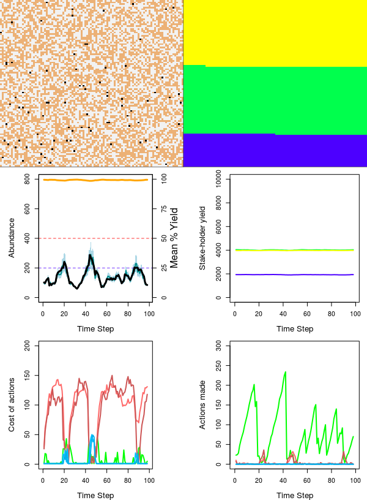

*Output when manager responds to observation model and sets policy, which is then followed by stake-holders*

So in the above example, we have the manager effectively prohibiting killing or castrating resources until about generation 18, when the population gets higher than desired. At this point, the manager switches to allow killing and castrating, and makes moving and helping resources more costly – stake-holders respond to this by doing a bit more killing and castrating, and the population goes down in response.

**Looking good, but still need to clean the code**

The above example is encouraging, but there is still quite a bit of clean-up to do. More unit testing is necessary to make sure that all resources are doing what they should, and I think the interaction between resources and landscape could be made a bit better in the resource model. Also, setting the initial costs and utilities is quite messy – I need to fix this up a bit so that there is at least one easy place to do this in the code, then an easy way to do it as an argument in the `gmse` function. It would also be nice not to have managers or stake-holders be quite so short-sighted – but having decisions be made based on history will require quite a bit more work, though the structure is there for it to be done in the code.

> Update: 12 MAY 2017

**One more debugging in the genetic algorithm**

A bug in the code was causing managers to set their marginal fitneses to zero within the genetic algorithm. The reason for this was that the functions `crossover` and `mutation` allowed for `util`, `u_loc`, and `u_land` columns to be changed when the zero column of the action array was positive – i.e., when the actions corresponded to affecting *other* agents utilities in some way. The reason for this coding is so that agents can potentially affect one anothers utilities (e.g., a stake-holder lobbying the manager), but it does not make sense for stake-holders to affect their own utilities. The bug was caused because when the manager mutated (or crossed over) to change their own utilities in some way, the high cost recognised this as over-budget and set the value to zero, hence replacing the marginal utility set in the manager model. This was easily fixed by not allowing an agent to affect its own utility values (i.e., disallow the utility columns to be changed when the first column of the `ACTION` array equal’s the agent’s own ID). This would have caused an issue later anyway, so it’s better to spot it now. Re-running the model, the bug is fixed and the manager marginal utilities are retained in the appropriate row of `ACTION` (see commit 4dacbe83ed1be0d1216b692a1db18f5323ed22f2).

**Another thing that needs de-bugging**

For some reason, managers are going way overbudget in allocating actions. Fortunately, they’re at least allocating their actions well, but I need to fined out why their budget looks more like 500 when I set it to 100. Note that this **only happens when managers want more of a resource**, not fewer. Perhaps the marginal utility is getting added into the budget? **Yes**, this appears to be the case and has been fixed with commit d60312da590630fc2a680a57b8daed8e6d6bfafd, and now the costs no longer go over the manager’s budget.

**Valgrind summary**

Some initial testing revealed that some memory might have been poorly allocated; allocating space for an `int` instead of a `double` in the genetic algorithm was flagged by `valgrind`. After fixing this (see commit 57d0c78de7e421687870749549d309cf85d31dab), `valgrind` returns no errors or leaks.

```
==8048==
==8048== HEAP SUMMARY:
==8048==     in use at exit: 194,900,716 bytes in 19,004 blocks
==8048==   total heap usage: 12,387,437 allocs, 12,368,433 frees, 2,482,975,628 bytes allocated
==8048==
==8048== LEAK SUMMARY:
==8048==    definitely lost: 0 bytes in 0 blocks
==8048==    indirectly lost: 0 bytes in 0 blocks
==8048==      possibly lost: 0 bytes in 0 blocks
==8048==    still reachable: 194,900,716 bytes in 19,004 blocks
==8048==         suppressed: 0 bytes in 0 blocks
==8048== Reachable blocks (those to which a pointer was found) are not shown.
==8048== To see them, rerun with: --leak-check=full --show-leak-kinds=all
==8048==
==8048== For counts of detected and suppressed errors, rerun with: -v
==8048== ERROR SUMMARY: 0 errors from 0 contexts (suppressed: 0 from 0)
```

I dare say that this might nearly be an [alpha version](https://en.wikipedia.org/wiki/Software_release_life_cycle#Alpha) of the software. I just need to get some more clever ways to input array values, and make sure that I resolve [Issue #22](https://github.com/bradduthie/gmse/issues/22).

**[Issue #24](https://github.com/bradduthie/gmse/issues/24) Resources retain `helpem` and `feedem`**

Resources are retaining their values of `helpem` and `feedem` *after* being helped for one generation. Worse, they are passing their inherited characteristics on to their offspring. This needs to be changed so that agent actions have the **temporary** effect of increasing offspring survival probability or reproduction – else populations will never run the risk of crashing.

> Update: 11 MAY 2017

**Some success with manager fitness function debugging – more testing needed**

After much time working on debugging the manager fitness function, I believe that all of the bugs are worked out of it, and that the managers are now responding dynmically to agent actions and resource abundances. I now need to test the whole function in multiple different ways to confirm this, and to make sure that the manager sets policy as predicted for some very simple scenarios.

- Making killing costly when resource abundance is below what managers want it to be, but stake-holders want to cull.
- Making `helpem` and `feedem` costly when resource abundance is higher than what managers want it to be, but stake-holders want more resources.

One potential issue I’ve already noticed – if managers make stake-holder actions so costly that they never perform them, then the manager might operate under the assumption that they will *never* perform the action even if costs drop. It might therefore be necessary to add an increment to the total actions (e.g., add 10 to each, just to give managers the ability to *consider the possibility*) **or** somehow have managers tie predicted actions to stake-holder utilities (I don’t like this as much – to speculative and computationally intense).

> Update: 10 MAY 2017

**Debugging the manager fitness function in the genetic algorithm**

Today I have spent my time attempting to completely debug the newly created `manager_fitness` function and its sub-functions. Unfortunately, one bug still appears to remain. For some reason, the function adds actions to the `POPULATION` array in the first row. This issue has been isolated, and I’m almost sure that it is caused by something in `manager_fitness`. Tomorrow, the goal is to fix this so that actions are applied correctly where the row’s first column is 1 (the manager `agentID`).

> Update: 9 MAY 2017

**New [Issue #23](https://github.com/bradduthie/gmse/issues/23): Revise predicted consequences of user and manager actions**

In functions in the genetic algorithm `res_to_counts` and `policy_to_counts`, the projected consequences of actions needs to be fine tuned. As of now, it predicts one fewer resource from `movem`, `killem`, and `castem`, and one more resource from `feedem` and `helpem` in `res_to_counts`. In `policy_to_counts`, it predicts one fewer resource for `killem` and one more resource for `feedem` and `helpem`. Really, there should probably at least be an option to use more precise estimates of what will happen. For the user function, this matters a bit less because stake-holders typically just want more or less of a resource. Managers, however, are trying to hit a middle ground a lot of the time; it is also more reasonable to assume that they have demographic information on the resources of interest.

**More writing and re-writing the manager genetic algorithm**

I have completed an initial draft of the manager fitness function `manager_fitness` and its associated sub-functions `policy_to_counts` and `sum_array_layers`. The function `manager_fitness` might need to be pruned a bit by adding a third sub-function, as it’s a bit long at the moment.

```
/* =============================================================================
 * This is a preliminary function that checks the fitness of each agent by
 * passing through a loop to payoffs_to_fitness
 *     fitnesses: Array to order fitnesses of the agents in the population
 *     population: array of the population that is made (malloc needed earlier)
 *     pop_size: The size of the total population (layers to population)
 *     ROWS: Number of rows in the COST and ACTION arrays
 *     agent_array: The agent array
 *     jaco: The jacobian matrix of resource and landscape interactions
 *     interact_table: Lookup table for figuring out rows of jaco and types
 *     interest_num: The number of rows and cols in jac, and rows in lookup
 * ========================================================================== */
void manager_fitness(double *fitnesses, double ***population, int pop_size,
                     int ROWS, double **agent_array, double **jaco,
                     int **interact_table, int interest_num, int agentID,
                     double ***COST, double ***ACTION, int COLS, int layers){

    int agent, i, row, act_type, action_row, manager_row, type1, type2, type3;
    double agent_fitness, *count_change, foc_effect, change_dev, max_dev;
    double movem, castem, killem, feedem, helpem, *dev_from_util;
    double utility, *utils, **merged_acts, **merged_costs, **act_change;

    count_change  = malloc(interest_num * sizeof(int));
    utils         = malloc(interest_num * sizeof(int));
    dev_from_util = malloc(interest_num * sizeof(double));
    merged_acts   = malloc(ROWS * sizeof(double *));
    for(i = 0; i < ROWS; i++){
        merged_acts[i] = malloc(COLS * sizeof(double));
    }
    merged_costs = malloc(ROWS * sizeof(double *));
    for(i = 0; i < ROWS; i++){
        merged_costs[i] = malloc(COLS * sizeof(double));
    }
    act_change = malloc(ROWS * sizeof(double *));
    for(i = 0; i < ROWS; i++){
        act_change[i] = malloc(COLS * sizeof(double));
    }

    sum_array_layers(ACTION, merged_acts, 0, ROWS, COLS, layers);
    sum_array_layers(COST,  merged_costs, 1, ROWS, COLS, layers);

    max_dev = 0;
    for(agent = 0; agent < pop_size; agent++){
        for(action_row = 0; action_row < interest_num; action_row++){
            count_change[action_row] = 0; /* Initialise at zero */
            utils[action_row]        = 0; /* Same for utilities */
            while(population[action_row][0][agent] < -1){
                type1 = population[action_row][1][agent];
                type2 = population[action_row][2][agent];
                type3 = population[action_row][3][agent];
                manager_row = 0;
                while(population[manager_row][0][agent] == agentID &&
                      population[manager_row][1][agent] == type1   &&
                      population[manager_row][2][agent] == type2   &&
                      population[manager_row][3][agent] == type3
                ){
                    manager_row++;
                }
            }
            policy_to_counts(population, merged_acts, agent, merged_costs,
                             act_change, action_row, manager_row, COLS);
            foc_effect  = 0.0;
            foc_effect -= act_change[action_row][9];  /* See Issue #23 */
            foc_effect += act_change[action_row][10];
            foc_effect += act_change[action_row][11];
            for(i = 0; i < interest_num; i++){
                count_change[i] += foc_effect * jaco[action_row][i];
            }
            utils[action_row] = population[manager_row][4][agent];
        }
        for(i = 0; i < interest_num; i++){ /* Minimises dev from marg util*/
            change_dev += (count_change[i]-utils[i])*(count_change[i]-utils[i]);
        }
        if(change_dev > max_dev){
            max_dev = change_dev;
        }
        dev_from_util[agent] = change_dev;
    }

    for(agent = 0; agent < pop_size; agent++){
        fitnesses[agent] = max_dev - dev_from_util[agent];
    }

    for(i = 0; i < ROWS; i++){
        free(act_change[i]);
    }
    free(act_change);
    for(i = 0; i < ROWS; i++){
        free(merged_costs[i]);
    }
    free(merged_costs);
    for(i = 0; i < ROWS; i++){
        free(merged_acts[i]);
    }
    free(merged_acts);
    free(dev_from_util);
    free(utils);
    free(count_change);
}
```

The `policy_to_counts` function feeds new actions back to the main manager fitness function based on the new costs imposed by managers. We assume that new actions are proportional to the percent increase or reduction to costs (e.g., twice as many `killem` actions if the manager makes it cost half as much). I cases where the cost drops to zero (debating whether I want his to be possible – probably not), we assume the new cost is 0.5 and calculate accordingly.

```
/* =============================================================================
 * This function updates a temporary action array for changes in policy
 *     population: The population array of agents in the genetic algorithm
 *     merged_acts: The action 2D array of summed elements across 3D ACTION
 *     agent: The agent (layer) in the population being simulated
 *     merged_costs: The mean cost paid for each element in the ACTION array
 *     act_change: The array of predicted new actions given new costs
 *     action_row: The row where the action and old costs are located
 *     manager_row: The row where the new costs from the manager are located
 *     COLS: The number of columns in the ACTION and COST arrays
 * ========================================================================== */
void policy_to_counts(double ***population, double **merged_acts, int agent,
                      double **merged_costs, double **act_change,
                      int action_row, int manager_row, int COLS){

    int col;
    double old_cost, new_cost, cost_change, new_action;

    for(col = 0; col < COLS; col++){
        old_cost    = merged_costs[action_row][col];
        new_cost    = population[manager_row][col][agent];
        if(new_cost == 0){
            new_cost = 0.5; /* Need to avoid Inf increase in cost somehow */
        }
        cost_change = old_cost / new_cost;
        new_action  = merged_acts[action_row][col] * cost_change;
        act_change[action_row][col] = floor(new_action);
    }
}
```

The function `sum_array_layers` is basically an [apply](https://www.r-bloggers.com/the-r-apply-function-a-tutorial-with-examples/) function in R, except that it only works with the `COST` or `ACTION` arrays, and only in one dimension.

```
/* =============================================================================
 * This function sums (or averages) a row of COST or ACTION across all layers
 *    array: The 3D array that is meant to be summed or averaged
 *    out: The 2D array where the summed/average values are to be stored
 *    get_mean: TRUE (1) or FALSE (0) indiciating whether to get mean vs sum
 *    ROWS: Number of rows in array
 *    COLS: Number of cols in array
 *    total_layers: How many layers there are in array (depth)
 * ========================================================================== */
void sum_array_layers(double ***array, double **out, int get_mean, int ROWS,
                      int COLS, int layers){

    int row, col, layer;

    for(row = 0; row < ROWS; row++){
        for(col = 0; col < COLS; col++){
            if(get_mean == 1){
                for(layer = 0; layer < layers; layer++){
                    out[row][col] += (array[row][col][layer] / layers);
                }
            }else{
                for(layer = 0; layer < layers; layer++){
                    out[row][col] += array[row][col][layer];
                }
            }
        }
    }
}
```

I have not tested any of these functions at all. They almost certainly contain some bugs at the moment, so a lot of work is going to need to debugging them and making sure that they actually are doing what I want them to do. Tomorrow might be a good time for a thorough debugging and memory leak checks. If all this works though, managers should be able to dynamically change costs in response to stake-holders to manage resources – once the appropriate call from `manager.c` is in place (it hasn’t been coded yet, but this should be trivial to write). **Note that** the git history immediately prior to commit 79446e394133bb9e6b4792d334ab863e32ef0881 will show some attempts at getting the above functions working in different ways. I settled on the above after restructuring the code considerably for both speed and readability.

> Update: 8 MAY 2017

Linking manager marginal utilities and manager actions remains difficult, but I have decided on the following plan to move forward.

It will be useful to develop a very simple criteria for assessing the fitness of adjusting costs in `strategy_fitness` in `game.c`. Do this in the `switch` function where `case 1:`, but include an `if` statement to make sure that `if(act_type == agentID)`, then the genetic algorithm knows that it’s affecting all other user actions in the `-2` row. A **new function** `policy_to_counts` will be created in `game.c` which takes in the `ACTION` and `COST` arrays. This new function will assume two things.

1. The *proportion* of `+`, `-`, and `0` actions (from the perspective of a stake-holder) will not change – i.e., stake-holders will try to achieve the same ends in the next time step as they did in the previous time step. The `movem` column will be defined as `-` if `util_loc = 1` and `util_land = 1`, else it will be defined as `0` (again, from the stake-holder perspective, from the manager’s perspective this is always `0` – at least, I can’t think of any reason why we would want it not to be zero.
2. Stake-holders will invest in whatever `+`, `-`, or `0` action is least costly. Hence to loosely predict stake-holder actions, the manager could simply assume that the stake-holder invests a proportion of their total budget to the least costly action, and based on the manager’s set cost, puts their budget into those actions accordingly. Hence, if we had a farmer that wanted to increase crop yield by reducing resource abundance, and had to choose between `movem`, `killem`, and `castem` with costs of 10, 2, and 5, respectively, then the farmer would put all of their budget into `killem` (or a high proportion, at least). This requires the manager (whose actions are already set within the genetic algorithm) to get a proportion for each of the stake-holders actions, then divy their actions out based on the revised costs.

**The initial plan: getting something to work**

Let’s try all of the above again. **We’re trying to get from cost adjustments to fitness.** We *have* the cost adjustments in hand; the manager population in the genetic algorithm is in the process of selecting which of these adjustments are best. The difficultly is now translating the cost adjustments to stake-holder actions, and figuring out just how *good* we want managers to be at assessing stake-holder actions. One extreme is to run the genetic algorithm in each *within* the manger’s decision making to figure out how stake-holders will respond to policy change with a high degree of acurracy; this would take a massive amount of computation time and be a bit unrealistic in that it would kind of assume that managers can read the minds of stake-holders.

Another extreme is to assume the sum total of each action will not change and to adjust costs accordingly. Perhaps, to start, we could define a new array within the new function `policy_to_counts`, `**sum_actions`, which would sum up all stake-holder actions for each resource type.

| agent | type1 | type2 | type3 | util | u_loc | u_land | movem | castem | killem | feedem | helpem | bankem |
| --- | --- | --- | --- | --- | --- | --- | --- | --- | --- | --- | --- | --- |
| -2 | 1 | 0 | 0 | 10 | 10 | 10 | 32 | 2 | 16 | 0 | 0 | 0 |
| -2 | 2 | 0 | 0 | 301 | 10 | 10 | 4 | 1 | 0 | 0 | 1 | 1 |

The hypothetical `sum_actions` array above adds up all of the rows in the `ACTION` array where column 1 equals -2. For each resource we then get a picture of what is going to happen in the next generation (to some extent it is unrealistic to assume that managers have even this much detailed information, but then again, these are actions from the previous time step, so it’s perhaps not too much of a stretch to assume that the manager has some idea of what actions were taken by stake-holders). We also get a picture of the sum utilities for each resource type. **To project the consequences of manager cost adjustment**, managers can compute the proportion change in cost (which will require to read the `COST` array into the fitness function) and assume that the proportion of actions changes accordingly. For example, if the manager makes it half as costly to `killem` for resource `type1 = 1` above, then they could assume that `killem` will be 32 total actions in the *next* generation. These sum total actions, adjusted by manager changes in costs, could then be run through the interaction array to project the change in resource abundance – fitness could be assessed by minimising the the difference between the projected change in resources from the marginal utilities.

This isn’t perfect prediction. Sometimes stake-holders will probably radically change behaviour after some cost threshold is met, but I think this is kind okay (at the very least, managers will respond in the *next* generation).

**Other ideas**

I will start coding the above plan, but there are probably other reasonable options to consider. I would like to also add the option of enacting policy via a second resource – representing resources as something like hunting licenses. The effects of these licenses could be understood through the interaction matrix (essentially, they’d be like introducing a predator, but one that goes through stake-holders). The manager could set the number of hunting licenses using the `feedem` (increases birth rate by action number) and `castem` (causes one fewer so resource doesn’t reproduce) columns (licenses would otherwise have a birthrate and death rate of one, so each replaces itself in the next generation) – birth type would also need to be changed to not be selected from a random Poisson. The `bankem` column could be interpreted as buying a license, somehow.

**Implementation of the initial plan**

This was somewhat difficult because of the way that marginal utilities are handled in the `manager.c` file. A new vector needed to grab the correct utilities and actions for adjusting costs and it was easier and more readable to just write a separate `manager_fitness` function (it can still be called by non-managers, though I’m struggling to think of when this would be desirable). The `manager_fitness` function is unfinished.

```
/* =============================================================================
 * This is a preliminary function that checks the fitness of each agent by
 * passing through a loop to payoffs_to_fitness
 *     fitnesses: Array to order fitnesses of the agents in the population
 *     population: array of the population that is made (malloc needed earlier)
 *     pop_size: The size of the total population (layers to population)
 *     ROWS: Number of rows in the COST and ACTION arrays
 *     agent_array: The agent array
 *     jaco: The jacobian matrix of resource and landscape interactions
 *     interact_table: Lookup table for figuring out rows of jaco and types
 *     interest_num: The number of rows and cols in jac, and rows in lookup
 * ========================================================================== */
void manager_fitness(double *fitnesses, double ***population, int pop_size,
                     int ROWS, double **agent_array, double **jaco,
                     int **interact_table, int interest_num, int agentID){

    int agent, i, row, act_type, action_row, manager_row, type1, type2, type3;
    double agent_fitness, *count_change, foc_effect, change_dev;
    double movem, castem, killem, feedem, helpem;
    double utility, *utilities;

    count_change = malloc(interest_num * sizeof(int));
    utilities    = malloc(interest_num * sizeof(int));

    for(agent = 0; agent < pop_size; agent++){
        for(i = 0; i < interest_num; i++){
            count_change[i] = 0; /* Initialise all count changes at zero */
            utilities[i]    = 0; /* Same for utilities */
        }
        action_row  = 0;
        while(population[action_row][0][agent] < -1){
            type1 = population[action_row][1][agent];
            type2 = population[action_row][2][agent];
            type3 = population[action_row][3][agent];
            manager_row = 0;
            while(population[manager_row][0][agent] == agentID &&
                  population[manager_row][1][agent] == type1   &&
                  population[manager_row][2][agent] == type2   &&
                  population[manager_row][3][agent] == type3
            ){
                manager_row++;
            }
        }

        /* Get the marginal utilities into utilities by running policy_to_counts
         * and get the count_change the same way. The above runs thorugh this
         * for each agent and for each resource Here still within the agent loop
         * we need to get the vectors summed appropriately to a reasonable
         * fitness metric (keeping in mind that it's not just ordinal
         */


        fitnesses[agent] = 0;
        for(i = 0; i < interest_num; i++){ /* Minimises dev from marg util*/
            change_dev       =  (count_change[i] - utilities[i]) *
                                (count_change[i] - utilities[i]) + 1;
            fitnesses[agent] += (1 / change_dev);
        }
    }
    free(utilities);
    free(count_change);
}
```

Likewise, a sub-function that `manager_fitness` will call also needs some work.

```
/* =============================================================================
 * This function updates count change and utility arrays for changes in policy
 *     population: The population array of agents in the genetic algorithm
 *     interact_table: The lookup table for figuring out how resources interact
 *     int_num: The number of rows and cols in jac, and rows in the lookup
 *     utilities: A vector of the utilities of each resource/landscape level
 *     agent: The agent in the population whose fitness is being assessed
 *     layers: The number of layers (z dimension) in the COST and ACTION arrays
 *     COST: The cost array, for comparison with how costs change with actions
 *     ACTION: The action array to summarise current stake-holder actions
 *     agentID: The ID of the agent doing policy (should probably always be 1)
 * ========================================================================== */
void policy_to_counts(double ***population, int **interact_table, int int_num,
                      double *utilities, int agent, int layers, double **jaco,
                      double *count_change, double ***COST, double ***ACTION,
                      int agentID, int ROWS, int action_row, int manager_row){

    int row, col, layer, act_type, i, type1, type2, type3, cost_row;
    double old_cost, new_cost, cost_change, new_action, mean_cost, sum_actions;
    double **mean_costs, *hold_actions;


    hold_actions = malloc(13 * sizeof(double));

    for(i = 0; i < 13; i++){
        hold_actions[i] = population[action_row][i][agent];
    }

    for(col = 7; col < 13; col++){
        sum_actions = 0;
        mean_cost   = 0;
        for(layer = 0; layer < layers; layer++){
            sum_actions += ACTION[action_row][col][layer];
            mean_cost   += (COST[action_row][col][layer] / layers);
        }
        old_cost    = mean_cost;
        new_cost    = population[manager_row][col][agent];
        cost_change = old_cost / new_cost;
        new_action  = sum_actions * cost_change;
        population[action_row][col][agent] = floor(new_action);
    }

    res_to_counts(population, interact_table, int_num, count_change, utilities,
                  jaco, action_row, agent);

    for(i = 0; i < 13; i++){
        population[action_row][i][agent] = hold_actions[i];
    }

    free(hold_actions);
}
```

The history of struggling with these two functions in a way that is accurate, readable, and efficient is in the git history. I’ll consider both functions with fresh eyes tomorrow with the goal of getting something working.

> Update: 5 MAY 2017

We have now reached a point where we have a clear link from manager *utility* to a manager’s desired change in resources. The `util` column of a manager (layer = 1) action array defines how many resources of a particular type the manager *wants* there to be when column 1 equals -2 (added below for clarity).

```
-2.000000   1.000000    0.000000    0.000000    100.000000  1.000000    1.000000
-1.000000   1.000000    0.000000    0.000000    1.000000    1.000000    1.000000
1.000000    1.000000    0.000000    0.000000    -330.696014 0.000000    0.000000
2.000000    1.000000    0.000000    0.000000    0.000000    0.000000    0.000000
3.000000    1.000000    0.000000    0.000000    0.000000    0.000000    0.000000
```

From this `util` value and the estimated abundance from the observation model, we can get to the marginal utility, which is placed in the same action array layer where column 1 equals the manager ID. We now need this value to have some effect; e.g., in the above where the population size is 330 individuals more than the manager wants, the manager needs to adjust the cost array in some way that has the predicted effect of lowering population size by roughly this amount. The way that the genetic algorithm can learn to do this is by assuming that the action array (which will have been the actions run in the last `user` model) represents what stake-holders will do when constrained appropriately by costs. So, for example, we can consider the `ACTION` array below.

```
, , 1

     [,1] [,2] [,3] [,4] [,5] [,6] [,7] [,8] [,9] [,10] [,11] [,12] [,13]
[1,]   -2    1    0    0  100    1    1    0    0     0     0    20     0
[2,]   -1    1    0    0    1    1    1    0    0     1     0     0     0
[3,]    1    1    0    0    0    0    0    0    0     0     0     0     1
[4,]    2    1    0    0    0    0    0    0    1     1     0     0     0
[5,]    3    1    0    0    0    0    0    0    0     0     0     0     0

, , 2

     [,1] [,2] [,3] [,4] [,5] [,6] [,7] [,8] [,9] [,10] [,11] [,12] [,13]
[1,]   -2    1    0    0    1    1    1   81    0     0     0     0     0
[2,]   -1    1    0    0  100    1    1    0    0     0     0     0     0
[3,]    1    1    0    0    0    0    0    0    0     0     0     0     0
[4,]    2    1    0    0    0    0    0    0    0     0     0     0     0
[5,]    3    1    0    0    0    0    0    0    0     0     0     0     0

, , 3

     [,1] [,2] [,3] [,4] [,5] [,6] [,7] [,8] [,9] [,10] [,11] [,12] [,13]
[1,]   -2    1    0    0    1    1    1   72    2     0     0     0     1
[2,]   -1    1    0    0  100    1    1    1    0     0     0     0     0
[3,]    1    1    0    0    0    0    0    0    1     0     0     0     0
[4,]    2    1    0    0    0    0    0    0    0     0     1     0     0
[5,]    3    1    0    0    0    0    0    0    0     1     0     0     0
```

The first layer is the manager, and the second two are stake-holders that have `util = 100` for the landscape layer 1, and `util = 1` for the resource defined by `type1 = 1`, `type2 = 0`, and `type3 = 0`. In the above example, the resource might be geese disturbing crops, and the stake-holders might be farmers. In both cases, the stake-holders devote nearly all or nearly all of their budget to moving the resource (column 8 corresopnds to `movem`). The manager can then project total number of resources increased or decreased by these actions, and – perhaps eventually – whose land they will be on (the code is there for the manager to prefer them on public or private land, but this might need to be implemented later). Assuming that the manager just cares about total resource abundance for now, the should be able to recognise that `movem` will *not* decrease *total* resource abundance; hence, the manager might prefer stake-holders to switch to `killem` (column 10).

It’s this switch that is a challenge for the model. It’s easy now to have the manager recognise that stake-holder actions are not optimal in terms of policy – more actions are being devoted to something that doesn’t kill resources, and more would be better placed by increasing stake-holder column 10 values. Still, how much the manager should lower costs to get the desired abundance is unclear (and even more so if we were to add multiple resources). The manager can’t exactly use the stake-holder utilities for the resource *per se* either, because the actions are determined by how resources interact; we also don’t want to run a sub-genetic algorithm for the manager to anticipate stake-holder actions, as this would end up being computationally intense.

Perhaps the manager should simply recognise the plus-minus-neutral effects of each column (from columns 8-13 above, `0 - - + + 0`). This gets part of the way there; if the manager wants resources killed, then they could crank up the costs associated with all `0` and `+` actions (perhaps this shouldn’t be allowed though for `bankem`, which would effectively prohibit stake-holders from inaction). The magnitude of costs for `-` actions such as `killem` or `castem` could then be decided by assuming that stake-holders would transfer `-` and `0` (again, exclude `bankem`) to the lowest column of `-` if the cost were the lowest.

Maybe managers should make a judgement *a priori* about what stake-holders are trying to do; classifying them as either wanting more or less of a particular resource. Wanting less of a resource would be associated with high values in action columns for `killem` and `castem`, and also `movem` but *only* if `u_loc = 1` and `u_land = 1` for the stakeholder (i.e., if the desires and ability to move them depends on the resource being on *their* land). Wanting more of a resource would be associated with high values in action columns for `feedem` and `helpem`. The manager could then assume that stake-holders would allocate their total budget actions proportionally to `-`, `+`, or `0` columns, but without discrimination between columns. It could be easy to summarise budget and action totals as in the table below.

| Action type | *Total budget* |
| --- | --- |
| Increasing | 500 |
| Decreasing | 200 |
| Neutral | 300 |

In the above, a net 300 more resources would appear if the manager does nothing (ignoring the resource model and consequences of carrying capacity for the moment). **Note that the actions should really be run through the interaction array** so that interactions between two resources could be hypothetically projected. This wouldn’t be much extra work – the increase in a resource could just be multiplied by the appropriate column in the Jacobian matrix. **Also note** that costs are only one way to adjust resources – another would be having something like licenses to kill be a resource that stake-holders might want to buy – the manager could make more of these and they could themselves be modelled as a dynamic and affecting the Jacobian matrix.

> Update: 4 MAY 2017

**Manager model looped resources and mark-recapture**

The density estimate within the manager model `manager.c` now returns accurate abundances for multiple resources (storing them in a vector `est_abun`). This was confirmed by shutting off the `user` function (see [Issue: #22](https://github.com/bradduthie/gmse/issues/22)).

Additionally, the mark-recapture estimator has been successfully initialised in `manager.c`, and works for multiple resources. There was a bit of a hiccup here because the test printouts of abundances were consistently different from what was seen in the R plot. This turned out to be a minor error in R, not C (one too many columns were being read in in R to estimate resources marked). By fixing the error in R, both R and C estimates now match and are accurate. The next step is to return estmates for transect-based sampling abundances.

The mark-recapture analysis uses Chapman estimation, which is calculated in two functions. The function `rmr_est` runs calls `chapman_est` for each individual resource, inputting the results into the `abun_est` vector.

```
/* =============================================================================
 * This function calculates mark-recapture-based (Chapman) abundance estimates
 *     obs_array:      The observation array
 *     para:           A vector of parameters needed to handle the obs_array
 *     obs_array_rows: Number of rows in the observation array obs_array
 *     obs_array_cols: Number of cols in the observation array obs_array
 *     abun_est:       Vector where abundance estimates for each type are placed
 *     interact_table: Lookup table to get all types of resource values
 *     int_table_rows: The number of rows in the interact_table
 *     trait_number:   The number of traits in the resouce array
 * ========================================================================== */
void rmr_est(double **obs_array, double *para, int obs_array_rows,
             int obs_array_cols, double *abun_est, int **interact_table,
             int int_table_rows, int trait_number){

    int resource, type1, type2, type3;
    double estimate;

    for(resource = 0; resource < int_table_rows; resource++){
        abun_est[resource] = 0;
        if(interact_table[resource][0] == 0){ /* Change when turn off type? */
            type1    = interact_table[resource][1];
            type2    = interact_table[resource][2];
            type3    = interact_table[resource][3];
            estimate = chapman_est(obs_array, para, obs_array_rows,
                                   obs_array_cols, trait_number, type1, type2,
                                   type3);
            abun_est[resource] = estimate;
        }
    }
}
```

The function `chapman_est` itself does all of the maths for estimating population abundance from mark-recapture data in the `OBSERVATION` ARRAY.

```
/* =============================================================================
 * This function calculates RMR (chapman) for one resource type
 *     obs_array:      The observation array
 *     para:           A vector of parameters needed to handle the obs_array
 *     obs_array_rows: Number of rows in the observation array obs_array
 *     obs_array_cols: Number of cols in the observation array obs_array
 *     trait_number:   The number of traits in the resource array
 *     type1:          Resource type 1
 *     type2:          Resource type 2
 *     type3:          Resource type 3
 * ========================================================================== */
double chapman_est(double **obs_array, double *para, int obs_array_rows,
                   int obs_array_cols, int trait_number, int type1, int type2,
                   int type3){

    int row, col;
    int total_marks, recaptures, mark_start, recapture_start;
    int *marked, sum_marked, n, K, k;
    double estimate, floored_est;

    total_marks     = (int) para[11];
    recaptures      = (int) para[10];
    mark_start      = trait_number + 1;
    recapture_start = mark_start + (total_marks - recaptures);

    if(total_marks < 2 || recaptures < 1){
        printf("ERROR: Not enough marks or recaptures for management");
        return 0;
    }

    n      = 0;
    marked = malloc(obs_array_rows * sizeof(int));
    for(row = 0; row < obs_array_rows; row++){
        marked[row] = 0;
        if(obs_array[row][1] == type1 &&
           obs_array[row][2] == type2 &&
           obs_array[row][3] == type3
        ){
            for(col = mark_start; col < recapture_start; col++){
                if(obs_array[row][col] > 0){
                    marked[row] = 1;
                    n++;
                    break;
                }
            }
        }
    }

    K = 0;
    k = 0;
    for(row = 0; row < obs_array_rows; row++){
        if(obs_array[row][1] == type1 &&
           obs_array[row][2] == type2 &&
           obs_array[row][3] == type3
        ){
            for(col = recapture_start; col < obs_array_cols; col++){
                if(obs_array[row][col] > 0){
                    K++;
                    if(marked[row] > 0){
                        k++;
                    }
                    break;
                }
            }
        }
    }

    estimate    = ((n + 1) * (K + 1) / (k + 1)) - 1;
    floored_est = floor(estimate);

    free(marked);

    return floored_est;
}
```

No confidence intervals are calculated at the moment, since I’m not sure how the simulated manager would use the uncertaintly, but if we eventually want real people to be able to ‘play’ the game as managers, then it shouldn’t be too difficult to add confidence intervals to all population size estimates within the C functions of `manager.c`.

**Transect estimation of resource abundances**

Manager estimation of abundances collected from transect type sampling (i.e., `case 2` and `case 3`) are considerably easier than density-based and mark-recapture matrics. The times a resource is observed is simply stored in the 12th column (in C; 13 in R) of the observation matrix. The `transect_est` does the job for any number of resources all in one go.

```
/* =============================================================================
 * This function calculates mark-recapture-based (Chapman) abundance estimates
 *     obs_array:      The observation array
 *     para:           A vector of parameters needed to handle the obs_array
 *     obs_array_rows: Number of rows in the observation array obs_array
 *     abun_est:       Vector where abundance estimates for each type are placed
 *     interact_table: Lookup table to get all types of resource values
 *     int_table_rows: The number of rows in the interact_table
 * ========================================================================== */
void transect_est(double **obs_array, double *para, int obs_array_rows,
                  double *abun_est, int **interact_table, int int_table_rows){

    int resource, observation, type1, type2, type3;

    for(resource = 0; resource < int_table_rows; resource++){
        abun_est[resource] = 0;
        if(interact_table[resource][0] == 0){ /* Change when turn off type? */
            type1    = interact_table[resource][1];
            type2    = interact_table[resource][2];
            type3    = interact_table[resource][3];
            for(observation = 0; observation < obs_array_rows; observation++){
                if(obs_array[observation][1] == type1 &&
                   obs_array[observation][2] == type2 &&
                   obs_array[observation][3] == type3
                ){
                    abun_est[resource] += obs_array[observation][12];
                }

            }
        }
    }
}
```

Abundances need to now be compared to manager utilities (and for now, I’m just going to assume that the agent with `agentID = 1` is the head manager (other `type1 = 0` agents can be ‘managers’ collecting data, but I don’t see how or why we would want multiple managers bargaining over resources with different `util` values; not yet at least, and probably not ever).

**Getting marginal utilities for management and putting them in `ACTION`**

Back to the big picture, I have now finished the first five (easiest) of the tasks below.

```
/* 1. Get summary statistics for resources from the observation array     */
/* 2. Place estimated resource abundances in a vector the size of int_d0  */
/* 3. Initialise new vector of size int_d0 with temp utilities of manager */
/* 4. Subtract abundances from temp utilities to get marginal utilities   */
/* 5. Insert the marginal utilities into the agent = 1 col1 of ACTION     */
/* 6. Run the genetic algorithm (add extension to interpet cost effects)  */
/* 7. Put in place the new ACTION array from 6                            */
/* 8. Adjust the COST array appropriately from the new manager actions    */
```

Essentially, the `manager.c` function now gets estimates for the abundances of each resource, then places those estimates in a temporary vector. Elements in this vector (corresponding to resource abundances) are then subtracted from the manager’s utility values (corresponding to *desired* resource counts). What’s left is then the marginal utility of resources – if there are more resources than the manager desires, then the marginal utility is negative, and if there are fewer, then the marginal utility is positive. The marginal utility is then placed back into the first layer of the `ACTION` array (corresponding to the manager) where column 1 equals 1 (i.e., intepreted as actions of the manager affecting their own costs – existing values of which aren’t really being used because the concept doesn’t make a lot of sense, and the values are really just there as place-holders for where they mean things in other layers of the array). Hence the `util` column then includes values for the ideal resource abundance (where column 1 equals -2 – `util` is in column 5) and the marginal utility given estimated resource abundance (where column 1 equals 1). See below.

```
-2.000000   1.000000    0.000000    0.000000    100.000000  1.000000    1.000000
-1.000000   1.000000    0.000000    0.000000    1.000000    1.000000    1.000000
1.000000    1.000000    0.000000    0.000000    -330.696014 0.000000    0.000000
2.000000    1.000000    0.000000    0.000000    0.000000    0.000000    0.000000
3.000000    1.000000    0.000000    0.000000    0.000000    0.000000    0.000000
```

In the above, the manager sees 100 as the ideal population size, but there are ca 430 resources of `type1 = 1`, `type2 = 0`, `type3 = 0` in the population. Hence the manager would like to see ca 330 *fewer* of these kinds of resources. The `-330.696014` printed from a test simulation above will allow the genetic algorithm to adjust the `COST` array accordingly, decreasing `COST` columns that correspond to the killing or castrating (but not moving, I suppose) of resources.

> Update: 3 MAY 2017

**Resolved [Issue: #20](https://github.com/bradduthie/gmse/issues/20)**

[Issue: #20](https://github.com/bradduthie/gmse/issues/20) has now been resolved. The `res_type` has now been removed from the observation model, and observations simply occur for all unique resource types – if some are not needed, then they are not analysed. Doing this required very little modification for transect type sampling (`case 2` and `case 3`), but considerably more for density base sampling (`case 0`) and especially mark and recapture (`case 1`). In these cases, I decided to split the sampling functions up more clearly. Testing revealed some initial errors, but these were ironed out and fixed. Currently, the correct `OBSERVATION` array is returned, although this array is not analysed correctly when plotting in R for more than one resource (the code for this has not yet be written).

**NOTE: there is no code written to ignore subdivisions yet. I’m not sure whether or not we’ll actually want this, but the option could simply be something placed in `para` and checked in the subfunctions in `observation.c`**

**Major changes to `observation.c`**

In resolving [Issue: #20](https://github.com/bradduthie/gmse/issues/20), I have re-worked the code in `observation.c` to be more readable. instead of the `switch(methods)` in the main observation function calling density based estimation or mark-recapture, but *both* of these functions, confusingly, calling the same `mark_res` sub-function, I now have `mark_res` being called for density based estimation. Hence, each method of observation has its own (considerably smaller) sub-function, each of which calls another sub-function. For example, with density-based estimation, we have the following function called `times_obs` times.

```
/* =============================================================================
 * Density method of estimation
 * ===========================================================================*/
/* =============================================================================
 * This simulates the capture-mark-recapture of a resource type
 * Inputs include:
 *     resource_array: data frame of resources to be marked and/or recaptured
 *     agent_array: data frame of agents, potentially doing the marking
 *     land: The landscape on which interactions occur
 *     paras: vector of parameter values
 *     res_rows: Total number of resources that can be sampled
 *     a_row: Total number agents that could possibly sample
 *     obs_col: The number of columns in the observational array
 *     a_type: The type of agent that is doing the marking
 *     by_type: The type column that is being used
 *     find_type: The type of finding that observers do (view-based or rand)
 * Output:
 *     Accumlated markings of resources by agents
 * ========================================================================== */
void mark_res(double **resource_array, double **agent_array, double ***land,
              double *paras, int res_rows, int a_row, int obs_col, int a_type,
              int by_type, int find_type){

    int resource;
    int agent;
    int count;
    int edge;        /* How does edge work? (Effects agent vision & movement) */
    int samp_res;    /* A randomly sampled resource */
    int ldx, ldy;
    int move_t;
    int sample_num;   /* Times resources observed during one time step */

    edge       = (int) paras[1];  /* What type of edge is on the landscape */
    sample_num = (int) paras[11];
    ldx        = (int) paras[12]; /* dimensions of landscape -- x and y */
    ldy        = (int) paras[13];
    move_t     = (int) paras[14]; /* Type of movement being used  */

    for(agent = 0; agent < a_row; agent++){
        if(agent_array[agent][by_type] == a_type){
            mark_in_view(resource_array, agent_array, paras, res_rows, agent,
                         find_type, obs_col);
        }
        if(sample_num > 1){
            a_mover(agent_array, 4, 5, 6, edge, agent, land, ldx, ldy, move_t);
        }
    }
}
```

The above function calls `mark_in_view`, which marks all resources in the agent’s view (regardless of type, which will get sorted out later).

```
/* =============================================================================
 * This simulates an individual agent doing some field work (observing)
 * Inputs include:
 *     resource_array: data frame of resources to be marked and/or recaptured
 *     agent_array: data frame of agents, potentially doing the marking
 *     paras: vector of parameter values
 *     res_rows: Total number of rows in the res_adding data frame
 *     worker: The row of the agent that is doing the working
 *     find_proc: The procedure used for finding and marking resources
 *     res_type: The type of resources being marked
 *     obs_col: The number of columns in the observation array
 * Output:
 *     The resource_array is marked by a particular agent
 * ========================================================================== */
void mark_in_view(double **resource_array, double **agent_array, double *paras,
                  int res_rows, int worker, int find_proc, int obs_col){

    int xloc;         /* x location of the agent doing work */
    int yloc;         /* y location of the agent doing work */
    int view;         /* The 'view' (sampling range) around agent's location */
    int edge;         /* What type of edge is being used in the simulation */
    int resource;     /* Index for resource array */
    int r_x;          /* x location of a resource */
    int r_y;          /* y location of a resource */
    int seeme;        /* Test if observer sees/captures the resource */
    int ldx;          /* Landscape dimension on the x-axis */
    int ldy;          /* Landscape dimension on the y-axis */
    int EucD;         /* Is vision based on Euclidean distance? */
    double min_age;   /* Minimum at which sampling can occur */

    xloc  = (int) agent_array[worker][4];
    yloc  = (int) agent_array[worker][5];
    view  = (int) agent_array[worker][8];
    edge  = (int) paras[1];
    ldx   = (int) paras[12];
    ldy   = (int) paras[13];
    EucD  = (int) paras[20];

    min_age = paras[16];

    for(resource = 0; resource < res_rows; resource++){
        if(resource_array[resource][11] >= min_age){
            r_x   = resource_array[resource][4];
            r_y   = resource_array[resource][5];
            seeme = binos(xloc, yloc, r_x, r_y, edge, view, ldx, ldy, EucD);
            agent_array[worker][10]           += seeme;
            resource_array[resource][obs_col] += seeme;
            resource_array[resource][12]      += seeme;
        }
    }
}
```

The mark-recapture technique, in contrast, calls the new function `sample_fixed_res` once (`time_obs` is taken care of in the sub-function).

```
/* =============================================================================
 * Mark re-capture method of estimation
 * ===========================================================================*/
/* =============================================================================
 * This simulates the capture-mark-recapture of a resource type
 * Inputs include:
 *     resource_array: data frame of resources to be marked and/or recaptured
 *     agent_array: data frame of agents, potentially doing the marking
 *     land: The landscape on which interactions occur
 *     paras: vector of parameter values
 *     lookup: The table listing resources and landscape layers to lookup
 *     res_rows: Total number of resources that can be sampled
 *     agent_number: Total number of agents in the agent array
 *     a_type: The type of agent that is doing the marking
 *     trait_number: The number of traits (columns) of the resource array
 *     lookup_rows: The number of rows in the lookup table
 * Output:
 *     Accumlated markings of resources by agents
 * ========================================================================== */
void sample_fixed_res(double **resource_array, double **agent_array,
                      double ***land, double *paras, int **lookup, int res_rows,
                      int agent_number, int a_type, int trait_number,
                      int lookup_rows){

    int edge_type, move_type, fixed_sample, times_obs, move_res, by_type;
    int land_x, land_y;
    int obs_iter, agent;
    int row, type1, type2, type3;

    edge_type    = (int) paras[1];
    move_type    = (int) paras[2];
    fixed_sample = (int) paras[10];
    land_x       = (int) paras[12];
    land_y       = (int) paras[13];
    by_type      = (int) paras[17];
    move_res     = (int) paras[19];

    if(fixed_sample < 1){
        printf("ERROR: Fixed sample must be >= 1 \n ... Making = 1 \n");
        paras[10]    = 1;
        fixed_sample = 1;
    }


    for(row = 0; row < lookup_rows; row++){
        if(lookup[row][0] == 0){
            obs_iter     = trait_number + 1;
            times_obs    = (int) paras[11];

            type1 = lookup[row][1];
            type2 = lookup[row][2];
            type3 = lookup[row][3];
            while(times_obs > 0){
                for(agent = 0; agent < agent_number; agent++){
                    if(agent_array[agent][by_type] == a_type){
                        mark_fixed(resource_array, agent_array, paras, res_rows,
                                   agent, obs_iter, type1, type2, type3);
                    }
                }
                obs_iter++;
                times_obs--;
                if(move_res == 1){ /* Move resources if need for new sample */
                    res_mover(resource_array, 4, 5, 6, res_rows, edge_type,
                              land, land_x, land_y, move_type);
                }
            }
        }
    }
}
```

The sub-function `mark_fixed` marks a fixed number of a specific type of resource.

```
/* =============================================================================
 * This simulates an individual agent marking a fixed number of resources
 * Inputs include:
 *     resource_array: data frame of resources to be marked and/or recaptured
 *     agent_array: data frame of agents, potentially doing the marking
 *     paras: vector of parameter values
 *     res_rows: Total number of rows in the res_adding data frame
 *     worker: The row of the agent that is doing the working
 *     obs_col: The number of columns in the observation array
 *     type1: Resource type 1 being marked
 *     type2: Resource type 2 being marked
 *     type3: Resource type 3 being marked
 * Output:
 *     Specific resources in resource_array are marked by a particular agent
 * ========================================================================== */
void mark_fixed(double **resource_array, double **agent_array, double *paras,
                int res_rows, int worker, int obs_col, int type1, int type2,
                int type3){

    int xloc;         /* x location of the agent doing work */
    int yloc;         /* y location of the agent doing work */
    int view;         /* The 'view' (sampling range) around agent's location */
    int edge;         /* What type of edge is being used in the simulation */
    int resource;     /* Index for resource array */
    int r_x;          /* x location of a resource */
    int r_y;          /* y location of a resource */
    int seeme;        /* Test if observer sees/captures the resource */
    int ldx;          /* Landscape dimension on the x-axis */
    int ldy;          /* Landscape dimension on the y-axis */
    int fixn;         /* If procedure is to sample a fixed number; how many? */
    int count;        /* Index for sampling a fixed number of resource */
    int sampled;      /* The resource randomly sampled */
    int type_num;     /* Number of the type of resource to be fixed sampled */
    int EucD;         /* Is vision based on Euclidean distance? */
    double sampl;     /* Random uniform sampling of a resource */
    double min_age;   /* Minimum at which sampling can occur */

    xloc  = (int) agent_array[worker][4];
    yloc  = (int) agent_array[worker][5];
    view  = (int) agent_array[worker][8];
    edge  = (int) paras[1];
    ldx   = (int) paras[12];
    ldy   = (int) paras[13];
    EucD  = (int) paras[20];

    min_age = (int) paras[16];

    fixn     = (int) paras[10];
    type_num = 0;
    for(resource = 0; resource < res_rows; resource++){
        if(resource_array[resource][1]  == type1 &&
           resource_array[resource][2]  == type2 &&
           resource_array[resource][3]  == type3 &&
           resource_array[resource][11] >= min_age
        ){
            type_num++;
        }
    }
    if(type_num > fixn){ /* If more resources than the sample number */
        /* Temp tallies are used here to sample without replacement */
        for(resource = 0; resource < res_rows; resource++){
            if(resource_array[resource][1]  == type1 &&
               resource_array[resource][2]  == type2 &&
               resource_array[resource][3]  == type3
            ){
                resource_array[resource][13] = 0; /* Start untallied */
            }
        }
        count = fixn;
        sampl = 0;
        while(count > 0){
            do{ /* Find an un-tallied resource in the array */
                 sampl   = runif(0, 1) * res_rows;
                 sampled = (int) sampl;
              } while(resource_array[sampled][13] == 1         ||
                      resource_array[sampled][1]  != type1     ||
                      resource_array[sampled][2]  != type2     ||
                      resource_array[sampled][3]  != type3     ||
                      resource_array[sampled][11] <  min_age   ||
                      sampled == res_rows /* In case sample returns 1 */
                );
            resource_array[sampled][obs_col]++; /* Marks accumulate  */
            resource_array[sampled][12]++;
            resource_array[sampled][13] = 1;    /* Tally is noted    */
            count--;
        }
        agent_array[worker][10] += fixn;
    }else{ /* Else all of the resources should be marked */
        for(resource = 0; resource < res_rows; resource++){
            if(resource_array[resource][1]  == type1 &&
               resource_array[resource][2]  == type2 &&
               resource_array[resource][3]  == type3 &&
               resource_array[resource][11] >= min_age
            ){
               resource_array[resource][obs_col]++;  /* Mark all */
               resource_array[resource][12]++;
             }
        }
        agent_array[worker][10] += type_num; /* All resources marked */
   }
}
```

This still isn’t the most readable code, but it’s better than what it was before. Eventually, I would prefer to get rid of as man of the function arguments as possible and place these as elements within `para`. The identities of `para` elements could then be explained in the function more clearly (and consistently). This would lead to less bulky functions and a bit clearer structure for the code, but I think it can be implemented later as the code is given a more general clean-up.

**[Issue: #22](https://github.com/bradduthie/gmse/issues/22) User function crashes with multiple resources**

For some reason, the `user.c` call appears to crash when there is more than one resource. I only noticed this after the overhaul of the observation model, but I doubt they are related. More likely, one of the many arrays with dimensions that depend on resource number is being built or called improperly, leading to a segmentation fault. This should be fixed, of course, but I suspect the problem is not too far buried.

**Next steps still to get abundance estimate from observation array in `manager.c`**

The above issues were progress, but it has set back the pace of the manager model a bit. The next item on the agenda is to still get individual abundance estimates within for each unique resource type in the manager model. The density estimate is completed, and the whole thing should work because the code is already written to loop through the interaction table and get abundance estimates for each unique resource. **This should be tested by including more than one resource and turning off the user function** (see [Issue: #22](https://github.com/bradduthie/gmse/issues/22)). Once it works, then I need to do the same thing for mark-recapture and transect-based estimates of abundance. Then, I’ll try to get through items 2-5 from the list on the list from Monday.

> Update: 2 MAY 2017

**[Issue: #20](https://github.com/bradduthie/gmse/issues/20) Remove `res_type` from observation model**

Currently, the observation model only records resources into the observation array if they are of a particular `type1`, which is specified in the `para` vector and used to produce a data array with only one type of specified resource. Originally, this seemed like a good idea, but after spending some initial time writing the management model, I don’t think there is any need nor good reason to restrict observation to a specific resource type. Instead, all types should be marked and moved to the observation array. Then, if management analysis wants statistics for only one type of resource, its very easy to use an `if` statement to check that the type is appropriate. It’s much easier to ignore parts of the array than to make more than one array when needed through multiple calls of the observation function.

To fix this, it shouldn’t be much more than a simple removal of specifying `res_type` values in `observation.c`. When there is only one resource type, all calculations should proceed normally, but when more resources are introduced, an `if` is needed for both management and plotting (different groups of resources could even be made, ignoring subdivisions, by skipping the `if` if the type specified to look at equals `-1`.

**[Issue: #21](https://github.com/bradduthie/gmse/issues/21) Improve code readability using `para`**

Originally, I had the idea to use the global vector `para` as a way of storing information easily and using it across all of the models. The vector `para` would store key information about pretty much everything, then be dynamically updated as need be from higher level functions in the model. In the last two months of coding, I have been specifying parameter names in functions explicitly, which has made sense during the coding process for my own writing, but it will be beneficial to clean all of this up later by reading `para` into these sub-functions that otherwise have sometimes about a dozen arguments. Most functions would then have considerably fewer arguments, and the **description** of variables stored as vector elements in `para` could be immediately defined within sub-functions and used by name thereafter. The whole program would then have a similar feel of reading in key arrays and vectors and then specifying the key variables within sub-functions.

**1. Get summary statistics for resources from the observation array**

I have now written the functions for `case 0` (density-based estimation) getting abundance estimates from the `observation` array, as outlined yesterday. This took slightly longer than anticipated because it turns out that there was a minor error in R’s estimation of abundances due to an incorrect column being summed. I had to figure out why C and R did not agree on the same abundance estimates; they now do (i.e., both independent codings to get the same estimate from the same observation array). I now need to do the other three types of observation and get abundance estimates from it. In the highest level function for this part of the manager model, the `estimate_abundances` function is called.

```
/* =============================================================================
 * This function uses the observation array to estimate resource abundances
 *     obs_array:      The observation array
 *     para:           A vector of parameters needed to handle the obs_array
 *     interact_table: Lookup table to get all types of resource values
 *     agent_array:    Agent array, including managers (agent type 0)
 *     agents:         Total number of agents (rows) in the agents array
 *     obs_x:          Number of rows in the observation array
 *     obs_y:          Number of cols in the observation array
 *     abun_est:       Vector where abundance estimates for each type are placed
 *     int_table_rows: The number of rows in the interact_table
 * ========================================================================== */
void estimate_abundances(double **obs_array, double *para, int **interact_table,
                         double **agent_array, int agents, int obs_x, int obs_y,
                         double *abun_est, int int_table_rows){

    int estimate_type, recaptures;
    double abun;

    estimate_type = (int) para[8];

    switch(estimate_type){
        case 0:
            dens_est(obs_array, para, agent_array, agents, obs_x, obs_y,
                     abun_est, interact_table, int_table_rows);
            break;
        case 1:
            recaptures    = (int) para[10];
            break;
        case 2:
            break;
        case 3:
            break;
        default:
            break;
    }
}
```

The above function will call subfunctions based on estimate type (0 to 3). Now only the density function `dens_est` has been written and tested.

```
/* =============================================================================
 * This function calculates density-based abundance estimates
 *     obs_array:      The observation array
 *     para:           A vector of parameters needed to handle the obs_array
 *     agent_array:    Agent array, including managers (agent type 0)
 *     agents:         Total number of agents (rows) in the agents array
 *     obs_array_rows: Number of rows in the observation array obs_array
 *     obs_array_cols: Number of cols in the observation array obs_array
 *     abun_est:       Vector where abundance estimates for each type are placed
 *     interact_table: Lookup table to get all types of resource values
 *     int_table_rows: The number of rows in the interact_table
 * ========================================================================== */
void dens_est(double **obs_array, double *para, double **agent_array,
              int agents, int obs_array_rows, int obs_array_cols,
              double *abun_est, int **interact_table, int int_table_rows){

    int i, j, resource;
    int view, a_type, land_x, land_y, type1, type2, type3;
    int vision, area, cells, times_obs, tot_obs;
    double prop_obs, estimate;

    a_type    = (int) para[7];  /* What type of agent does the observing  */
    times_obs = (int) para[11];
    land_x    = (int) para[12];
    land_y    = (int) para[13];

    view = 0;
    for(i = 0; i < agents; i++){
        if(agent_array[i][1] == a_type){
            view += agent_array[i][8];
        }
    }

    vision  = (2 * view) + 1;
    area    = vision * vision * times_obs;
    cells   = land_x * land_y; /* Plus one needed for zero index */
    tot_obs = 0;

    for(resource = 0; resource < int_table_rows; resource++){
        abun_est[resource] = 0;
        if(interact_table[resource][0] == 0){ /* Change when turn off type? */
            type1   = interact_table[resource][1];
            type2   = interact_table[resource][2];
            type3   = interact_table[resource][3];
            tot_obs = res_obs(obs_array, obs_array_rows, obs_array_cols, type1,
                              type2, type3);
            prop_obs = (double) tot_obs / area;
            estimate = prop_obs * cells;

            abun_est[resource] = estimate;
        }
    }
}
```

The `dens_est` function above calls the `res_obs` function, which returns the number of observations for a specific resource type.

```
/* =============================================================================
 * This function calculates density-based abundance estimates
 *     obs_array:  The observation array
 *     obs_rows:   Number of rows in the observation array obs_array
 *     obs_cols:   Number of cols in the observation array obs_array
 *     type1:      Resources of type 1 being observed
 *     type2:      Resources of type 2 being observed
 *     type3:      Resources of type 3 being observed
 * ========================================================================== */
int res_obs(double **obs_array, int obs_rows, int obs_cols, int type1,
            int type2, int type3){

    int i, j, obs_count;

    obs_count = 0;

    for(i = 0; i < obs_rows; i++){
        if( (obs_array[i][1] == type1 || obs_array[i][1] < 0) &&
            (obs_array[i][2] == type2 || obs_array[i][2] < 0) &&
            (obs_array[i][3] == type3 || obs_array[i][3] < 0)
        ){
            for(j = 15; j < obs_cols; j++){
                obs_count += obs_array[i][j];
            }
        }
    }
    return obs_count;
}
```

The point of the above break-down, aside from making things more readable, is that we might want to get abundance estimates for each resource type – at least have G-MSE produce them even if we pretend that managers cannot see them. When [Issue: #20](https://github.com/bradduthie/gmse/issues/20) is resolved, all resources will then be estimated. **NOTE: This could be an issue because if a fixed number of resource types are sampled, as with mark-recapture, then it could sample *different* resources. It might be best to change mark-recapture so that it takes a `fixed_obs` for each unique resource type, somehow.** The point is that it’s easier and more computationally efficient to ignore some data (and not allow managers to notice it) than it is to have to run `observation` multiple times to re-collect using the same protocol.

Eventually, I also want the `obs_array[i][1, 2, or 3]` to be able to take -1 as a value in here somehow – basically, I want the counts to be taken to *ignore one of a resource’s type*. For example, we could imagine wanting to have separate sexes indicated by `type2 = 0` or `type2 = 1` in column 2 of the `obs_array`, but perhaps not want managers to actually *use* this when estimating abundance (alternatively – could combine observations later).

> Update: 1 MAY 2017

**Manager function to genetic algorithm link**

There is a minor conceptual issue regarding the implementation of the genetic algorithm with the manager function. The manager’s actions need to be based on the `OBSERVATION` array, but stake-holders need not use this information. There are two options for implementing the genetic algorithm regarding observations.

1. The `OBSERVATION` array could just be read into the genetic algorithm and not used for stake-holders. This might require the `user` function to be initially called *after* the `manager` function so that an `OBSERVATION` array exists (or a dummy could be made easily enough in the `user.R` function.
2. Manager utilites could be manipulated within the manager funciton *before* going into the genetic algorithm. This could have its own benefits. The point would be for managers to have some sort of absolute utility for resources, but for this utility to be adjusted before reading the manager’s `ACTION` and `COST` arrays into the genetic algirthm to zero in on the actions. For example, if there are too many resources, then the `util` could be adjusted within `manager.c` (or `manager.R`) to be negative, hence making the genetic algorithm select strategies that lower costs on `killem` actions proportional to how many the manager wants killed.

I think that option 2 is actually a bit faster, and will probably be easier to implement in terms of coding.

**Isolating effects of uncertainty**

It is worth pointing out in passing that above option 2 offers a very straight-forward way of looking at uncertainty with respect to management decisions. When passing resource abundances to update temporary `util` values for managers, we could compare the estimates of abundances produced from the observation model to the *actual* abundances from the resource model. This could be a very simple option in the software, and **it might be useful to run the genetic algorithm twice for managers in each time step** to simulate side-by-side how decisions would be made in the presence and absence of uncertainty.

**Initialising the manger model**

To get the ball rolling on the manager function’s implementation of the genetic algorithm, now is as good of a time as any to initialise `manager.R` and `manager.c`, since the arguments passed to `game.c` need to be coaxed into the right form via the manager model. It’s important to keep in mind that **I still need to implement the lobbying option for stake-holders**, but I think that this will be easier once the manager’s genetic algorithm is built. It’s also notworthy that we’re probably not going to need managers to adjust stake-holder’s utilities. So really, in a pinch, their are three types of actions that are really going to be important, probably always.

1. Stake-holders actions affect resoure and landscape properties (done)
2. Stake-holders actions affect manager utilities
3. Manager actions affect stake-holder costs of performing actions

To this list of three essential types of actions, there are a few additional actions that would be good to have, ideally as fitting within the general framework of the model seemlessely, but if necessary could be add-ons for future development.

4. Managers actions affect resource and landscape properties (effectively done)
5. Stake-holders affect the costs of one another
6. Stake-holders affect the utilities of one another

To this, there are a few more other possible options that I can’t, at the moment, see why anyone would want to model. I’m not entirely sure these are really sensical, actually.

7. Stake-holders affect the costs of managers’ actions (on resources or *other* stake-holders costs)
8. Managers affecting stake-holder utilities

**Framework for manager actions**

The framework for manager actions in both R and C is now entirely built – data structures can be read in and out, so now all that is left is to do the modelling. I’ve commented what will happen within `manager.c`; each of the numbers below might or might not represent uniqe sub-functions.

```
/* Do the biology here now */
/* ====================================================================== */

/* 1. Get summary statistics for resources from the observation array     */
/* 2. Place estimated resource abundances in a vector the size of int_d0  */
/* 3. Initialise new vector of size int_d0 with temp utilities of manager */
/* 4. Subtract abundances from temp utilities to get marginal utilities   */
/* 5. Insert the marginal utilities into the agent = 1 col1 of ACTION     */
/* 6. Run the genetic algorithm (add extension to interpet cost effects)  */
/* 7. Put in place the new ACTION array from 6                            */
/* 8. Adjust the COST array appropriately from the new manager actions    */

/* This code switches from C back to R */
/* ====================================================================== */
```

With all of these in place, the end result should be a new `COST` array based on manager actions. It will be important to make sure that the *manager’s* costs are defined appropriately so that the manager doesn’t start doing actions themselves. This could actually be a bit of a problem; if we want the manager to do things themselves, then it’s hard to see why they wouldn’t just perform the actions instead of adjusting the costs. Then again, perhaps this is kind of the point? Maybe sufficiently high costs of actions and sufficiently low costs of *policy* adjustment should cause the genetic algorithm to naturally find policy as a better means of acheiving what the manager wants. In fact, this seems almost certain; if managers in the real world could achieve all policy aims single-handedly, then that’s what they would probably be hired to do. In the real world, changing policy is more effective – it’s also possible that we could allow them to do their own direct actions to resources in the `user` model, like the stake-holders. Costs of setting policy could then be independent from costs of doing actions by changing manager `COST` between models.

> Update: 28 APR 2017

**Concrete plan for manager fitness function**

The next step in the coding is to allow managers to generate policy by using their utilities to affect the costs of other agents. This will require that managers recognise how the actions of other agents will affect resources and the landscape, then adjust costs to encourage agents to act in a particular way. There are several things to keep in mind here.

- Policy really should be universal; there should be a default setting, therefore, that constrains the manager to affect costs in the same way for all agents (this could be removed, or perhaps relaxed to allow the manager to treat different agent types differently). This could be something as simple as giving the manager ideal values for each action, then seeing if the total actions are above or below those values. Costs could then be adjusted accordingly, somehow linking cost value to an expected action (this might be a simple one to one, actually).
- The manager should have their own budget, but it probably shouldn’t take too much cost to change policy – at least not at first. THe `bankem` column could be used to suck up actions in the genetic algorithm if doing nothing is advantageous..
- A problem could be if we want managers to be able to implement policy themselves and also set policy by adjusting other agent’s costs. The issue here is that these two things wouldn’t seem to interact cost-wise. That is, it doesn’t seem like setting a policy against culling (by moving up the cost of `killem`) should stop managers from feeding resources on public land. Maybe it does, but it doesn’t seem like it should have to be this way.

**Some solutions to account for the above**

Given that the manager already has a special status in the rest of G-MSE, maybe it’s not too much of a stretch to make their cost-adjusting actions apply to all non-managers by default by making all cost-adjusting rows in the `ACTION` array (on the manager’s layer) equivalent. **Or, even better**, the first row, which corresponds to the manager’s own costs (or any agent’s *own* cost row, since the cost of adjusting their own cost doesn’t really come into play – or really make much sense), could simply define the cost of affecting **all** stake-holders cost values.

| agent | type1 | type2 | type3 | util | u_loc | u_land | movem | castem | killem | feedem | helpem | bankem |
| --- | --- | --- | --- | --- | --- | --- | --- | --- | --- | --- | --- | --- |
| -2 | 1 | 0 | 0 | 101 | 101 | 101 | 3 | 8 | 4 | 4 | 2 | 1 |
| -2 | 2 | 0 | 0 | 101 | 101 | 101 | 4 | 3 | 6 | 2 | 3 | 1 |
| -1 | 1 | 0 | 0 | 101 | 101 | 101 | 101 | 101 | 101 | 101 | 101 | 101 |
| 1 | 1 | 0 | 0 | 101 | 101 | 101 | 101 | 101 | 101 | 101 | 101 | 101 |
| 1 | 2 | 0 | 0 | 101 | 101 | 101 | 101 | 101 | 101 | 101 | 101 | 101 |
| 2 | 1 | 0 | 0 | 101 | 101 | 101 | 101 | 101 | 101 | 101 | 101 | 101 |
| 2 | 2 | 0 | 0 | 101 | 101 | 101 | 101 | 101 | 101 | 101 | 101 | 101 |
| 3 | 1 | 0 | 0 | 101 | 101 | 101 | 101 | 101 | 101 | 101 | 101 | 101 |
| 3 | 2 | 0 | 0 | 101 | 101 | 101 | 101 | 101 | 101 | 101 | 101 | 101 |

Assume that the above `COST` array layer corresponds to the manager: `agent = 1`. In the above `COST` array, we have three agents (`agent = 1` is a manager, while `agent = 2` and `agent = 3` are stake-holders), two resource types, and one landscape layer. So in rows 4 and 5 above where the first column `agent = 1`, we have, essentially, costs of what it takes to affect the entire array of stake-holders actions (all layers where `agent = -2` or `agent = -1`) on a particular resource. This value can then be used to directly implement actions in the first two rows of all layers of the `ACTION` array. **Note** that the structure of the code does not allow managers to make policy on landscape use – only resources, which might or might not have to be changed. What we’re essentially saying with this is that a manager cannot tell a farmer to not kill or fertilise crops on the farmer’s own land. Only resources are affected by manager policy (we could, of course, make crops resources – though this would be a bit of a time consuming work around). We could find a way around this if need be, but I can’t think of many situations in which we would want a manager to be able to tell a stake-holder that they can’t increase their own crop yield or kill their crops.

**[Issue #19](https://github.com/bradduthie/gmse/issues/19): Cost and Action arrays: landscape level initialisation**

The number of landscape layers in the `COST` and `ACTION` arrays is too many – the `utility_layer` adds one in for every unique resource instead of for every unique landscape layer. This is an easy fix by adding an option to the function to specify landscape layers.

**More concrete ideas**

A general algorithm-sketch for the managers could be as follows in the *fitness function* of the genetic algorithm. **Note** that this will be called in the manager model, not the user model, so there isn’t a worry about the stake-holders updating their actions at the wrong time – their actions will be static while the manager is considering what to do.

1. Identify the current abundances of all resources based on an analysis of the observation model.
2. Identify the ideal abundances for management, identified from the agent’s layer of the `ACTION` array, column `util`.
3. Calculate the updated resource abundances predicted from the `ACTION` matrix of stake-holders (e.g., from all rows where `agent = -2`). Hence, resources will be decreased by some columns and increased by others based on the *past* actions of stake-holders. This *might or might not* also need to include resource abundance projections based on birth and death rates – ideally this would be the case, with projections using estimates from the observation model, but maybe just use the abundances as a first step? *Note*, the ‘projected’ birth rate need not use the `RESOURCE` array explicitly, but could be estmated and applied from the history of observation – in fact, this would probably be better.
4. Apply new costs to all users – have managers assume that higher costs means that actions will decrease proportionally, and lower costs will mean that actions will increase proportionally. It could potentially get more complex than this, but I don’t think that it needs to at the moment; stake-holders will usually be wanting to maximise *something* rather than balancing between many things, and even if not, costs should still constrain their decisions in line with the direct that the manager is trying to push – the point isn’t to optimise decisions, but to replicate the common sense and expertise of a manager that does not have complete access to other stake-holders minds.
5. Given the new actions, re-calculate updated resource abundances from 3 to assign fitness.

The algorithm above should be fairly fast, and while it won’t provide the *optimal* solution for managers, it isn’t actually intended to do so. The point is to find an adaptive strategy based on the tools available to the manager and the limited information that the manager realistically has about resource abundacnes and stake-holder strategies. Following from the above, I dare say that the fitness function for stake-holders affecting manager’s `util` might be not too difficult, but I’ll need to think carefully about the best way to implement it.

> Update: 26 APR 2017

**Resolved [issue #12](https://github.com/bradduthie/gmse/issues/12)**

I have finally resolved [issue #12](https://github.com/bradduthie/gmse/issues/12), which was always a bit annoying but never terribly serious. The problem was that density-based estimation as done in Nuno et al. (2013) would only plot correctly when `times_observe = 1`; that is, when managers went out to observe a sample of the population exactly once per time step. Obviously we want the option to allow multiple trips to sample in a single time step, as sampling once (unless the number of cells viewed on the landscape include almost the entire landscape) leads to highly variable results – and even more so now that resource distributions tend to become clumped on the landscape when agents scare them off their land. Previously the proportion estimate used the number of *unique* resources observed, but what we really needed was the *unique observations*. By simply summing all values in columns `16` to `16 + times_observed - 1` of the observation array, we get the total number of observations.

**Quick note about agents affecting each other’s costs**

It’s worth noting that there is no need to save any additional data structure to have agents affect each others costs – at least not at the moment. This is because the user and manager models are separated in a broader time. When a manager uses the genetic algorithm, the `ACTION` array that they have to use has already been updated for stake-holders, so the managers are effectively *seeing* the most recent actions of stake-holders and will be able to adjust costs and use the recent actions to predict changes (can perhaps assume proportional allocation of actions, so if the manager makes one action more costly, then the stake-holder will shift to increase other actions – or perhaps this is too much to predict; maybe managers should just assume that increasing cost will decrease an action as if the action isolated. How strategic do we assume managers think?). Likewise, stake-holders are *seeing* the managers most recent priorities and might lobby them accordingly.

> Update: 25 APR 2017

**Resolved [issue #18](https://github.com/bradduthie/gmse/issues/18)**

The landscape actions within the user model are now affected by the interaction matrix from the appropriate diagonal element. This effectively adjust the effect of a user’s actions to increase a cell value by some magnitude. For example, if an agent wants to increase their crop yield they will not do so by the current cell yield plus one times whatever the appropriate element is in the interaction matrix (default could be one – doubling yield). Initial testing shows that this works as intended; stake-holders interested in maximising crop yield do so reliably when they can increase yield on a cell twenty-fold; mean crop yield on the whole landscape increases in turn. When the increase is smaller (50%), then a range of strategies appears possible – one stake-holder chose to kill resources while the other chose to directly increase yield (dependent on costs, which varied among stake-holders). Next, the plan is to address some of the minor clean-up tasks (bulleted list from yesterday) before getting to the ultimate goal of allowing agents to affect one another’s costs in the genetic algorithm.

**Resolved [issue #11](https://github.com/bradduthie/gmse/issues/11)**

I appear to have resolved [issue #11](https://github.com/bradduthie/gmse/issues/11) by calling the `a_mover` function in `observation.c` from within the `anecdotal` function. This gives the option to move agents when the R function `anecdotal` is called during a time step. Later I might also consider giving the option to specify moving agents onto land that they own; this would probably be best accomplished by calling `send_agents_home`, which is currently in `user.c`, but could be moved to `utilities.c`. Tests of `anecdotal` in R confirm that it is moving agents as expected.

> Update: 24 APR 2017

I have begun to implement actions on the landscape as an option. For now, these actions will include increasing crop yield directly in some way (magnitude to be affected by the interaction array, see below), and killing crops.

**New issue #18: Make landscape actions from interaction array**

It will be helpful to link the appropriate element of the interaction array (Jacobian matrix) to the actions in the `landscape_actions` function in `user.c`. As of now, the amount of increase in crop yield (and decrease) is hard-coded in the function, but it really should be linked with the appropriate diagonal element in the interaction array – increasing or decreasing a cell’s value by the magnitude in the array element.

**More testing, success**

More testing shows that the genetic algorithm and user function is working as intendend, and I have looped the genetic algorithm so that it is run for all simulated agents with now issues – even when landscape dimensions or agent number changes. There are, however, some minor things that need to be tweaked.

- The colours in the plot indicating land ownership (upper left panel) and individual stake-holder yield (lower right panel) do not match up when one or more agents do not own land. This is an easy fix, but it will take a bit of time to do it.
- The order of user actions might be something to keep in mind – as of now this simply loops, but it is possible now for one agent to kick resources off their land only to have those resources immiediately kicked back by their neighbour. At the very least, the order of agent actions (at least those of stake-holders) should probably be randomised.
- The `observe_type = 0` still isn’t plotting correctly. I’m not sure why this is, but it seems to produce underestimates of population abundance that are off consisently by half the `times_obs`. It will be a good idea to get this settled, finally.

> Update: 20 APR 2017

The minor bug from yesterday has been resolved. The following bet of code needed to be *within* the larger loop that cycled through the population of agents in the genetic algorithm.

```
for(i = 0; i < interest_num; i++){
    count_change[i] = 0; /* Initialise all count changes at zero */
    utilities[i]    = 0; /* Same for utilities */
}
```

The count changes and utilities were not being initialised at zero, meaning that `count_change` was cumulative over agents. When this is fixed, and agents highly value the resource (`utility = 100`), they either evolve to `feedem` or `helpem` as much as possible, as reflected in the `ACTION` array.

```
     [,1] [,2] [,3] [,4] [,5] [,6] [,7] [,8] [,9] [,10] [,11] [,12] [,13]
[1,]   -2    1    0    0  100    1    1    0    0     0    92     0     0
[2,]   -1    1    0    0    1    1    1    0    0     0     0     0     0
[3,]    1    1    0    0    0    0    0    0    0     0     0     0     0
[4,]    2    1    0    0    0    0    0    0    0     0     0     1     0
```

So with this *very* simplified test, the function is doing what it is supposed to do. Next, I fixed the utility of the *landscape* to 100 to see if the agent recognises that it can increase crop yield by killing or scaring the resource via the interaction array.

**Test of killing resource to maximise crop yield**

```
     [,1] [,2] [,3] [,4] [,5] [,6] [,7] [,8] [,9] [,10] [,11] [,12] [,13]
[1,]   -2    1    0    0    1    1    1   94    0     0     0     0     0
[2,]   -1    1    0    0  100    1    1    0    0     0     0     0     0
[3,]    1    1    0    0    0    0    0    0    0     0     0     0     0
[4,]    2    1    0    0    0    0    0    0    0     0     0     0     1
```

```
/* =============================================================================
 * This is a preliminary function that checks the fitness of each agent by
 * passing through a loop to payoffs_to_fitness
 *     fitnesses: Array to order fitnesses of the agents in the population
 *     population: array of the population that is made (malloc needed earlier)
 *     pop_size: The size of the total population (layers to population)
 *     ROWS: Number of rows in the COST and ACTION arrays
 *     COLS: Number of columns in the COST and ACTION arrays
 *     agent_array: The agent array
 *     jaco: The jacobian matrix of resource and landscape interactions
 *     interact_table: Lookup table for figuring out rows of jaco and types
 *     interest_num: The number of rows and cols in jac, and rows in lookup
 * ========================================================================== */
void strategy_fitness(double *fitnesses, double ***population, int pop_size,
                      int ROWS, int COLS, double **agent_array, double **jaco,
                      int **interact_table, int interest_num){

    int agent, i, row, act_type, type1, type2, type3, interest_row;
    double agent_fitness, *count_change, foc_effect;
    double movem, castem, killem, feedem, helpem;
    double utility, *utilities;

    count_change = malloc(interest_num * sizeof(int));
    utilities    = malloc(interest_num * sizeof(int));

    for(agent = 0; agent < pop_size; agent++){
        for(i = 0; i < interest_num; i++){
            count_change[i] = 0; /* Initialise all count changes at zero */
            utilities[i]    = 0; /* Same for utilities */
        }
        for(row = 0; row < ROWS; row++){
            foc_effect = 0;
            act_type   = (int) population[row][0][agent];
            type1      = population[row][1][agent];
            type2      = population[row][2][agent];
            type3      = population[row][3][agent];
            utility    = population[row][4][agent];
            movem      = population[row][7][agent];
            castem     = population[row][8][agent];
            killem     = population[row][9][agent];
            feedem     = population[row][10][agent];
            helpem     = population[row][11][agent];
            switch(act_type){
                case -2:
                    foc_effect -= movem;  /* Times birth to account for repr? */
                    foc_effect -= castem; /* But only remove E offspring? */
                    foc_effect -= killem; /* But also remove E offspring? */
                    foc_effect += feedem; /* But should less mortality */
                    foc_effect += helpem; /* But should affect offspring? */
                    interest_row = 0;
                    while(interest_row < interest_num){
                        if(interact_table[interest_row][0] == 0     &&
                           interact_table[interest_row][1] == type1 &&
                           interact_table[interest_row][2] == type2 &&
                           interact_table[interest_row][3] == type3
                        ){
                            break;
                        }else{
                            interest_row++;
                        }
                    }
                    for(i = 0; i < interest_num; i++){
                        count_change[i] += foc_effect * jaco[interest_row][i];
                    }
                    utilities[interest_row] = utility;
                case -1:
                    interest_row = 0;
                    while(interest_row < interest_num){
                        if(interact_table[interest_row][0] == 1     &&
                           interact_table[interest_row][1] == type1 &&
                           interact_table[interest_row][2] == type2 &&
                           interact_table[interest_row][3] == type3
                        ){
                            break;
                        }else{
                            interest_row++;
                        }
                    }
                    utilities[interest_row] = utility;
                    break; /* Add landscape effects here */
                default:
                    break;
            }
        }
        fitnesses[agent] = 0;
        for(i = 0; i < interest_num; i++){
            fitnesses[agent] += count_change[i] * utilities[i];
        }
    }
    free(utilities);
    free(count_change);
}
```

The above can be greatly simplified and made clearer, with the goal towards simple fitness functions for the case in which agents directly affect resources or crops. The indirect interactions will be sub-functions in the above called in the `switch` where `case` is greater than zero.

**Breaking down the `strategy_fitness` function**

I’ve broken down the `strategy_fitness` function into three more manageable functions that can be further developed as necessary. The `strategy_fitness` function now calls functions thatupdate the `count_change` and `utilities` arrays as a result of direct actions to resources and the landscape.

```
/* =============================================================================
 * This is a preliminary function that checks the fitness of each agent by
 * passing through a loop to payoffs_to_fitness
 *     fitnesses: Array to order fitnesses of the agents in the population
 *     population: array of the population that is made (malloc needed earlier)
 *     pop_size: The size of the total population (layers to population)
 *     ROWS: Number of rows in the COST and ACTION arrays
 *     COLS: Number of columns in the COST and ACTION arrays
 *     agent_array: The agent array
 *     jaco: The jacobian matrix of resource and landscape interactions
 *     interact_table: Lookup table for figuring out rows of jaco and types
 *     interest_num: The number of rows and cols in jac, and rows in lookup
 * ========================================================================== */
void strategy_fitness(double *fitnesses, double ***population, int pop_size,
                      int ROWS, int COLS, double **agent_array, double **jaco,
                      int **interact_table, int interest_num){

    int agent, i, row, act_type, type1, type2, type3, interest_row;
    double agent_fitness, *count_change, foc_effect;
    double movem, castem, killem, feedem, helpem;
    double utility, *utilities;

    count_change = malloc(interest_num * sizeof(int));
    utilities    = malloc(interest_num * sizeof(int));

    for(agent = 0; agent < pop_size; agent++){
        for(i = 0; i < interest_num; i++){
            count_change[i] = 0; /* Initialise all count changes at zero */
            utilities[i]    = 0; /* Same for utilities */
        }
        for(row = 0; row < ROWS; row++){
            act_type   = (int) population[row][0][agent];
            switch(act_type){
                case -2:
                    res_to_counts(population, interact_table, interest_num,
                                  count_change, utilities, jaco, row, agent);
                    break;
                case -1:
                    land_to_counts(population, interact_table, interest_num,
                                   utilities, row, agent);
                    break;
                default:
                    break;
            }
        }
        fitnesses[agent] = 0;
        for(i = 0; i < interest_num; i++){
            fitnesses[agent] += count_change[i] * utilities[i];
        }
    }
    free(utilities);
    free(count_change);
}
```

The `case -2` calls `res_to_counts` below.

```
/* =============================================================================
 * This function updates count change and utility arrays for direct actions on
 * resources
 *     population: The population array of agents in the genetic algorithm
 *     interact_table: The lookup table for figuring out how resources interact
 *     int_num: The number of rows and cols in jac, and rows in the lookup
 *     count_change: A vector of how counts have changed as a result of actions
 *     utilities: A vector of the utilities of each resource/landscape level
 *     jaco: The interaction table itself (i.e., Jacobian matrix)
 *     row: The row of the interaction and lookup table being examined
 *     agent: The agent in the population whose fitness is being assessed
 * ========================================================================== */
void res_to_counts(double ***population, int **interact_table, int int_num,
                   double *count_change, double *utilities, double **jaco,
                   int row, int agent){

    int i, act_type, interest_row;
    double foc_effect;

    foc_effect  = 0.0;
    foc_effect -= population[row][7][agent];  /* Times birth account for repr?*/
    foc_effect -= population[row][8][agent]; /* But only remove E offspring? */
    foc_effect -= population[row][9][agent]; /* But also remove E offspring? */
    foc_effect += population[row][10][agent]; /* But should less mortality */
    foc_effect += population[row][11][agent]; /* But should affect offspring? */
    interest_row = 0;
    while(interest_row < int_num){
        if(interact_table[interest_row][0] == 0                         &&
           interact_table[interest_row][1] == population[row][1][agent] &&
           interact_table[interest_row][2] == population[row][2][agent] &&
           interact_table[interest_row][3] == population[row][3][agent]
          ){
               break;
           }else{
               interest_row++;
        }
    }
    for(i = 0; i < int_num; i++){
        count_change[i] += foc_effect * jaco[interest_row][i];
    }
    utilities[interest_row] = population[row][4][agent];
}
```

And the `case -1` calls `land_to_counts` below.

```
/* =============================================================================
 * This function updates count change and utility arrays for direct actions on
 * a landscape
 *     population: The population array of agents in the genetic algorithm
 *     interact_table: The lookup table for figuring out how resources interact
 *     int_num: The number of rows and cols in jac, and rows in the lookup
 *     utilities: A vector of the utilities of each resource/landscape level
 *     row: The row of the interaction and lookup table being examined
 *     agent: The agent in the population whose fitness is being assessed
 * ========================================================================== */
void land_to_counts(double ***population, int **interact_table, int int_num,
                    double *utilities, int row, int agent){

    int i, act_type, interest_row;
    double foc_effect;

    interest_row = 0;
    while(interest_row < int_num){
        if(interact_table[interest_row][0] == 1     &&
           interact_table[interest_row][1] == population[row][1][agent] &&
           interact_table[interest_row][2] == population[row][2][agent] &&
           interact_table[interest_row][3] == population[row][3][agent]
          ){
               break;
           }else{
               interest_row++;
           }
    }
    utilities[interest_row] = population[row][4][agent];
}
```

For each sub-case, how the population array is interpreted can be specialised. For example, if `castem` doesn’t really mean anything on the landscape, then it can simply be ignored and agents will adapt by not doing it. In this sense, these two sub-functions become easy things to tinker with for translating actions to utilities.

**Version `v0.0.9`: A working genetic algorithm**

I moved the function `do_actions` and its dependency `resource_actions` to the `user.c` file so that the actions of a particular agent could be performed on the *actual* population after the genetic algorithm simulated and selected an adaptive strategy. As a test drive, I simulated the actions of only one stake-holder who is trying to maximise crop yield, and whose only avenue for doing so is getting resources of their land one way or another. The figure below shows the output.

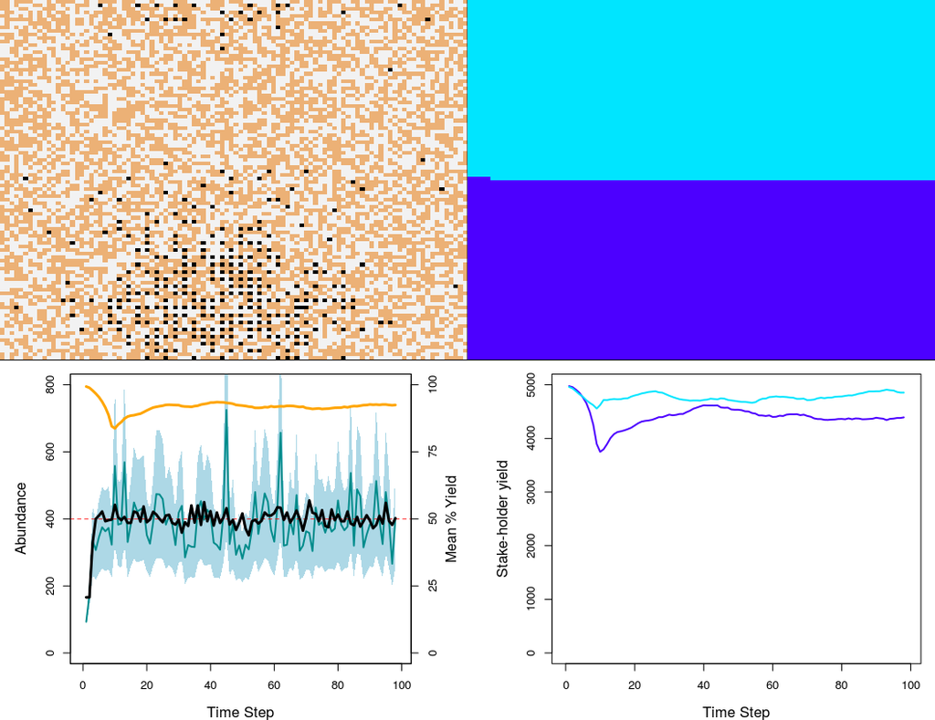

*Output when agents can make some adaptive decisions*

This is exciting – we have a working model in which a genetic algorithm is being used to identify and enact a stake-holders strategy given their specific interests. **The only major conceptual hurdle** now is likely to be the manager’s response, enacting policy by affecting costs of actions, and stake-holders actions that affect other agent’s costs (e.g., lobbying a manager). This isn’t even much of a jump though – really, the framework is in place and a lot of the work from here is just grunt work in terms of coding the specifics what options will be available to what agents. **It shouldn’t be too long before we have a working model of conflict** that can be applied to real-world case studies. Hence, I’m calling this `v0.0.9` and pushing to `master`. This implementation of the genetic algorithm is also not noticably slower than previous versions – it took about a second to run the above; my goal is to keep it low.

The next step will be to figure out what options should be available for directly affecting the landscape, and what needs to be done to apply the genetic algorithm to costs of *other* agents actions (hooks for this are already coded in `switch` functions of the genetic algorithm). I would also like to build the `manager.c` function with the ability to empirically derive the Jacobian matrix, and (eventually) make it possible for agents to consider the *histories* of each others actions (shouldn’t be too much of a stretch, but this is an extension of the genetic algorithm that can come later).

> Update: 19 APR 2017

It’s worth pointing out that the interaction array from yesterday’s `make_interaction_array` function can be defined more generally as a [Jacobian matrix](https://en.wikipedia.org/wiki/Jacobian_matrix_and_determinant). I think it’s worth doing this for the sake of clarity and generality, and thinking about the elements of the array as first order partial derivatives.

**Planning with the Jacobian matrix**

Note that one benefit of individual-based modelling is that each individual can be unique – for example, an individual’s consumption rate of crops does not have to be completely defined by its type; there can be individual variation within types too. Hence, it is probably undesirable to have the Jacobian matrix of type and landscape cell layers *define* how individual interactions should occur. There should be some variation and uncertainty at least as an option. Hence, the interaction array should probably be calculated *a posteriori* as much as possible – ideally from looking at interactions on the landscape (e.g., by the eventual `manager.c`), or perhaps a function should go through the resource and landscape arrays and figure out the average interaction for each data type somewhere within G-MSE (but *not* from within the genetic algorithm; it would take too long). These details can be worked out later in the `manager.c` file, or perhaps somehow with the `anecdotal` function, which I think now can be made more general. **For now**, I’m going to manually set values in the matrix and use them to build an efficient genetic algorithm.

**Dealing with issues of order in the fitness function**

Resource type order needs to be identified for all resource types and landscape layers. The easiest way to do this is to just have a new array that lists all resource and landscape types, such as the below.

| Res | Type 1 | Type 2 | Type 3 |
| --- | --- | --- | --- |
| 1 | 1 | 0 | 0 |
| 1 | 2 | 0 | 0 |
| 0 | 1 | 0 | 0 |

The first column just identifies whether or not the row refers to a resource or a landscape level. The second through fourth columns identify a type (2 and 3 are always zero for landscape levels). This strikes me as the most clear way of keeping track of which rows go with which types in both the Jacobian matrix and the resource array, which I eventually will want to include columns associated with each row, potentially?

The table is initialised with a simple function now in `initialise.R` to be called from the main `gmse.R`.

```r
#' Initialise array of resource and landscape-level interactions
#'
#'@param resources the resource array
#'@param landscape the landscape array
#'@export
make_interaction_table <- function(resources, landscape){

    resource_types      <- unique(resources[,2:4]);
    resource_part       <- matrix(data=0, nrow=dim(resource_types)[1], ncol=4);
    resource_part[,2:4] <- resource_types;

    landscape_count    <- dim(landscape)[3] - 2; # Again, maybe all in later?
    landscape_part     <- matrix(data = 0, nrow = landscape_count, ncol = 4);
    landscape_part[,1] <- 1;
    landscape_part[,2] <- 1:landscape_count;

    the_table <- rbind(resource_part, landscape_part);
}
```

The table, along with the Jacobian matrix, is now passed to the user function and into the genetic algorithm where it can be used by the fitness function.

**A revised fitness function**

A revised fitness function is below, which has **not** passed unit tests because it doesn’t appear to be maximising utility correctly. There is likely one or more minor bugs in the code that need to be fixed, and it would be better anyway to break the below down into a couple smaller functions anyway.

```
/* =============================================================================
 * This is a preliminary function that checks the fitness of each agent by
 * passing through a loop to payoffs_to_fitness
 *     fitnesses: Array to order fitnesses of the agents in the population
 *     population: array of the population that is made (malloc needed earlier)
 *     pop_size: The size of the total population (layers to population)
 *     ROWS: Number of rows in the COST and ACTION arrays
 *     COLS: Number of columns in the COST and ACTION arrays
 *     agent_array: The agent array
 *     jaco: The jacobian matrix of resource and landscape interactions
 *     interact_table: Lookup table for figuring out rows of jaco and types
 *     interest_num: The number of rows and cols in jac, and rows in lookup
 * ========================================================================== */
void strategy_fitness(double *fitnesses, double ***population, int pop_size,
                      int ROWS, int COLS, double **agent_array, double **jaco,
                      int **interact_table, int interest_num){

    int agent, i, row, act_type, type1, type2, type3, interest_row;
    double agent_fitness, *count_change, foc_effect;
    double movem, castem, killem, feedem, helpem;
    double utility, *utilities;

    count_change = malloc(interest_num * sizeof(int));
    utilities    = malloc(interest_num * sizeof(int));

    for(i = 0; i < interest_num; i++){
        count_change[i] = 0; /* Initialise all count changes at zero */
        utilities[i]    = 0; /* Same for utilities */
    }

    for(agent = 0; agent < pop_size; agent++){
        for(row = 0; row < ROWS; row++){
            foc_effect = 0;
            act_type   = (int) population[row][0][agent];
            type1      = population[row][1][agent];
            type2      = population[row][2][agent];
            type3      = population[row][3][agent];
            utility    = population[row][4][agent];
            movem      = population[row][7][agent];
            castem     = population[row][8][agent];
            killem     = population[row][9][agent];
            feedem     = population[row][10][agent];
            helpem     = population[row][11][agent];
            switch(act_type){
                case -2:
                    foc_effect -= movem;  /* Times birth to account for repr? */
                    foc_effect -= castem; /* But only remove E offspring? */
                    foc_effect -= killem; /* But also remove E offspring? */
                    foc_effect += feedem; /* But should less mortality */
                    foc_effect += helpem; /* But should affect offspring? */
                    interest_row = 0;
                    while(interest_row < interest_num){
                        if(interact_table[interest_row][1] == type1 &&
                           interact_table[interest_row][2] == type2 &&
                           interact_table[interest_row][3] == type3
                        ){
                            break;
                        }else{
                            interest_row++;
                        }
                    } /* Found the right row in the look-up table */
                    for(i = 0; i < interest_num; i++){
                        count_change[i] += foc_effect * jaco[interest_row][i];
                    }
                    utilities[interest_row] = utility;
                case -1:
                    break; /* Add landscape effects here */
                default:
                    break;
            }
        }
        fitnesses[agent] = 0;
        for(i = 0; i < interest_num; i++){
            fitnesses[agent] += count_change[i] * utilities[i];
        }

        /* The below will be removed -- once a minor bug is found */
        /* fitnesses[agent] = population[0][12][agent]; */
    }


    free(utilities);
    free(count_change);
}
```

Nevertheless, this is definitely some progress – and the code is still fast. **The next step** is to print output from the above function to track down what is incorrect.

> Update: 18 APR 2017

An additional thought that could be useful for the genetic algorithm is that it might make sense for the `AGENT` array to also include abundances of each resource type and landscape level in columns at the end of the array, the order of which matches the order of the 2D array described yesterday. Something like the former `anecdotal` function could then be used to fill in abundance values as appropriate (e.g., matching resource on the agent’s owned land, or on public land, or nearby to the location of the agent).

**Initialise interaction array**

A new function in R initialises an array of interactions among resource types and landscape layers.

```r
#' Initialise array of resource and landscape-level interactions
#'
#'@param resources the resource array
#'@param landscape the landscape array
#'@export
make_interaction_array <- function(resources, landscape){
    resource_types  <- unique(resources[,2:4]);
    resource_count  <- dim(resource_types)[1];
    landscape_count <- dim(landscape)[3] - 2; # Maybe put all of them in later?
    total_dims      <- resource_count + landscape_count;
    INTERACTIONS    <- matrix(data = 0, nrow = total_dims, ncol = total_dims);

    name_vec <- NULL;
    for(i in 1:dim(resource_types)[1]){
        name_vec <- c( name_vec,
                       paste(resource_types[i,1],
                             resource_types[i,2],
                             resource_types[i,3],
                             sep = "" )
                      );
    }
    name_vec <- c(name_vec, as.character(paste("L",1:landscape_count,sep="")));
    rownames(INTERACTIONS) <- name_vec;
    colnames(INTERACTIONS) <- name_vec;
    return(INTERACTIONS);
}
```

Specific values can be added in outside the `make_interaction_array` function and updated as need be by G-MSE.

> Update: 17 APR 2017

It’s a bit painful, but I’m going to delete some major pieces of code in the genetic algorithm (which will obviously be preserved in version control). The following functions are slowing things down, and given the new approach outlined in option 3 from 13 APR, I’m going to remove them and focus on the `ACTION` array only, assuming that agents act as if their actions *will* yield the intended results.

```
/* =============================================================================
 * This function calculates an individual agent's fitness
 * ========================================================================== */
double calc_agent_fitness(double ***population, int ROWS, int COLS,
                          int landowner, double ***landscape,
                          double **resources, int res_number, int land_x,
                          int land_y, int land_z, int trait_number,
                          double *fitnesses, double *paras){

    int agent, resource, resource_new, trait, row, col, xloc, yloc, zloc;
    int res_on_land, res_nums_added, res_nums_subtracted, res_num_total;
    double *payoff_vector, *payoffs_after_actions, *payoff_change;
    double **TEMP_RESOURCE, **TEMP_ACTION, ***TEMP_LANDSCAPE;
    double **ADD_RESOURCES, **NEW_RESOURCES;
    double a_fitness;

    payoff_vector         = malloc(ROWS * sizeof(double));
    payoffs_after_actions = malloc(ROWS * sizeof(double));
    payoff_change         = malloc(ROWS * sizeof(double));

    /* --- Make tempororary resource, action, and landscape arrays below --- */
    TEMP_RESOURCE    = malloc(res_number * sizeof(double *));
    for(resource = 0; resource < res_number; resource++){
        TEMP_RESOURCE[resource] = malloc(trait_number * sizeof(double));
    }
    for(resource = 0; resource < res_number; resource++){
        for(trait = 0; trait < trait_number; trait++){
            TEMP_RESOURCE[resource][trait] = resources[resource][trait];
        }
    }

    TEMP_ACTION = malloc(res_number * sizeof(double *));
    for(row = 0; row < ROWS; row++){
        TEMP_ACTION[row] = malloc(COLS * sizeof(double));
    }
    for(row = 0; row < ROWS; row++){
        for(col = 0; col < COLS; col++){
            TEMP_ACTION[row][col] = population[row][col][landowner];
        }
    }

    TEMP_LANDSCAPE = malloc(land_x * sizeof(double *));
    for(xloc = 0; xloc < land_x; xloc++){
        TEMP_LANDSCAPE[xloc] = malloc(land_y * sizeof(double *));
        for(yloc = 0; yloc < land_y; yloc++){
            TEMP_LANDSCAPE[xloc][yloc] = malloc(land_z * sizeof(double));
        }
    }
    for(zloc = 0; zloc < land_z; zloc++){
        for(yloc = 0; yloc < land_y; yloc++){
            for(xloc = 0; xloc < land_x; xloc++){
                TEMP_LANDSCAPE[xloc][yloc][zloc] = landscape[xloc][yloc][zloc];
            }
        }
    }

    /* ----------------------------------------------------------- */

    calc_payoffs(TEMP_ACTION, ROWS, landscape, TEMP_RESOURCE, res_number,
                 landowner, land_x, land_y, payoff_vector);

    do_actions(landscape, TEMP_RESOURCE, land_x, land_y, TEMP_ACTION, ROWS,
               landowner, res_number, COLS);

    /* =====  Below re-creates key parts of the resource model ===== */
    project_res_abund(TEMP_RESOURCE, paras, res_number);

    res_nums_added      = 0;
    res_nums_subtracted = 0;
    for(resource = 0; resource < res_number; resource++){
        res_nums_added += TEMP_RESOURCE[resource][10];
        if(TEMP_RESOURCE[resource][8] < 0){
            res_nums_subtracted += 1;
        }
    }

    ADD_RESOURCES = malloc(res_nums_added * sizeof(double *));
    for(resource = 0; resource < res_nums_added; resource++){
        ADD_RESOURCES[resource] = malloc(trait_number * sizeof(double));
    }

    res_place(ADD_RESOURCES, TEMP_RESOURCE, res_nums_added, res_number,
              trait_number, 10, 11);

    res_num_total  = res_number + res_nums_added - res_nums_subtracted;

    NEW_RESOURCES = malloc(res_num_total * sizeof(double *));
    for(resource = 0; resource < res_num_total; resource++){
        NEW_RESOURCES[resource] = malloc(trait_number * sizeof(double));
    }

    resource_new = 0;
    for(resource = 0; resource < res_number; resource++){
        if(TEMP_RESOURCE[resource][8] >= 0){
            for(trait=0; trait < trait_number; trait++){
                NEW_RESOURCES[resource_new][trait] =
                    TEMP_RESOURCE[resource][trait];
            }
            resource_new++;
        }
    }
    for(resource = 0; resource < res_nums_added; resource++){
        for(trait = 0; trait < trait_number; trait++){
            NEW_RESOURCES[resource_new][trait] = ADD_RESOURCES[resource][trait];
        }
        resource_new++;
    }

    res_landscape_interaction(NEW_RESOURCES, 1, 1, 8, res_num_total, 14,
                              TEMP_LANDSCAPE, 1);

    /* ============================================================*/

    calc_payoffs(TEMP_ACTION, ROWS, landscape, NEW_RESOURCES, res_num_total,
                 landowner, land_x, land_y, payoffs_after_actions);

    a_fitness = payoffs_to_fitness(TEMP_ACTION, ROWS, payoffs_after_actions);

    /* ----------------------------------------------------------- */

    for(resource = 0; resource < res_num_total; resource++){
        free(NEW_RESOURCES[resource]);
    }
    free(NEW_RESOURCES);

    for(resource = 0; resource < res_nums_added; resource++){
        free(ADD_RESOURCES[resource]);
    }
    free(ADD_RESOURCES);
    for(xloc = 0; xloc < land_x; xloc++){
        for(yloc = 0; yloc < land_y; yloc++){
            free(TEMP_LANDSCAPE[xloc][yloc]);
        }
        free(TEMP_LANDSCAPE[xloc]);
    }
    free(TEMP_LANDSCAPE);
    for(row = 0; row < ROWS; row++){
        free(TEMP_ACTION[row]);
    }
    free(TEMP_ACTION);
    for(resource = 0; resource < res_number; resource++){
        free(TEMP_RESOURCE[resource]);
    }
    free(TEMP_RESOURCE);
    free(payoff_change);
    free(payoffs_after_actions);
    free(payoff_vector);

    return a_fitness;
}
```

The above re-creation of the resouce model was particularly slow – essentially running a big chunk of `resource.c` 2000 times (once for each of 100 simulated agents in the genetic algorithm for 20 generations). With more stake-holders or longer convergence times, this would become very time-consuming without much benefit.

The above function calls `project_res_abund` (below) which is no longer needed.

```
/* =============================================================================
 * This function looks at the resources and projects how many new resources
 * their will be after deaths and births.
 *     resources: The resource array
 *     paras: Relevant parameter values
 *     res_number: The number of rows in the resource array
 * ========================================================================== */
void project_res_abund(double **resources, double *paras, int res_number){

    int birthtype, deathtype;
    int birth_K, death_K;
    int resource;

    birthtype = (int) paras[3];
    deathtype = (int) paras[4];
    birth_K   = (int) paras[5];
    death_K   = (int) paras[6];

    res_add(resources, res_number, 9, birthtype, birth_K);

    res_remove(resources, res_number, 8, deathtype, death_K);

}
```

The function `calc_agent_fitness` also calls `calc_payoffs`, which can be removed.

```
/* =============================================================================
 * This function calculated each payoff for rows in the action matrix
 *     population: array of the population that is made (malloc needed earlier)
 *     ROWS: Number of rows in the COST and ACTION arrays
 *     landscape: The landscape array
 *     resources: The resource array
 *     res_number: The number of rows in the resource array
 *     landowner: The agent ID of interest -- also the landowner
 *     land_x: The x dimension of the landscape
 *     land_y: The y dimension of the landscape
 *     payoff_vector: A vector of payoffs for each row of the action array
 * ========================================================================== */
void calc_payoffs(double **population, int ROWS, double ***landscape,
                  double **resources, int res_number, int landowner,
                  int land_x, int land_y, double *payoff_vector){

    int xloc, yloc, yield_layer;
    int resource, row;
    int landscape_specific;
    int res_count;
    double cell_yield;

    for(row = 0; row < ROWS; row++){
        payoff_vector[row] = 0;
        if(population[row][0] == -2){
            for(resource = 0; resource < res_number; resource++){
                if(population[row][1] == resources[resource][1]  &&
                   population[row][2] == resources[resource][2]  &&
                   population[row][3] == resources[resource][3]
                ){
                    landscape_specific = population[row][6];
                    if(landscape_specific == 0){
                        res_count++;
                    }else{
                        xloc = resources[resource][4];
                        yloc = resources[resource][5];
                        if(landscape[xloc][yloc][2] == landowner){
                            res_count++;
                        }
                    }
                }
            }
            payoff_vector[row] += res_count;
        }
        if(population[row][0] == -1){
            yield_layer = population[row][1];
            for(xloc = 0; xloc < land_x; xloc++){
                for(yloc = 0; yloc < land_y; yloc++){
                    if(landscape[xloc][yloc][2] == landowner){
                        cell_yield = landscape[xloc][yloc][yield_layer];
                        payoff_vector[row] += cell_yield;
                    }
                }
            }
        }
        if(population[row][0] > -1){
            payoff_vector[row] = 0;
        }
    }
}
```

I’m leaving in the functions `do_actions` and `resource_actions`, which, while not part of the genetic algorithm now, might be used in `user.c` to to enact the strategies selected by the genetic algorithm.

In place of all these functions, I’m going to write a modified version of `payoffs_to_fitness` (below, which will also be removed) called `actions_to_fitness`, which will need the `ACTION` array and `RESOURCE` array to return a value `the_fitness`.

```
/* =============================================================================
 * This function translates resouce abundances and crop yields to the fitness
 * of an agent
 *     action: The action array
 *     ROWS: Number of rows in the COST and ACTION arrays
 *     payoffs: Payoffs associated with each row of the action arrray
 * ========================================================================== */
double payoffs_to_fitness(double **action, int ROWS, double *payoffs){
    int row;
    double utility, abundance, the_fitness;

    for(row = 0; row < ROWS; row++){
        utility      = action[row][4];
        abundance    = payoffs[row];
        the_fitness += utility * abundance;
    }

    return the_fitness;
}
```

The idea will be to have agents *assume* that their actions will have the intended results (e.g., killing 5 resources) without using the entire resource model to project whether or not this is really expected (e.g., if only 3 resources are avaialble to kill). Since the `ACTION` array includes utilities, we can multiply the assumed action effects times utility to calculate fitness. **One necessary added complication** is that there needs to be some way to model indirect effects on fitness, for example, if resources increase or decrease crop cell values (or other resource abundances) or vice versa. There needs to be some way for agents to recognise that they can, e.g., kill resources to increase crop yield. Rather than go through the computationally intense task of replicating full interactions within the genetic algorithm, **I think it would be better to have G-MSE create a 2D array that identifies the effect of each resource type or landscape layer on each other resource type or landscape layer**. This array wouldn’t need to be re-created *ex nihilo* every time the genetic algorithm is run, but could instead be either produced at a higher level from the parameters of the genetic algorithm, or perhaps calculated somehow in the manager function (not yet written). Hence, the consequences of an action on any given resource type or landscape layer could be followed through the 2D array instead by re-creating the resource algorithm. This would allow us to directly manipulate error as well, if for example some stake-holders don’t recognise certain consequences of affecting one or another resource. For proof of concept, only a two by two array needs to be used.

|  | Resource_1 | Landscape_1 |
| --- | --- | --- |
| Resource_1 | 0 | -0.5 |
| Landscape_1 | 0.1 | 0 |

Where the rows above are the focal thing of interest and the columns show what the focal thing is having an effect on, per capita. This could be challenging because the per capita effect might vary with resource abundances, and might be factored through other parameters (e.g., landscape cells affecting resource birth or death). Getting expected change in abundance could be a bit challenging, though would be certainly less computationally intense than the way I was doing it before. I’ll start with using defined parameter values for proof of concept, but I do think that this array would be best built in the manager model, perhaps with multiple options that can incorporate error and uncertainty.

> Update: 13 APR 2017

**Double-check resource functions**

It’s now time to simulate the recreation of the `RESOURCE` array within the genetic algorithm, so it was useful to re-check the resource functions to remember what they `RESOURCE` array looks like after the resource model portion of G-MSE and why. The genetic algorithm needs to simulate births and deaths, making the code below from `resources.c` particularly relevant.

```
for(resource = 0; resource < rows; resource++){
    res_adding[resource][realised] = 0;
    rand_pois = rpois(res_adding[resource][add]);
    res_adding[resource][realised] = rand_pois;
    added += (int) rand_pois;
}
```

The above is in a `switch` function that is currently superfluous but might later model different types of reproduction. Hence it is probably best to just run the whole function `res_add`, which will add the number of new resource each existing resource produces to column `10` in C.

In fact, it will probably be considerably cleaner and more readable to just make the biology-centred part of the whole `resource` function in `resource.c` its own function, `resource_dynamics`, then run `resource_dynamics` *in the genetic algorithm* with appropriate links. As a bonus, this would take care of the landscape-level effects of resources too.

**Calculate agent fitness function almost finished**

The function `calc_agent_fitness` is almost complete, which will be an initial draft of the genetic algorithm after I write in the code to translate resource abundances and crop yields to realised utilities. The meat of the function (excluding intialisation an memory management) is below

```
    /* ----------------------------------------------------------- */

    calc_payoffs(TEMP_ACTION, ROWS, landscape, TEMP_RESOURCE, res_number,
                 landowner, land_x, land_y, payoff_vector);

    do_actions(landscape, TEMP_RESOURCE, land_x, land_y, TEMP_ACTION, ROWS,
               landowner, res_number, COLS);

    /* =====  Below re-creates key parts of the resource model ===== */
    project_res_abund(TEMP_RESOURCE, paras, res_number);

    res_nums_added      = 0;
    res_nums_subtracted = 0;
    for(resource = 0; resource < res_number; resource++){
        res_nums_added += TEMP_RESOURCE[resource][10];
        if(TEMP_RESOURCE[resource][8] < 0){
            res_nums_subtracted += 1;
        }
    }

    ADD_RESOURCES = malloc(res_nums_added * sizeof(double *));
    for(resource = 0; resource < res_nums_added; resource++){
        ADD_RESOURCES[resource] = malloc(trait_number * sizeof(double));
    }

    res_place(ADD_RESOURCES, TEMP_RESOURCE, res_nums_added, res_number,
              trait_number, 10, 11);

    res_num_total  = res_number + res_nums_added - res_nums_subtracted;

    NEW_RESOURCES = malloc(res_num_total * sizeof(double *));
    for(resource = 0; resource < res_num_total; resource++){
        NEW_RESOURCES[resource] = malloc(trait_number * sizeof(double));
    }

    resource_new = 0;
    for(resource = 0; resource < res_number; resource++){
        if(TEMP_RESOURCE[resource][8] >= 0){
            for(trait=0; trait < trait_number; trait++){
                NEW_RESOURCES[resource_new][trait] =
```

[output cut: 8 more lines]

```
        }
        resource_new++;
    }

    res_landscape_interaction(NEW_RESOURCES, 1, 1, 8, res_num_total, 14,
                              TEMP_LANDSCAPE, 1);

    /* ============================================================*/

    calc_payoffs(TEMP_ACTION, ROWS, landscape, NEW_RESOURCES, res_num_total,
                 landowner, land_x, land_y, payoffs_after_actions);

    /* Need a calc_utilities function */

    /* ----------------------------------------------------------- */
```

The next step is to write the `calc_utilities`. Overall, the whole program is noticeably slower, so I will want to optimise a bit if possible. I also need to do some [unit testing](https://en.wikipedia.org/wiki/Unit_testing) for all of this to make sure that the genetic algorithm is doing what I intend it to do.

**Moving forward: optimsation and error in `ACTION`**

Having completed some initial coding and testing, there is a lot to do on everything downstream of `calc_agent_fitness`. The function doesn’t appears to alter agent utilities somehow, and slows down the simulations dramatically, from about half a second to several minutes to get through 100 generations. Options for addressing this include:

1. Fix whatever is causing the utilities to change, tweak the code as much as possible to speed things up, and accept that the genetic algorithm will cause things to take longer.
2. Instead of recreating a completely new resource array, just get the added new resources on a landscape by summing them on the old one, subtracting the dead ones, and adding births (maybe *expected* births, somehow?) – but counting births only on mother’s of the relevant land cells (if applicable).
3. Ignore the detailed projection of the agent’s actions and just have the agent assume that all of them will be successful – so assume that an agent wanting to kill 6 resources on their land *really will* kill that number of resources even if there are not that many. Then calculate fitness directly from the actions **ignoring the resource array completely**. This removes all need for the `calc_payoffs` function and changes the nature of the `payoffs_to_fitness` function to directly assess fitness by assumingactions will be successful.

I find the third option most tempting. Perhaps there will be a case for extreme accuracy in predicting the effects of actions, but I think that it’s unlikely that we will lose much if we assume that agent actions are successful in the genetic algorithm. This also builds in the kind of error that would seem to be realistic in terms of human behaviour. It will be necessary, however, to still have agents link resource abundance with changes on the landscape – e.g., the indirect fitness benefit in terms of crop production increase caused by killing a resource needs to be realised in some way. The best way might be to rewrite `res_landscape_interaction` somehow to link the two *without* looping through each landscape cell for each resource. I don’t know the best way to do this yet – perhaps something in an observation model that estimates mean crop loss due to a resources of type `X`?

> Update: 12 APR 2017

**Resolved Issue #17**

I am now closing [Issue #17](https://github.com/bradduthie/gmse/issues/17) introduced yesterday, as the issue is resolved such that action array columns `util`, `u_loc`, and `u_land` are now not touched by the genetic algorithm where the first column of the action array takes a negative value.

**Moving on to castration**

I have tested to confirm that the moving (i.e., scaring) action is working and actually moving resources as intended. I am now moving on to the code for castrating (decreasing birth rate to zero) resources. As with the moving, there is really no analog on the landscape for this (since crops modelled using the landscape don’t reproduce explicitly – if we wanted them to, we could just model them as a different kind of resource), so I am also only doing a function of this for resources. Any positive values in the `ACTION` array therefore have no effect on landscape rows (i.e, where the first column equals `-1`).

The castration function (up and working) reuses a lot of code from the moving function, which initially led me to trying to make all of the actions part of one function.

```
/* =============================================================================
 * This function causes the agents to castrate a resource
 *     land: The landscape array
 *     resources: The resource array
 *     owner: The agent ID of interest -- also the landowner
 *     u_loc: Whether or not an agent's actions depend on owning land cell
 *     casts_left: The number of remaining times an agent will castrate
 *     res_number: The total number of resources in the resources array
 *     land_x: The x dimension of the landscape
 *     land_y: The y dimension of the landscape
 *     res_type1: Type 1 category of resources being moved
 *     res_type2: Type 2 category of resources being moved
 *     res_type3: Type 3 category of resources being moved
 * ========================================================================== */
void castrate_resource(double ***land, double **resources, int owner, int u_loc,
                   int casts_left, int res_number, int land_x, int land_y,
                   int res_type1, int res_type2, int res_type3){

    int xpos, ypos, xloc, yloc;
    int cell, cast;
    int resource, t1, t2, t3;

    resource = 0;
    while(casts_left > 0 && resource < res_number){
        t1 = (int) resources[resource][1];
        t2 = (int) resources[resource][2];
        t3 = (int) resources[resource][3];
        if(t1 == res_type1 && t2 == res_type2 && t3 == res_type3){
            xpos = (int) resources[resource][4];
            ypos = (int) resources[resource][5];
            cell = land[xpos][ypos][2];
            cast = check_if_can_act(u_loc, cell, owner);
            if(cast == 1){
                resources[resource][9] = 0;
                casts_left--;
            }
        }
        resource++;
    }
}
```

Nevertheless, having these modular actions makes the code a bit more readable, and to combine all of them would require multiple `while` loops within the function anyway – the resource type check could be pulled out, but then this would defeat the whole point of being able to switch the order of actions. **Then again**, it *could* make it easier to avoid having the same resource experiencing multiple actions. This is probably undesirable.

**Even more importantly**, there is an issue here that all of these actions will start out with `resource = 0`, so the first resource will by default experience multiple actions wherever this is possible. Clearly this needs to be either randomised or done systematically in some way. **I think that the best solution is to create a function to sample without replacement**, put that function in `utilities.c`, then use it select resources to be acted on – hence each resource will only experience *one* action. In the unlikely event that there are more actions than resources, it would be useful to somehow randomise which actions are taken – perhaps smaller action specific functions should operate within the larger function ordering actions. In any case, **the above `castrate_resource` function and the moving function should change**.

**Major restructure of actions successful**

In working through the separate user actions, I found it challenging to try to code things such that correct resources were affected, but these actionable resources were not affected in any particular order (e.g., all scaring first, then killing, etc.). If there was a particular order, then it’s possible that users could systematically run out of resources to do things to (perhaps because they exausted the resources on their land) and hence *always* move resources but not kill them for arbitrary reasons. To work around this, it is necessary to randomly select an action and perform it on an actionable resource. This is solved with a new function `resource_actions`, which initial testing finds to work as intended.

```
/* =============================================================================
 * This function enacts all user actions in a random order
 *     resources: The resource array
 *     row: The row of the action array (should be 0)
 *     action: The action array
 *     can_act: Binary vector length res_number where 1 if resource actionable
 *     res_number: The number of rows in the resource array
 *     land_x: The x dimension of the landscape
 *     land_y: The y dimension of the landscape
 * ========================================================================== */
void resource_actions(double **resources, int row, double **action,
                      int *can_act, int res_number, int land_x, int land_y){

    int resource, xloc, yloc, i;
    int util, u_loc, u_land;
    int movem, castem, killem, feedem, helpem;
    int *actions, total_actions, action_col, sample;

    actions       = malloc(5 * sizeof(int));
    total_actions = 0;
    for(i = 0; i < 5; i++){
        action_col     = i + 7;
        actions[i]     = action[row][action_col];
        total_actions += action[row][action_col];
    }

    resource = 0;
    while(resource < res_number && total_actions > 0){
        if(can_act[resource] == 1){
            do{ /* Sampling avoids having some actions always first */
                sample = floor( runif(0, 5) );
            }while(actions[sample] == 0 && sample == 5);
            /* Enact whichever action was randomly sampled */
            switch(sample){
                case 0: /* Move resource */
                    xloc = (int) floor( runif(0, land_x) );
                    yloc = (int) floor( runif(0, land_y) );
                    resources[resource][4] = xloc;
                    resources[resource][5] = yloc;
                    actions[0]--;
                    break;
                case 1: /* Castrate resource */
                    resources[resource][9] = 0;
                    actions[1]--;
                    break;
                case 2: /* Kill resource */
                    resources[resource][8] = 1;
                    actions[2]--;
                    break;
                case 3: /* Feed resource (increase birth-rate)*/
                    resources[resource][9]++;
                    actions[3]--;
                    break;
                case 4: /* Help resource (increase offspring number directly) */
                    resources[resource][10]++;
                    actions[4]--;
                    break;
                default:
                    break;
            }
            total_actions--;
        }
        resource++;
    }
    free(actions);
}
```

The above function is called by `do_actions` within a `switch` statement. Recall that the `resources` array here is a temporary array that will later be used to assess the impact of actions with respect to user utility to ultimately assign each agent in the genetic algorithm a fitness value. Some functions within `resource.c` are going to need to be used for this.

Since I have added multiple functions that allocate memory, now is probably a good time to check for any errors or memory leaks.

```
 R -d "valgrind --tool=memcheck --leak-check=yes --track-origins=yes" --vanilla < gmse.R
```

After running valgrind, all appears to be clear.

```
==5787== HEAP SUMMARY:
==5787==     in use at exit: 95,076,495 bytes in 17,685 blocks
==5787==   total heap usage: 12,369,394 allocs, 12,351,709 frees, 2,246,425,240 bytes allocated
==5787==
==5787== LEAK SUMMARY:
==5787==    definitely lost: 0 bytes in 0 blocks
==5787==    indirectly lost: 0 bytes in 0 blocks
==5787==      possibly lost: 0 bytes in 0 blocks
==5787==    still reachable: 95,076,495 bytes in 17,685 blocks
==5787==         suppressed: 0 bytes in 0 blocks
==5787== Reachable blocks (those to which a pointer was found) are not shown.
==5787== To see them, rerun with: --leak-check=full --show-leak-kinds=all
==5787==
==5787== For counts of detected and suppressed errors, rerun with: -v
==5787== ERROR SUMMARY: 0 errors from 0 contexts (suppressed: 0 from 0)
```

The changes now have been pushed from a local branch to `dev`. The **next thing to work on** is to get key parameters from the temporary resource array that was changed (how many resources added, lost, moved, etc.). After this information is collected, then another `calc_payoffs` can be run on the changed array to get an updated estimate of key values and compare before and after user actions.

> Update: 11 APR 2017

I’ve decided that `u_loc` should actually refer to the *actions* of a particular agent being taken on their own land (`u_loc = 1`) or on all land (`u_loc = 0`). I’m debating whether a third option `u_loc = -1` should be available for forcing action to only occur on public land. I have also created a more readable structure for the `do_actions` function in `game.c`, which is going to be a bit on the long side, and will therefore need to be written in a way that is easy to follow, going through each action and performing the action through a series of nested `while` loops.

**Cost issue: Issue #17**

The action array has three columns of `util`, `u_loc`, and `u_land`, which represent the utility of a resource, whether or not actions on the resource are restricted to the user’s land, and whether or not the utility of the resource is dependent on it being on the user’s land. Currently, any positive values correspond to some cost in the cost array, which means that they are changed to zero when the cost is high. **In essence, these three columns represent identity, while the remaining rows to the right represent actions**. Ideally, we don’t want the users to be affecting, or the `constrain_costs` function changing, `util`, `u_loc`, and `u_land` columns – only the ones to the right.

What needs to happen next is for `util`, `u_loc`, and `u_land` columns to be untouchable by the genetic algorithm when the first row in the action array (`agent`) is negative – corresponding to direct actions of the user on resources or landscape layers. Remaining `util`, `u_loc`, and `u_land` *should* be touchable. Hence, within `constrain_costs`, it is necessary to block adjustment to the relevant columns.

```
start_col = 4;
if(population[row][0][agent] < 0){
    start_col = 7;
}
```

The new variable `start_col` then defines the column to start on when considering whether or not to constrain costs. The above also needs to appear in the functions affecting population initialisation, mutation, and crossover of the genetic algorithm. I’m not sure if there is a more elegant or more readable solution, but the above appears to work fine. The appropriate columns are untouchable in rows where the first column is negative. The constraining part of the `constrain_costs` function also looks a bit messy.

```
while(tot_cost > budget){
    do{ /* This do assures xpos never equals ROWS (unlikely) */
        xpos = (int) floor( runif(0,ROWS) );
    }while(xpos == ROWS);
    if(population[xpos][0][agent] > 0){
        do{
            ypos = (int) floor( runif(4,COLS) );
        }while(ypos == COLS);
    }else{
        do{
            ypos = (int) floor( runif(7,COLS) );
        }while(ypos == COLS);
    }
    if(population[xpos][ypos][agent] > 0){
        population[xpos][ypos][agent]--;
        tot_cost -= COST[xpos][ypos][layer];
    }
}
```

I think the messiness is really mostly caused by the `do` loops, which are there as a safety precaution against the unlikely event that the random number selected exactly equals `ROWS` or `COLS`, and hence returns a segfault.

**Next steps**

With the `util`, `u_loc`, and `u_land` column situation *seemingly* resolved in the action array, I’ve done some initial testing again on the `move_resource`. The `move_resource` function now appears to only move resources when it’s supposed to (i.e., when they’re on the land and the action array says to move them – assuming `u_loc = 1`). Now, before moving on, I should *check to make sure that resources are actually being moved* in the resources array. Once this is finished, I will double check **Issue 17**, then move on to a `castrate_resource` function.

> Update: 10 APR 2017

I have re-arranged the fitness function structure to calculate fitness payoffs more clearly. One top level `strategy_fitness` function will calculate all strategy fitness in the genetic algorithm by looping through `calc_agent_fitness` for each agent in the population (**note**: this is each agent in the genetic algorithm population, from which the new strategy for **one** agent in the bigger G-MSE will be selected). The `calc_agent_fitness` will itself call the `calc_payoffs` function (see below) to get a vector with the same rows as the `ACTION` and `COST` arrays. Each element will eventually represent a change in the resource or landscape, corresponding to some utility value which will make it possible to calculate and compare overall fitness of the strategy.

```
void calc_payoffs(double ***population, int ROWS, double ***landscape,
                  double **resources, int res_number, int landowner,
                  int land_x, int land_y, double *payoff_vector, int agent){

    int xloc, yloc, yield_layer;
    int resource, row;
    int landscape_specific;
    int res_count;
    double cell_yield;

    for(row = 0; row < ROWS; row++){
        payoff_vector[row] = 0;
        if(population[row][0][agent] == -2){
            for(resource = 0; resource < res_number; resource++){
                if(population[row][1][agent] == resources[resource][1]  &&
                   population[row][2][agent] == resources[resource][2]  &&
                   population[row][3][agent] == resources[resource][3]
                ){
                    landscape_specific = population[row][6][agent];
                    if(landscape_specific == 0){
                        res_count++;
                    }else{
                        xloc = resources[resource][4];
                        yloc = resources[resource][5];
                        if(landscape[xloc][yloc][2] == landowner){
                            res_count++;
                        }
                    }
                }
            }
            payoff_vector[row] += res_count;
        }
        if(population[row][0][agent] == -1){
            yield_layer = population[row][1][agent];
            for(xloc = 0; xloc < land_x; xloc++){
                for(yloc = 0; yloc < land_y; yloc++){
                    if(landscape[xloc][yloc][2] == landowner){
                        cell_yield = landscape[xloc][yloc][yield_layer];
                        payoff_vector[row] += cell_yield;
                    }
                }
            }
        }
        if(population[row][0][agent] > -1){
            payoff_vector[row] = 0;
        }
    }
}
```

The above will needed to be called twice in `calc_agent_fitness` so that the difference between vector elements can be calculated.

**Use of `memcpy` to copy whole arrays**

I have saved a bit of hassle by switching from the multiple loops to the simple use of `memcpy` in c, which works as follows in the `calc_agent_fitness` function.

```
void calc_agent_fitness(double ***population, int ROWS, int COLS, int landowner,
                        double ***landscape, double **resources, int res_number,
                        int land_x, int land_y, int trait_number,
                        double *fitnesses){

    int agent, resource;
    int res_on_land;
    double *payoff_vector;
    double **TEMP_RESOURCE;

    payoff_vector = malloc(ROWS * sizeof(double));

    TEMP_RESOURCE    = malloc(res_number * sizeof(double *));
    for(resource = 0; resource < res_number; resource++){
        TEMP_RESOURCE[resource] = malloc(trait_number * sizeof(double));
    }

    memcpy(&TEMP_RESOURCE, &resources, sizeof(TEMP_RESOURCE));

    for(resource = 0; resource < 10; resource++){
        printf("%f\t%f\t || %f\t%f\n", resources[resource][0],
               resources[resource][1], TEMP_RESOURCE[resource][0],
               TEMP_RESOURCE[resource][1]);
    }
    /*
    calc_payoffs(population, ROWS, landscape, resources, res_number, landowner,
                 land_x, land_y, payoff_vector, agent);

    */
    free(payoff_vector);

}
```

The temporary vector `TEMP_RESOURCE` needs to be made and remade so many times, and it appears that [`memcpy` is slightly faster than for loops](https://cboard.cprogramming.com/cplusplus-programming/117707-memcpy-loop-whats-faster.html). Nevertheless, I fear that use of `memcpy` might make the code less readable and its implementation could [depend on the hardware and compiler](http://computer-programming-forum.com/47-c-language/f6581dd6b532d98d.htm), which I don’t want. For now, I’m going to do this the more readable way.

**Using `do_actions` function**

A `do_actions` function will enact the actions of **one** (usually out of 100) member of the population in the genetic algorithm. So the general procedure will be to do the following.

- In `strategy_fitness`, loop through each member of the population (agent `ACTION` array) running `calc_agent_fitness`.
- In `calc_agent_fitness`, copy a dummy version of the resource, action, and landscape arrays.
- In `calc_agent_fitness`, run `calc_payoffs` to get the payoffs *before* performing actions.
- In `calc_agent_fitness`, then run `do_actions`, which causes a change in the temporary resource array as a consequence of the temporary action array.
- In `calc_agent_fitness`, re-run `calc_payoffs` to get new payoffs *after* having performed the actions
- Use the difference between payoffs calculated before and after actions to asses utility using the temporary action array.

This should give a fitness function that is then returned to `strategy_fitness` (might want to have `calc_agent_fitness` return an `int`), which will store all fitnesses in a vector after the above loops. More bells and whistles can be added on to this later, but when this is finished, it should be a working genetic algorithm for modelling complex stake-holder behaviour.

> Update: 7 APR 2017

Working through implementing the ideas for the fitness function from yesterday. I’ve linked some key parameters now through `user` and `ga` so they can be run in `strategy_fitness` (namely the resource number and agent_ID, `landowner`). Now it’s important to note that building local resources has to be conditional – if an agent has no land, they cannot do things on their land. And if their interests are global, this needs to be considered too. I think a collection of small functions called according to parameter options is needed, and landscape specific changes are really a subset of general actions, so maybe there’s a better way to do this. Really though, it would be nice to have a way for the cost of performing actions on **land owned** versus **land not owned** to be different. Then again, it would be nice to have different utilities for resources on and off your land, but this could get very complex very quickly (might, however, be interesting in that maybe a farmer values crops positively on their own land but negatively on the land of other farmers). I think it will also shake out when the manager actions affecting costs comes into play – so a manager will naturally up the cost if shooting somehow becomes *not* tied to a location in a way that affects other stake-holders or management decisions, for whatever reason. The bottom line is that I think it’s okay for now to run the `ga` with the constraint that **if a resource/landscape utility value is tied to land ownership, then the actions should also be tied to owned landcape cells**. If not, then actions should happen either on all cells or only public land.

```
void strategy_fitness(double *fitnesses, double ***population, int pop_size,
                      int ROWS, int COLS, double ***landscape,
                      double **resources, double **agent_array,
                      int res_number, int landowner){
    int xloc, yloc;
    int agent, resource;
    int res_on_land;
    double **RESOURCE_LOCAL;

    /* Need something here -- check if:
     *
     *   1) agent has landscape-specific utility
     *   2) agent actually owns some land
     *
     * If neither are true, then RESOURCE_LOCAL should not be built, and actions
     * of stake-holders should be interpreted accordingly (e.g., agents could be
     * allowed to do some actions on public land, or not at all -- perhaps an
     * option added to paras?
     */

    res_on_land = 0; /* Make a sub-function returning an int for this */
    for(resource = 0; resource < res_number; resource++){
        xloc = (int) resources[resource][4];
        yloc = (int) resources[resource][5];
        if(landscape[xloc][yloc][2] == landowner){
            res_on_land++;
        }
    }

    for(agent = 0; agent < pop_size; agent++){
        fitnesses[agent] = population[0][12][agent];
    }
}
```

**Definitions of the `COST` and `ACTION` arrays**

A quick reminder to myself what’s going on in the `COST` and `ACTION` arrays, as it is most relevant for fitness functions. In the example `COST` array there are two agents (very simple – just a manager and a stake-holder) and one resource. The table below is *one layer of a 3D 2-layer array* where each layer identifies actions for each unique agent.

| agent | type1 | type2 | type3 | util | u_loc | u_land | movem | castem | killem | feedem | helpem | bankem |
| --- | --- | --- | --- | --- | --- | --- | --- | --- | --- | --- | --- | --- |
| -2 | 1 | 0 | 0 | 0 | 0 | 0 | 0 | 0 | 2 | 0 | 0 | 0 |
| -1 | 1 | 0 | 0 | 2 | 1 | 0 | 0 | 0 | 0 | 0 | 0 | 0 |
| 1 | 1 | 0 | 0 | 0 | 0 | 0 | 0 | 0 | 0 | 0 | 0 | 0 |
| 2 | 1 | 0 | 0 | 0 | 0 | 0 | 0 | 0 | 0 | 0 | 0 | 0 |

The way to read the above in the code is as follows. All of the actions are for the one stake-holder (i.e., assume we’re looking at the second layer in the 3D array). The first row of actions is special because it represents the degree to which a stake-holder themselves *values* and things they will **do** to a resource of `type1 = 1`, `type2 = 0`, and `type3 = 0`. Value is indicated by `util`, whether or not that value is ‘visible’ to the agent (which may be implemented in different ways, but for now is within some distance of their location) is indicated by `u_loc`, and whether or not that value is tied to it being on land that the stake-holder owns is indicated by `u_land`. Actions are indicated by the remaining columns, and if `u_land = TRUE`, then we assuem that actions are restricted to resources on the agent’s owned land – though I am tempted to change `u_loc` to mean whether or not actions are (`1`) or are not (`0`) restricted in this way.

So the **first row** where `agent = -2` represents values and actions of the focal agent (indicated by this layer of the 3D array) for a particular type of resource (note that more rows where `agent = -2` would be needed for more resources). The **second row** where `agent = -1` refers specifically to the values and actions of a particular layer of the landscape, which is indicated in the `type1` column (making `type2` and `type3` effectively useless in this row, for now). Right now this is `type1 = 1`, which is the index (for C – R is of course 2) where the values of crop production are stored; I’m not sure if it’s worth adding more rows for additional layers later, but this framework at least allows the possibility for other landscape properties to be valued. Of course, whenever `agent = -1` and we’re looking at the landscape, actions such as `movem` and `castem` will need to have different meanings – or no meaning, but `feedem` and `killem` could be fairly straightforward. The **third** row is action taken to the agent whose ID is `1` with reference to resource `type1 = 1`, `type2 = 0`, and `type3 = 0`. Any nonzero values here in `util`, `u_loc`, and `u_land` cause the focal agent to change the *value* of another agent, while any nonzero values in `movem`, `castem`, …, `bankem` cause the focal agent to change the *cost* of another agent taking a particular action (i.e., it affects the other agent’s layer at `agent = -2`), increasing it or decreasing it (**NOTE: I just noticed that I really need to set up these tables with values for `type1 = -1` or something here – to allow agents to affect other agents costs of actions affecting the landscape**). So in theory the agent in the above table could change the manager’s values (e.g., modelling lobbying) or the cost of them performing actions (e.g., modelling something like protesting or lobbying third parties?). The could also *in theory* change their own values and costs of perfoming actions, though I think this should almost always be prohibited by making the cost of doing so effectively infinite, which brings me to the cost array.

| agent | type1 | type2 | type3 | util | u_loc | u_land | movem | castem | killem | feedem | helpem | bankem |
| --- | --- | --- | --- | --- | --- | --- | --- | --- | --- | --- | --- | --- |
| -2 | 1 | 0 | 0 | 101 | 101 | 101 | 3 | 8 | 4 | 4 | 2 | 1 |
| -1 | 1 | 0 | 0 | 101 | 101 | 101 | 101 | 101 | 101 | 101 | 101 | 101 |
| 1 | 1 | 0 | 0 | 101 | 101 | 101 | 101 | 101 | 101 | 101 | 101 | 101 |
| 2 | 1 | 0 | 0 | 101 | 101 | 101 | 101 | 101 | 101 | 101 | 101 | 101 |

Assume that each agent gets a total budget of `100`. In that case, all of the table elements equal to 101 are effectively off limits because they are too costly (I might actually want to make them 1000 just in case some agent gets crafty and tries to lower another agent’s cost). So in the above, the stake-holder can only take six possible actions, all of which directly affect resources and not other stake-holders’ values or costs. By setting it up this way, the genetic algorithm will converge on the best set of these actions and the `ACTION` array above will never change values where `COST` elements are `101`. Later, we might decrease the value of `util` in row 3 to allow the stake-holder to lobby the manager. Managers (different layer) would simply have cost arrays that have lower values allowing them to affect actions of stake-holders. With these tables now (I hope) completely clear, the code writing itself should become much smoother – I’ve anchored to the title immediately above because I know it’s going to be necessary to come back to these two difficult to remember tables.

**Objectives for fitness function**

Eventually we’ll want to find some kind of mult-objective fitness function (Lee 2012), especially for the managers. For now I’m going to simplify and just make fitness a simple matter of abundance times *deviation from* utility – where for a landscape ‘abundance’ is replaced by owned cell crop yield, then sum over all resources and landscape layers. For now, utilities can be set unreasonably high – so conservationists might want 1000000 geese and farmers might want 1000000 in yield – much higher than is possible so that more is always better. The fitness function will then assign fitnesses minimising the deviation from utility somehow. The *deviation from* will eventually allow managers to have more reasonable goals – allowing the genetic algorithm to find more flexible and dynamic strategies.

> Update: 6 APR 2017

**Quick check on neural networks**

I want to make sure I understand neural networks well enough to be able to explain why I’m not using them (yet). [Daniel Shiffman’s](https://github.com/shiffman) book [chapter](http://natureofcode.com/book/chapter-10-neural-networks/) in *The Nature of Code* helps out here. Because the simulated agents aren’t trying to recognise a particular pattern, I don’t think a neural network is how I would describe the `COST` and `ACTION` arrays – nor would a more explicit network structure going from input (e.g., costs and resources abundances) to output (actions) be terribly useful for current purposes. Nevertheless, **a neural network will be useful if combined with empirical data to mimic human behaviour**. For example, if we want to make an agent that predicts stake-holders’ actions based off of empirically collected data from behavioural games, then a neural network could be fed input and then callobrated to the ‘correct’ behaviour observed by humans through correlations with specific conditions. This would, in effect, create an artifical bot that does what a human would do based on correlating situations with actions. I’m not sure how much data it would require to parameterise effectively, but I suspect more than would be a lot – we would probably need to have dozens of people act as stake-holders or managers within G-MSE and collect their actions.

**Back to fitness functions**

I now need to complete the genetic algorithm with a useful fitness function. The fitness function should calculate the change in resources caused by a stake-holder’s actions, then match them to utility. Note that this doesn’t require all resources to be calculated to figure out what total utility is before and after an agent has acted – only how the agent’s actions have increased or decreased resources, and the weight (utility) assigned to each.

A starting point is to do some clean-up. There are several values hard coded in to the `ga()` function that need to be assigned variables to be set in `gmse.R`. Once I have the `ga()` function a bit more readable, then I can move on to the specifics of the fitness function.

Having done the clean-up, I now note again that the utility from an action isn’t always direct – e.g., killing one resource might increase crop yield. Somehow, the action of removing an individual from the population must therefore be recognised by the agent as increasing yield by a particular amount. There are a few ways that I could think to do this:

1. Have stake-holders correlate resources with crop production on cells. This would be the most complex way of doing things – probably the most flexible too, but I’m not sure if it would actually be the most realistic. Not for farmers watching their crops being eaten at least; the cause and effect is something I think stake-holders could probably observe pretty clearly.
2. Give stake-holders complete access to the resouce array and have them figure out exactly how much damage their land is going to sustain by seeing the number of resources on it and the amount of damage that each reosurce reduces per cell (column 14 in C, 15 in R). Maybe this is the best starting point, though it does seem to be a bit too exact; no farmer is going to know exactly how many animals are on their farm and exactly how much damage they will do. Still, perhaps we assume this and add in error later.
3. Give stake-holders access to the resource array column in which crop damage is specified, then have them associate mean damage per cell with each resource type. Do not, however, give them access to resource locations, and require that they instead estimate the density of resources on their landscape in the same way that managers might in an observation model `type 0` (i.e., look at a few cells on their property, then infer the total number of resources and how much damage they’ll do). I like this because it seams reasonable that a farmer could know roughly how much damage an animal does to their crop in the area, but probably doesn’t have the time or ability to sample every corner of their land to find exactly the number of animals on it. It also doesn’t give stake-holders a superior ability to estimate local population size.
4. Ignore the resource array – just have the stake-holders act some way (e.g., invest in killing stuff on the land or feeding stuff), then run a sub-routine mimicking the population landscape interaction (e.g., call `res_landscape_interaction` from `resource.c` directly). If some resources are created or destroyed, then this would need to be accounted for by making a dummy resource array. Perhaps the following:
   - Count the number of resources (of any type) in the `RESOURCE` array on the stake-holder’s land
   - Initialise a dummy resource array `RESOURCE_LOCAL` with only resources on the stake-holder’s land
   - Have a stake-holders actions affect the `RESOURCE_LOCAL` array in relevant columns (e.g., `birth`, `remove_pr`, etc.)
   - Use key bits of `res_add` and `res_remove` to get the *number* of individuals being added or removed.
   - Use the `res_landscape_interaction` function to find the effect of the added and removed individuals on landscape
   - End with changed resource amounts and changed landscape production as a consequence for *one* strategy
   - Calculate fitness by summing the utilities of resources and local landscape cells
   - **Note**, no need to worry if a stake-holder is, e.g., trying to kill 10 resources when there are only 6 on their land – this just results in 6 kills and wasted energy (perhaps should also add probability of success later)

Although I initially thought option 3 was pretty good, I’m now leaning toward option 4 as being the best one to try out first; it seems more flexible. Eventually, of course, we can specify options for different ways of calculating fitness, but I think it’s best to pick one option first and go with it. I think option 4 will be slightly slower than option 3, but I’m curious as to exactly how much slower. Hence, I’ll try number 4 first, then potentially move to 3 as a default if it’s too clunky. I have to keep in mind as well that managers are probably going to need to run the `user` functions to set policy eventually (unless I can find a work-around that gets managers to anticipate stake-holder actions in making policy), and this will likely slow things down exponentially. Time isn’t much of an issue now, and I want to keep things efficient as possible. **Also important,** I need to make sure that there is some `if` statement that only deals with the landscape if the stake-holder owns land. If they don’t own any, then their actions need to be restricted accordingly – maybe to lobbying the manager or only doing things on public land?. **As a next step,** I will attempt to write the code for option 4 above, perhaps excluding (for now) stake-holders that own no land.

> Update: 5 APR 2017

**More thoughts on genetic algorithms**

I’ve come back to thinking more about how to write the fitness function of the G-MSE genetic algorithm, and about the relationship between evolution and individual learning, more generally. Watson and Szathmary (2016) argue that learning and (adaptive) evolution are formally linked. In practice, they note that *‘’In a good model space, desirable future behaviours should be similar (nearby) to behaviours that were useful in the past. For example, perhaps ’eating apples’ should be close to ‘eating pears’ but far from ‘eating red things’.’’* Watson and Szathmary (2016) also note that *‘’The representation of associations or correlations has the same fundamental relationship to learning as transistors have to electronics or logic gates to computation (and synapses to neural networks). Although mechanisms to learn a single correlation between two features can be trivial, these are also sufficient, when built up in appropriate networks, to learn arbitrarily complex functions’’*. A potentially confusing aspect of this with respect to G-MSE is that we have two scales of time of interest. The first scale is within a single time step (i.e., inside the user model), and the second scale is over multiple time steps (population model $\to$ observation model $\to$ management model $\to$ user model). Most of the time, when we focus on learning, we’re talking about *the program learning to make a decsion within a time step* rather than *stake-holders learning to make decisions across time steps*. I’m not opposed to modelling the latter, but the former needs to come first in software development. So when we model learning through the genetic algorithm, it’s the iterative processes in `ga()` – there is less worry, I think, about the correlations that Watson and Szathmary (2016) describe; rather, the associations are explicit. A value in the `ACTION` array **is** associated with a particular outcome that can be tied to stake-holder interests. More abstract learning over G-MSE generations can be added in later with estimates of correlations between actions and outcomes.